# A Causal Framework for Regimen Forgiveness in HIV Treatment

Author

Andrew Mertens

Published

March 24, 2026

**Abstract**

**Background.** The forgiveness of an antiretroviral (ART) regimen, its capacity to maintain viral suppression despite imperfect adherence, varies across drug classes and has direct implications for regimen selection in both clinical practice and real-world evidence studies. A key question in HIV treatment research is at what level of suboptimal adherence each regimen still maintains functional suppression. Conventional adherence-stratified analyses produce biased estimates of this regimen-specific adherence–response relationship because time-varying clinical status (e.g., viral load trajectory, tolerability, depression) simultaneously influences future adherence and future virologic outcomes.

**Methods.** We formalize regimen forgiveness as a regimen-specific causal adherence–response curve: the expected probability of virologic failure under hypothetical interventions that sustain adherence at specified levels over time. We adopt a longitudinal causal inference framework with time-varying adherence and time-dependent confounders affected by prior adherence, and define the target parameter using counterfactual outcomes under static adherence regimes. Identification relies on standard assumptions of consistency, sequential exchangeability, and positivity, with explicit consideration of treatment–confounder feedback. We implement this framework in a simulated cohort with known data-generating mechanisms, enabling direct evaluation against oracle counterfactual risks. Estimation proceeds using g-methods appropriate for longitudinal interventions, including longitudinal targeted minimum loss-based estimation (LTMLE) for static adherence regimes and modified treatment policies (LMTP) for feasible adherence interventions, with additional extensions for delivery-system comparisons and complex data structures described in the appendix. Naive adherence-stratified analyses are included as a descriptive benchmark to illustrate bias under time-dependent confounding. We assess estimator performance and inferential properties using a 1,763-replication Monte Carlo study, evaluating bias, variance calibration, and confidence interval coverage for both regime-specific risks and derived contrasts.

**Results.** Naive adherence-stratified analyses produce systematically biased estimates of the adherence–response relationship: treatment–confounder feedback inflates the apparent effect of adherence and distorts relative forgiveness between regimens. Under correct longitudinal adjustment, the estimated regime-specific counterfactual risks recover the true forgiveness curve where data support is adequate — with both drugs performing similarly at high adherence and diverging as adherence declines — though at weakly-supported adherence extremes, positivity constraints limit accuracy even for targeted estimators. Static-regime estimation is sensitive to positivity: when adherence paths are weakly supported, estimates exhibit increased variance and reliance on model extrapolation. Feasible policy interventions defined via modified treatment policies yield more stable and well-calibrated estimates by targeting adherence shifts that remain within the support of the observed data. Across Monte Carlo replications, targeted estimators substantially reduce confounding bias relative to naive estimation at all adherence levels, including low adherence where naive estimates show the greatest attenuation; however, positivity constraints inflate LTMLE’s variance at low adherence, yielding conservative coverage with low power despite near-zero point-estimate bias. LMTP-static suffers density-ratio collapse under weak positivity, yielding anti-conservative inference with nominal 95% CIs achieving as little as 14% empirical coverage. Risk ratios are unstable when risks approach the boundary near zero; the risk difference is the preferred primary contrast for forgiveness comparisons.

**Conclusions.** Regimen forgiveness is a causal adherence–response function defined by counterfactual outcomes under sustained adherence interventions, not an observable feature of adherence-stratified data. Because adherence and clinical status evolve jointly over time, valid estimation requires longitudinal g-methods that address treatment–confounder feedback and respect positivity. This tutorial provides a practical framework for defining, estimating, and interpreting forgiveness curves in real-world HIV studies, with extensions illustrating how the same methods apply to alternative adherence processes such as long-acting injectable therapies.

# 1 Introduction

## 1.1 What is regimen forgiveness?

Antiretroviral therapy (ART) suppresses HIV viral replication when drug concentrations remain above the therapeutic threshold. For daily oral regimens, this requires consistent pill-taking, what the medication-adherence literature terms *execution* (Vrijens et al. 2012). In practice, imperfect adherence is common. It may arise because of adverse effects, depression, unstable housing, or other competing life demands. Different ART drug classes tolerate missed doses differently: a patient with otherwise stable HIV who misses several doses over a month may remain suppressed on one regimen but experience viral rebound on another with less pharmacologic forgiveness. Quantifying this tolerance is essential for guiding regimen selection, yet it raises a fundamentally causal question that standard analytic approaches cannot answer.

The forgiveness of an ART regimen is its ability to maintain viral suppression despite imperfect adherence. A more forgiving regimen has a flatter adherence–risk curve: the risk of virologic failure rises slowly as adherence declines, whereas a less forgiving regimen’s risk escalates sharply. Forgiveness is clinically meaningful because ART regimens differ in half-life, pharmacokinetic buffering, resistance barrier, and vulnerability to missed doses. A forgiveness analysis therefore asks not only whether adherence matters, but how sharply outcome risk changes as adherence declines for a given regimen.

Forgiveness is not an intrinsic property of a drug’s pharmacology alone. It depends on how the drug is used in real life—how regularly patients take it, how their health evolves, and how consistent their care is. Stable care refers to settings with reliable medication access, regular follow-up, and relatively steady clinical status, whereas adherence is harder to maintain when patients face disruptions such as side effects, mental health challenges, or gaps in care. As a result, two patients with the same measured adherence may not have the same risk: missed doses may have little effect in a stable context but lead to failure when health is worsening or care is inconsistent. In causal terms, the forgiveness curve depends on the joint distribution of adherence and time-varying clinical factors in the population, and therefore represents a population-specific causal relationship under defined intervention conditions, not a fixed property of the drug.

Forgiveness is not a fixed pharmacologic property of a drug alone, but a counterfactual property of the joint treatment–adherence system. It depends on regimen pharmacology, adherence behavior, time-varying clinical status, outcome definition, and the monitoring and switching processes through which virologic failure is detected and acted upon.

This has direct clinical relevance. This distinction is not merely methodological: biased estimates of forgiveness can lead to incorrect conclusions about regimen robustness in populations with imperfect adherence. When two regimens achieve similar efficacy at high adherence, the more forgiving option is preferred for populations where adherence barriers are anticipated, such as patients with depression, substance use, or housing instability (Bangsberg 2006; Paterson et al. 2000). This is particularly relevant when selecting between regimens with similar efficacy under trial conditions but differing tolerance to imperfect adherence in practice.

In real-world evidence (RWE) studies of HIV treatment, two broad causal questions arise:

1. **Comparative effectiveness:** Is ART regimen 1 superior to comparator regimens in real-world settings on outcomes such as viral suppression or ART discontinuation?
2. **Adherence forgiveness:** At what level of suboptimal adherence does each regimen still maintain functional viral suppression?

Empirically, forgiveness differs across drug classes. Earlier HIV regimens required near-perfect adherence to maintain viral suppression (Paterson et al. 2000), whereas later classes became more tolerant of missed doses (Bangsberg 2006). Modern regimens, particularly those based on integrase inhibitors, tend to be more forgiving, maintaining suppression even with some lapses in adherence. Long-acting injectable therapies represent a different approach, providing sustained drug levels over time rather than relying on daily pill-taking. For long-acting injectable therapies, the relevant adherence process shifts from daily pill-taking to visit attendance and timely re-dosing, and forgiveness reflects pharmacologic persistence as well as delivery-system reliability. Current clinical interest focuses on comparing these newer regimens, such as two- versus three-drug combinations and oral versus injectable therapies, where even modest differences in forgiveness may influence treatment choice for patients with anticipated adherence challenges.

## 1.2 Adherence measurement in real-world data

In real-world pharmacoepidemiology studies of HIV treatment, adherence is typically operationalised using the proportion of days covered (PDC) derived from pharmacy claims data, calculated over rolling windows (i.e. 90 days) preceding viral load measurements. PDC represents the fraction of days in a period for which a patient had medication supply on hand, based on fill dates and days’ supply. PDC is then often categorized into ordered bins (e.g., 0%, 1–65%, 65–75%, 75–85%, ≥85%), then adherence is treated as a time-varying exposure that changes across successive measurement windows. The simulated adherence variables in this tutorial ($Z_t \in \{1, 2, 3\}$ representing low, medium, and high adherence at each 90-day block) are a simplified abstraction of this measurement process. They capture the key structural features, time-varying, ordered, and confounded by clinical status, without modelling the full complexity of pharmacy claims processing. Pharmacy refill measures such as PDC capture medication availability rather than confirmed ingestion. Similarly, viral rebound is only observed at intermittent monitoring times, so the precise timing of loss of viral suppression is latent between measurements.

## 1.3 Relationship to prior work

In operational real-world evidence (RWE) studies of HIV treatment, adherence–outcome relationships are typically analysed using repeated-measures regression (e.g., GEE), inverse probability weighting for baseline confounding, or time-to-event models with time-updated adherence. These approaches serve legitimate descriptive and associational purposes and remain valuable for characterising adherence patterns and their correlates. Conventional regression approaches may describe conditional or associational adherence-outcome relationships, but they do not generally target intervention-defined counterfactual risks under treatment-confounder feedback without additional assumptions.

Prior HIV adherence research has included both associational analyses and causal approaches using marginal structural models and related g-methods to estimate the effects of adherence on virologic outcomes. However, these studies have typically focused on contrasts between a limited number of adherence levels or summary measures of adherence, rather than characterizing the full adherence–response relationship across its range. The key contribution of this work is to formalize regimen forgiveness as a causal adherence–response curve defined by counterfactual outcomes under sustained adherence interventions, and to demonstrate how this curve can be estimated using longitudinal g-methods. By reframing adherence effects as a continuous, regimen-specific function and explicitly addressing positivity and support limitations, this framework extends prior work toward a more clinically interpretable and intervention-relevant characterization of adherence tolerance.

Earlier work on adherence and virologic failure using marginal structural models and targeted learning, notably Rosenblum and Laan (2010) and Petersen et al. (2014), established intervention-based summaries of adherence effects as a principled alternative to crude adherence thresholds. This tutorial extends that perspective to forgiveness curves, feasible policy interventions, and delivery-system comparisons. The methodological foundations include g-methods for time-varying treatments (Robins 1986; Robins, Hernán, and Brumback 2000) and LTMLE as a doubly robust alternative (Laan and Rubin 2006; Laan and Gruber 2012). Díaz, Williams, et al. (2021) and Díaz et al. (2023) introduced modified treatment policies (implemented in the `lmtp` R package, Williams and Díaz (2023)) that allow for defining interventions relative to the observed adherence level, avoiding the positivity violations that arise with static regimes. Where prior MSM-based analyses estimate average or contrast-based effects of adherence, this framework estimates the full adherence–response function that defines regimen tolerance.

These distinctions have direct clinical implications. When two regimens achieve similar virologic suppression under high adherence, differences in forgiveness may guide regimen selection for patients with anticipated adherence challenges — such as those with unstable housing, mental health conditions, or substance use. More forgiving regimens may reduce the risk of virologic rebound under imperfect adherence and may also influence the accumulation of resistance-associated mutations, particularly in settings of intermittent adherence. At a population level, understanding regimen-specific forgiveness may inform treatment guidelines and public health strategies by identifying regimens that maintain suppression under realistic adherence patterns.

Our contribution is to frame forgiveness as a regimen-specific causal adherence–response curve, demonstrate why naive approaches fail to estimate the causal quantity of interest using a transparent simulated cohort, and provide a complete implementation guide with LTMLE for static adherence regimes and LMTP for feasible shift policies. Although the primary worked example uses daily oral ART, the framework applies to any treatment modality where effectiveness depends on time-varying adherence; we illustrate this generality with an extension to long-acting injectable ART (Section 13.9.1). The scientific advance here is not the general idea that adherence matters, nor the use of g-methods in HIV alone, but the formalization of regimen forgiveness as a regimen-specific causal adherence–response function that can be estimated, compared, and interpreted under realistic support constraints.

# 2 Causal Roadmap Applied to ART Forgiveness

To formalize these ideas, we now adopt the causal roadmap (Dang et al. 2023), moving from (1) the scientific question and the accompanying causal estimand, to (2) the identification assumptions, then (3) the statistical estimand, and finally (4) the statistical estimation strategy.

## 2.1 The causal question

This tutorial focuses on estimating how virologic outcomes would change under different hypothetical adherence patterns to ART. We define the causal estimand as the expected probability of virologic failure if adherence were maintained at a specified level over time. The forgiveness curve then summarises this outcome across a range of adherence levels, showing how far adherence can decline before regimen effectiveness meaningfully deteriorates.

Formally, the estimand is:

$$\psi(a_0, z) = E\!\left[Y_K^{a_0, \bar{z}}\right]$$

where $Y_K^{a_0, \bar{z}}$ is the outcome that would be observed if drug assignment were set to $a_0$ and adherence were maintained at level $z$ across all $K$ time blocks. The forgiveness curve traces $\psi(a_0, z)$ as a function of $z$ for each regimen $a_0$. In practical terms, this estimand represents the probability of virologic failure if adherence were maintained at a specified level over time.

In routine clinical care, adherence is not randomly assigned. It is influenced by prior viral load, tolerability, comorbidities, care engagement, and other patient factors that also affect future virologic outcomes. As a result, descriptive comparisons across observed adherence strata do not generally identify the causal effect of adherence. The gap between the causal estimand and the observed association can be substantial, with a likely direction of bias (see Section 3). This setting therefore illustrates the core challenges of longitudinal causal inference, including time-varying adherence and confounders affected by prior adherence.

### Three distinct questions

These three questions correspond to related causal estimands, all defined as projections or contrasts of the same underlying counterfactual risk $\psi(a_0, z)$.

1. **Regimen comparison** asks whether one ART regimen leads to better virologic outcomes than another at a given adherence level. This corresponds to contrasts of the form:

$$\text{RD}(z) = \psi(1, z) - \psi(0, z), \quad
\text{RR}(z) = \frac{\psi(1, z)}{\psi(0, z)}.$$

Here, $z$ may represent a fixed adherence level (e.g., sustained high adherence) or an intervention-defined adherence distribution.

2. **Adherence-effect estimation** asks how outcomes would change under different adherence levels within a regimen. This corresponds to contrasts such as:

$$\psi(a_0, z_1) - \psi(a_0, z_2),$$

comparing higher versus lower adherence for a fixed regimen.

3. **Forgiveness-curve estimation** asks how outcome risk varies across the full range of adherence levels. This is given directly by the function $z \mapsto \psi(a_0, z)$, which characterises how tolerant a regimen is to missed doses.

All three questions are therefore functions of the same underlying estimand $\psi(a_0, z)$, differing only in how it is summarized or contrasted. A forgiveness curve contains multiple adherence-effect contrasts as special cases, but provides a more complete summary of how outcome risk changes across adherence levels.

In addition to characterizing regimen forgiveness, an applied comparative question is whether one regimen is superior to another in real-world use. This comparison can be defined in at least two ways: first, under each regimen’s observed adherence pattern, yielding a real-world effectiveness contrast; and second, under a common adherence intervention or common adherence distribution, yielding a contrast that isolates differences in regimen-specific outcome risk apart from adherence differences. These estimands answer different scientific questions and should not be conflated. The present framework is naturally suited to both formulations, although the main text continues to emphasize the forgiveness estimand.

## 2.2 Causal estimands

Building on the causal question above, we define the primary estimand and related contrasts of interest.

Table 1: Estimand hierarchy for ART forgiveness.

| Level | Estimand | Notation | Positivity Demand |
| --- | --- | --- | --- |
| Descriptive | Observed association | $E[Y_K \mid \bar{Z} = \bar{z}, A_0]$ | None |
| **Primary** | Static-regime risk (forgiveness curve) | $\psi(a_0, z) = E[Y_K^{a_0, \bar{z}}]$ | Strong: positive probability of $z$ in every stratum at every $t$ |
| Derived | Regimen contrast at matched adherence | $\text{RD}(z) = \psi(1,z) - \psi(0,z)$; $\text{RR}(z) = \psi(1,z)/\psi(0,z)$ | Strong for both arms |
| Alternative | Feasible shift-policy risk | $\psi^d = E[Y_K^{d(\bar{Z})}]$, $d(Z_t) = \min(Z_t+1, 3)$ | Weaker: shifted value must be in support |

The static-regime risk $\psi(a_0, z)$ is the primary estimand, defining the forgiveness curve. Regimen comparisons and adherence-effect contrasts are derived from this quantity, while the LMTP shift-policy estimand $\psi^d$ targets a complementary, more feasible intervention when data support (positivity) is limited (see Section 13.4 for full positivity diagnostics). Static adherence regimes define a clear causal estimand but may not correspond to feasible real-world interventions, because they require adherence to be set deterministically without specifying the mechanism by which that level is achieved. For a mapping of this estimand to the ICH E9(R1) estimand framework, see Section 13.1.

A regimen comparison under the natural course asks how virologic risk would differ if patients initiated regimen A versus regimen B while adherence evolved as it naturally does under each regimen. A controlled-adherence comparison instead asks how virologic risk would differ if both regimens were evaluated under the same adherence distribution or the same adherence intervention. The latter estimand is especially useful when the goal is to separate biologic or pharmacologic regimen differences from differences operating through adherence behavior. These contrasts are related to, but distinct from, the regimen-specific adherence-response function used to characterize forgiveness.

## 2.3 Observed data structure

For a cohort of $n$ patients followed over $K = 4$ blocks of 90 days (~1 year), the observed data for patient $i$ is:

$$O_i = (W_i, A_{0,i}, L_{1,i}, Z_{1,i}, Y_{1,i}, \ldots, L_{K,i}, Z_{K,i}, Y_{K,i})$$

where:

| Node | Description |
| --- | --- |
| $W$ | Baseline covariates: age (continuous), severity/low CD4 (binary), depression (binary), prior treatment instability (binary) |
| $A_0$ | Regimen assignment: 1 = Drug A (more forgiving), 0 = Drug B (less forgiving). Randomised 1:1. |
| $L_t$ | Time-varying health status at block $t$ (continuous). Depends on $L_{t-1}$, $Z_{t-1}$, and $A_0$. |
| $Z_t$ | Adherence at block $t$: categorical $\{1 = \text{low}, 2 = \text{medium}, 3 = \text{high}\}$. Depends on $L_t$, $W$, and $Z_{t-1}$. |
| $Y_t$ | Virologic failure at block $t$ (binary, absorbing). Depends on $Z_t$, $L_t$, $A_0$, $W$, and crucially the $A_0 \times Z_t$ interaction. |

The causal ordering within each block is $L_t \to Z_t \to Y_t$, with $L_t$ depending on prior $Z_{t-1}$ (treatment-confounder feedback).

## 2.4 Structural causal model

### The causal process in plain language

Before introducing notation, it helps to walk through the data-generating story as a clinician would describe it. A patient initiates ART on one of two regimens. Over the next year, their adherence evolves across repeated 90-day periods, sometimes high, sometimes low, driven by tolerability, life circumstances, and clinical status. At each period, the patient’s current clinical state (viral load trajectory, side effects, comorbidity burden) depends in part on how well they adhered in the previous period: good adherence improves health, while poor adherence may lead to rising viral load or worsening symptoms. That clinical state then shapes their adherence in the current period (a patient feeling unwell may miss doses), and their current adherence together with their clinical state determines the risk of virologic failure. The causal chain runs: **regimen** $\to$ **adherence behaviour** $\to$ **pharmacologic exposure** $\to$ **virologic outcome**, with clinical status feeding back into adherence at each time point.

This feedback loop is what makes the forgiveness problem fundamentally different from a single-time-point treatment effect, and it is the reason that standard regression, even with careful covariate adjustment, cannot recover the causal adherence–response curve. The core difficulty is the same confounding problem that arises with propensity-score-adjusted analyses of a single treatment decision, but repeated at every time point, with the added complication that the confounders themselves are affected by prior treatment.

The DAG below shows this structure for two time blocks:

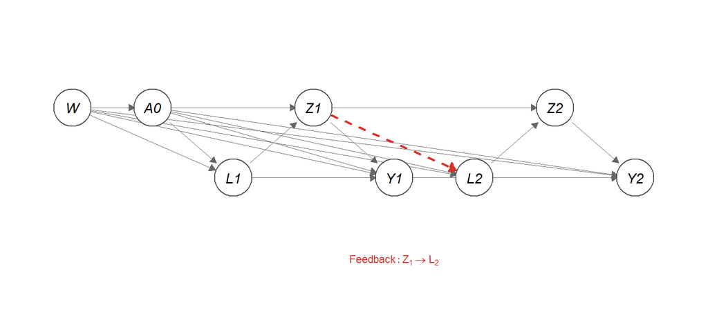

Figure 1: Longitudinal DAG for the oral-ART forgiveness problem (2 blocks shown). The dashed red arrow highlights the treatment-confounder feedback: adherence $Z_1$ affects health $L_2$, which in turn confounds the $Z_2 \to Y_2$ relationship.

### Formal structural equations

The structural causal model (SCM) formalises this causal process as a system of equations. Each variable is written as a deterministic function of its causal parents plus an unobserved error term $U$:

$$\begin{align}
W &= f_W(U_W) \\
A_0 &= f_{A_0}(W, U_{A_0}) \\
L_t &= f_{L_t}(L_{t-1}, Z_{t-1}, A_0, U_{L_t}) & \text{for } t = 1, \ldots, K \\
Z_t &= f_{Z_t}(L_t, Z_{t-1}, W, U_{Z_t}) & \text{for } t = 1, \ldots, K \\
Y_t &= f_{Y_t}(Z_t, L_t, A_0, W, Y_{t-1}, U_{Y_t}) & \text{for } t = 1, \ldots, K
\end{align}$$

The SCM encodes the same story as the DAG: $L_t$ depends on prior adherence $Z_{t-1}$ (adherence affects health) and $Z_t$ depends on current $L_t$ (health affects adherence). This treatment-confounder feedback is why standard regression fails. The functions $f$ are left unspecified, the SCM makes no parametric assumptions about functional forms, only about which variables cause which. The simulation DGP in Section 4 provides one concrete implementation of these structural equations.

## 2.5 Identification

To move from the causal estimand (what *would* happen under a hypothetical adherence pattern) to a quantity we can estimate from observed data, we need three assumptions. In plain language: (1) the outcome we observe for a patient who happens to follow a given adherence pattern is the same outcome they *would have* had if we had assigned that pattern (Consistency); (2) at each time point, we have measured enough of the patient’s clinical history that, conditional on those measurements, adherence is unrelated to unmeasured risk factors (Sequential exchangeability); and (3) every adherence level we want to evaluate is actually observed with positive probability in the data (positivity — meaning the data contain sufficient patients with each adherence pattern to estimate those counterfactual risks reliably). See Section 13.2 for a formal treatment of these three assumptions.

## 2.6 From causal estimand to statistical target parameter

The observed data for each patient, $O_i = (W_i, A_{0,i}, \bar{L}_i, \bar{Z}_i, \bar{Y}_i)$, are drawn independently from an unknown distribution $P_0$. The scientific question, how does virologic failure risk change across adherence levels for each regimen?, is encoded by the causal estimand $\psi(a_0, z) = E[Y_K^{a_0, \bar{z}}]$. This quantity is defined through the SCM and refers to a counterfactual world; it is not directly a function of $P_0$.

Under the identification assumptions (consistency, sequential exchangeability, and positivity), the causal estimand equals a statistical target parameter, a functional of the observed-data distribution:

$$\Psi_{a_0,z}(P_0) = \sum_{\bar{l}} \prod_{t=1}^{K} P_0(Y_t = 0 \mid \bar{z}_t, \bar{l}_t, a_0, w) \cdot P_0(l_t \mid \bar{z}_{t-1}, \bar{l}_{t-1}, a_0, w)$$

This is the g-computation functional: a mapping from $P_0$ to a real number, expressed entirely in terms of conditional distributions that can be estimated from data. Once identification holds, the problem becomes purely statistical: we need to estimate $\Psi(P_0)$, not the counterfactual directly.

Longitudinal Targeted Maximum Likelihood Estimation (implemented in either the `ltmle` or `lmtp` package) is a targeted estimator of $\Psi(P_0)$. It constructs an estimate $\hat{P}_n$ of the relevant parts of $P_0$ (outcome regressions and treatment/adherence mechanisms) through a sequence of models over time, and then evaluates the functional $\Psi(\hat{P}_n)$. The “targeting” step updates the initial estimate to reduce bias for $\Psi$ specifically, rather than for the full distribution $P_0$. It is doubly robust: $\Psi(\hat{P}_n)$ is consistent for $\Psi(P_0)$ if either the outcome model or the treatment model is correctly specified (Bang and Robins 2005; Laan and Gruber 2012; Díaz et al. 2023). Influence-curve-based standard errors and confidence intervals follow from the efficient influence function of $\Psi$ at $P_0$.

# 3 Why Single-time Point Adherence-Stratified Analyses Fail

Before implementing causal methods, it is instructive to understand why the standard epidemiologic approach — stratifying or adjusting for observed adherence — produces biased estimates of the forgiveness curve. The core issue is that adherence is time-varying, clinical status influences future adherence, and clinical status also predicts future virologic outcomes. This creates a feedback structure that standard regression cannot handle correctly, and it is the primary motivation for using g-methods (marginal structural models, g-computation, TMLE, or LMTP) in adherence analyses.

## 3.1 The treatment-confounder feedback loop

Naive adherence-stratified analyses fail because adherence and clinical status evolve jointly over time through a feedback process. First, worsening clinical status — such as rising viral load or treatment side effects — can reduce a patient’s ability to maintain adherence. Second, reduced adherence leads to poorer virologic control and further deterioration in clinical status. Third, this updated clinical status continues to influence subsequent adherence behavior. As a result, observed adherence at any time point reflects both prior adherence and prior health. Conditioning on observed adherence therefore induces selection bias, because adherence acts as a post-treatment variable affected by prior outcomes.

Observed adherence strata reflect realized behavior under evolving clinical conditions, whereas the target estimand concerns counterfactual outcomes under intervention-defined adherence patterns.

The fundamental problem is that adherence after baseline is a post-treatment variable: it is influenced by prior health status, prior adherence, and the treatment itself. Those same prior factors also affect future virologic outcomes. For concrete example, consider that a patient who develops nausea or early virologic rebound may miss doses during the next 90-day period. If we then compare high-adherence and low-adherence periods without properly accounting for this evolving clinical history, we risk attributing to adherence differences that are partly due to worsening health status.

Comparing patients who happened to achieve high versus low adherence therefore does not recover the causal forgiveness curve, because the comparison is confounded by the clinical trajectory that led to each adherence pattern. This is the same logic that makes per-protocol analyses in randomised trials vulnerable to bias when protocol deviations are informative. More specifically, standard regression can be biased because some clinical variables both affect future adherence and predict future virologic outcomes. For example, a patient with rising viral load, side effects, depression, or worsening comorbidity burden may become less adherent in the next interval, and those same factors also increase the risk of future virologic failure. Because these variables change over time and may themselves be affected by prior adherence, they are time-dependent confounders.

In the structural model above, health status $L_t$ is simultaneously:

1. A confounder of the $Z_t \to Y_t$ relationship (healthier patients have lower failure risk regardless of adherence), and
2. A consequence of prior adherence $Z_{t-1}$ (better adherence improves health via viral suppression).

This creates a feedback loop: $Z_{t-1} \to L_t \to Z_t \to Y_t$. Standard regression conditions on $L_t$ to adjust for confounding, but this also blocks the causal pathway from $Z_{t-1}$ through $L_t$ to $Y_t$. Conversely, not conditioning on $L_t$ leaves the confounder uncontrolled. Simply including time-varying clinical status in a standard outcome regression is not sufficient when those covariates are themselves affected by prior adherence. Neither approach identifies the causal effect of adherence (Hernán and Robins 2020, Ch. 21). This is the central reason that longitudinal causal methods such as marginal structural models and targeted learning approaches are needed: they are designed for settings in which adherence changes over time and is entangled with evolving patient status.

## 3.2 The direction of bias

The bias from naive adherence-stratified analysis has a predictable direction:

- **High-adherence stratum**: Enriched for healthier patients (good health enables adherence). The observed risk is *lower* than the causal risk because the stratum selects for patients who would have had low failure risk regardless of adherence.
- **Low-adherence stratum**: Enriched for sicker patients (illness disrupts adherence). The observed risk is *higher* than the causal risk because the stratum selects for patients with inherently worse prognosis.

The net effect is that naive stratification **overestimates** the risk difference between high and low adherence, it makes adherence appear *more* important than it causally is. For forgiveness curves, this means the naive approach overestimates the slope (making both drugs appear less forgiving) and can distort the *relative* forgiveness of Drug A versus Drug B.

## 3.3 What g-methods do differently

The estimators in this tutorial are longitudinal extensions of propensity-score-based confounding adjustment, adapted to settings where both adherence and confounders evolve over time.

The three main estimation strategies can be understood in practical terms before turning to technical details:

- **G-computation** estimates the virologic outcome each patient would be expected to have under a specified adherence pattern, then averages those predicted outcomes across the study population (g-computation is consistent under a correctly specified outcome model but is not doubly robust, it does not provide the second chance of consistency that LTMLE and LMTP offer through their treatment model).
- **Inverse probability weighting (IPW)** assigns larger weights to patients whose observed adherence pattern was less likely given their measured clinical history, and smaller weights to patients whose adherence was more expected. The weighted data approximate a study in which adherence was less confounded by measured covariates.
- **Doubly robust approaches**, like longitudinal targeted maximum likelihood estimation, combine an outcome model with a treatment model so that estimation remains consistent if either model is correctly specified, and inference is better aligned with the causal estimand than either approach alone.

Specifically, the ltmle R package uses sequential regression to predict outcomes at each time point, then updates those predictions using the estimated adherence probabilities in a step called “targeting.” This targeting step directly optimises the estimate for the causal quantity of interest, reducing bias while preserving valid standard errors (Lendle et al. 2017). The LMTP (longitudinal modified treatment policy) package uses density-ratio weighting that compares the probability of the shifted adherence to the observed adherence, sidestepping the need to enumerate all confounder levels. This is particularly useful when adherence is continuous or has many levels (Díaz et al. 2023; Williams and Díaz 2023). Both methods respect the time-ordering of the data and handle the treatment-confounder feedback correctly.

# 4 Simulated Oral-ART Cohort

## 4.1 Data-generating process

We simulate a cohort of 20,000 patients randomised 1:1 to Drug A (more forgiving, e.g., an INSTI-based regimen) or Drug B (less forgiving, e.g., a PI-based regimen), followed over $K = 4$ blocks of 90 days (~1 year). Drug assignment is randomised, which isolates longitudinal confounding from baseline selection confounding and ensures the observed drug comparison is unconfounded at baseline. The primary simulation assumes complete outcome ascertainment: every patient’s virologic failure status is observed at each block. Real applications require handling informative viral-load monitoring (i.e., patients are tested more often when clinicians suspect non-adherence), and an extension discussing this complication is provided in Section 13.10.2.

In real-world HIV studies, adherence is often approximated using pharmacy refill data, such as proportion of days covered (PDC), over clinically meaningful intervals of 30, 60, or 90 days. This is a practical proxy for medication availability, although it does not guarantee actual ingestion of the medication. For long-acting injectable regimens, adherence is instead reflected in the timing and regularity of clinic visits for scheduled injections, with missed or delayed visits leading to gaps in pharmacologic coverage. Viral load is monitored intermittently, often every few months in stable patients, more frequently when adherence or treatment response is uncertain, so observational data do not directly reveal the exact timing of virologic rebound after missed doses. Our simulation abstracts these features into discrete 90-day blocks with categorical adherence and binary failure outcomes, but the causal structure is intended to mirror the real-world data-generating process.

Baseline covariates include age in years (generated as mean 0, SD 1 on a standardized scale; the underlying raw-scale distribution approximates mean ~45 years, SD ~12), disease severity (low CD4, 30% prevalence), depression (25%), and prior treatment instability (20%). The time-varying health confounder $L_t$ is continuous on approximately a standard normal scale, with AR(1) persistence of 0.50. The forgiveness mechanism is encoded via interaction terms in the failure hazard: both drugs have the same baseline failure probability at high adherence ($Z = 3$), and Drug B incurs larger penalties for low ($Z = 1$) and moderate ($Z = 2$) adherence, while Drug A has smaller penalties (`Y_beta_forgive_low = -0.38` and `Y_beta_forgive_med = -0.20`), meaning it “forgives” missed doses more. In addition, Drug B causes modestly worse adherence due to more frequent side effects (`Z_beta_A0 = 0.40`), creating a drug $\to$ adherence pathway: Drug A patients are more likely to maintain medium or high adherence, while Drug B patients drift toward lower adherence categories. This means the total risk difference between drugs reflects both the pharmacologic forgiveness mechanism (Drug B penalises missed doses more) and an adherence-mediated pathway (Drug B’s side effects cause more missed doses).

The DGP uses moderate treatment-confounder feedback (`L_beta_Z = 0.30`, `Z_beta_L = 0.80`, `Y_beta_L = -0.80`): better adherence moderately improves health ($\beta_{L \leftarrow Z} = 0.30$), better health strongly drives higher adherence ($\beta_{Z \leftarrow L} = 0.80$), and better health substantially reduces failure risk ($\beta_{Y \leftarrow L} = -0.80$, corresponding to an OR of approximately 2.2 per standard deviation of $L_t$). The $L_t$ AR(1) process driven by past $Z$ values means that adherence history is implicitly captured through $L_t$; removing the explicit $\bar{Z}$ term ($\beta_{Y \leftarrow \bar{Z}} = 0$) reflects that history is encoded through $L_t$ rather than a separate running mean. This feedback structure produces visible bias in naive adherence-stratified analyses, illustrating the “healthy adherer” effect, while remaining within a clinically plausible parameter range.

**Calibration note.** The DGP was tuned to be more consistent with contemporary HIV care, with high-adherence failure rates in a plausible clinical range. Under forced high adherence ($Z = 3$), cumulative 48-week failure risks are approximately 5% for Drug A and 6% for Drug B. Under forced low adherence ($Z = 1$), risks rise to approximately 18% (Drug A) and 29% (Drug B). The low-adherence contrast remains somewhat amplified compared to modern INSTI-versus-comparator settings to preserve visible methodological signal; this stylization is intentional and is not a claim about any specific product pair. This DGP was not formally calibrated to empirical data from a specific trial or cohort.

**Teaching code: oracle truth via Monte Carlo**

```r
# ── Oracle counterfactual risks ───────────────────────────────────────────
# Because we control the DGP, we can compute the TRUE risk under each
# (drug, adherence) regime by simulating a large population (n = 100,000)
# with adherence forced to a constant level at every time point.
# This serves as the ground truth against which estimators are evaluated.

library(simhelpers)  # or source("R/sim_oral_forgiveness_helpers.R")

oracle_regimes <- list(
  DrugA_z1    = list(a0 = 1, z_level = 1L),    # Drug A, low adherence
  DrugA_z2    = list(a0 = 1, z_level = 2L),    # Drug A, medium adherence
  DrugA_z3    = list(a0 = 1, z_level = 3L),    # Drug A, high adherence
  DrugB_z1    = list(a0 = 0, z_level = 1L),    # Drug B, low adherence
  DrugB_z2    = list(a0 = 0, z_level = 2L),    # Drug B, medium adherence
  DrugB_z3    = list(a0 = 0, z_level = 3L),    # Drug B, high adherence
  DrugA_shift = list(a0 = 1, z_level = "shift"), # Drug A, shift policy
  DrugB_shift = list(a0 = 0, z_level = "shift")  # Drug B, shift policy
)

oracle_truth <- oracle_oral_forgiveness(
  regimes  = oracle_regimes,
  K        = 4,             # number of time blocks
  n_oracle = 100000,        # large MC sample for precise estimates
  seed     = 99999,
  params   = dgp_params     # same DGP parameters as the tutorial
)
# Returns data.frame with columns: regime, a0, z_target, cum_risk_oracle
print(oracle_truth)
```

The simulated cohort of 20,000 patients is randomised 1:1 to Drug A (more forgiving) or Drug B (less forgiving), followed over $K = 4$ blocks of 90 days (~1 year). Baseline covariates include age (standardized, mean 0 SD 1), disease severity, depression, and prior treatment instability. At each block, time-varying health status $L_t$ (continuous) depends on prior adherence $Z_{t-1}$ (with AR(1) persistence), and categorical adherence $Z_t \in \{1, 2, 3\}$ (low, medium, high) depends strongly on current health $L_t$ ($\beta_{Z \leftarrow L} = 0.80$), creating treatment-confounder feedback that biases naive analyses. The key feature of this DGP that makes naive bias difficult to remove is that $L_t$ is continuous and strongly predicts failure ($\beta_{Y \leftarrow L} = -0.80$): conditioning on the coarser $Z_t$ alone leaves substantial residual variation in $L_t$ within each adherence stratum. Adherence history is captured implicitly through the $L_t$ AR(1) process; the explicit $\bar{Z}$ term is set to zero ($\beta_{Y \leftarrow \bar{Z}} = 0$), meaning history flows through $L_t$ rather than a separate running mean. LTMLE accounts for this by sequentially adjusting for $L_t$ at each time point, propagating the full clinical trajectory through the g-computation.

The forgiveness mechanism is encoded as a drug-by-adherence interaction in the failure hazard: Drug A has smaller risk penalties at low and medium adherence than Drug B. Oracle counterfactual risks (computed from 1e+05 MC draws) confirm that both drugs perform similarly at high adherence but diverge sharply as adherence declines, with Drug B’s risk rising much more steeply. Full DGP parameters (Table 21), baseline characteristics (Table 22), adherence distributions (Figure 15), cumulative incidence (Figure 16), and oracle counterfactual risks (Table 23) are in Section 13.3.

Before estimating risks under forced adherence regimes, the three identification assumptions formalised in Section 13.2 must hold, but the one most tied to the observed data is practical positivity. Every adherence level must have positive probability given the measured covariates at each time point. For static adherence interventions, positivity becomes increasingly challenging as the number of time points $K$ grows. Even if the marginal probability of adhering at level $z$ at any single block is reasonable (say 25%), the probability of maintaining that level across all $K = 4$ blocks decays as roughly $0.25^4 \approx 0.4\%$. This multiplicative erosion of support is the fundamental reason that static adherence regimes become fragile over extended follow-up, and it motivates the complementary LMTP shift-policy approach in Section 6. For a full discussion including adherence path-support tables, the consequences of weak support for estimator stability, practical guidance on when to shift from static regimes to feasible policies, and quantitative ESS and weight diagnostics, see Section 13.4 and Section 13.6.

# 5 Longitudinal TMLE Analysis of treatment contrasts under static adherence

We now estimate the primary forgiveness-curve estimand, the regimen-specific counterfactual risk under static adherence regimes, using longitudinal targeted minimum loss-based estimation (LTMLE). The idea is straightforward: fit a sequence of outcome models that predict virologic failure at each time block given the patient’s prior adherence and clinical history, then adjust those predictions using estimated adherence probabilities (the “targeting” step) to reduce bias and align inference with the causal estimand. The result is doubly robust: the estimate is consistent if either the outcome model or the adherence model is correctly specified (Laan and Gruber 2012; Lendle et al. 2017).

## 5.1 Encoding adherence for `ltmle`

The `ltmle` R package (Lendle et al. 2017) requires binary treatment nodes. We encode categorical adherence ($Z_t \in \{1,2,3\}$) as two binary dummies per block:

- $Z_{\text{med},t} = \mathbb{1}(Z_t \geq 2)$, medium adherence
- $Z_{\text{high},t} = \mathbb{1}(Z_t \geq 3)$, high adherence

In addition, drug assignment $A_0$ is included as a treatment node $A_{\text{trt},t}$ at each block (constant across time, equal to $A_0$). This creates $3 \times K = 12$ treatment nodes total, with a deterministic constraint that $A_{\text{trt},t} = A_{\text{trt},1}$ for $t > 1$.

### 5.1.1 Node ordering per block

The column ordering in the `ltmle` data frame determines the causal ordering:

$$L_t \to A_{\text{trt},t} \to Z_{\text{med},t} \to Z_{\text{high},t} \to Y_t$$

Health status $L_t$ precedes all treatment nodes within each block, as required by the causal structure. Drug assignment $A_{\text{trt},t}$ (constant, deterministic given $A_{\text{trt},1}$) precedes the adherence dummies.

## 5.2 LTMLE results

```r
if (!is.null(ltmle_results) && !is.null(oracle_truth)) {
  lr <- ltmle_results
  lr$arm <- ifelse(lr$a0 == 1, "Drug A", "Drug B")
  lr$adherence <- c("Low", "Medium", "High")[lr$z_level]
  lr$oracle <- sapply(seq_len(nrow(lr)), function(i) {
    ot_row <- oracle_truth[oracle_truth$a0 == lr$a0[i] &
                            oracle_truth$z_target == as.character(lr$z_level[i]), ]
    if (nrow(ot_row) > 0) ot_row$cum_risk_oracle[1] else NA_real_
  })

  print(kable(lr[, c("arm", "adherence", "estimate", "se", "CI_lower", "CI_upper", "oracle")],
        digits = 4,
        col.names = c("Arm", "Adherence", "LTMLE Risk", "SE", "95% CI Lower",
                       "95% CI Upper", "Oracle"),
        align = "llrrrrr") |>
    kable_styling(bootstrap_options = c("striped", "condensed"), full_width = FALSE))
} else {
  no_results_msg("LTMLE regime estimates")
}
```

Table 2: LTMLE estimates of regime-specific risks compared with oracle truth.

|  | Arm | Adherence | LTMLE Risk | SE | 95% CI Lower | 95% CI Upper | Oracle |
| --- | --- | --- | --- | --- | --- | --- | --- |
| DrugB_z1 | Drug B | Low | 0.3352 | 0.0265 | 0.2833 | 0.3870 | 0.2940 |
| DrugA_z1 | Drug A | Low | 0.1513 | 0.0294 | 0.0936 | 0.2090 | 0.1799 |
| DrugB_z2 | Drug B | Medium | 0.1639 | 0.0242 | 0.1165 | 0.2112 | 0.1385 |
| DrugA_z2 | Drug A | Medium | 0.1034 | 0.0174 | 0.0692 | 0.1375 | 0.0938 |
| DrugB_z3 | Drug B | High | 0.0912 | 0.0247 | 0.0427 | 0.1397 | 0.0646 |
| DrugA_z3 | Drug A | High | 0.0535 | 0.0103 | 0.0332 | 0.0738 | 0.0527 |

**LTMLE implementation code**

```r
library(ltmle)
source("R/sim_oral_forgiveness_helpers.R")

# Step 1: Simulate data
dat <- simulate_oral_forgiveness(n = 20000, K = 4, seed = 12345)

# Step 2: Prepare data for ltmle (joint drug + adherence treatment nodes)
# This creates a wide data frame with columns ordered as:
#   W_age, W_sev, W_dep, W_instab,
#   L_1, A_trt_1, Z_med_1, Z_high_1, Y_1,
#   L_2, A_trt_2, Z_med_2, Z_high_2, Y_2, ...
prep <- prep_ltmle_oral(dat, K = 4)

# Step 3: Define abar vectors for BOTH regimes at a given adherence level
# We pass abar as a list to get the within-call Drug A vs Drug B contrast
# with IC-based standard errors for the risk difference and risk ratio.
abar_drugA_high <- make_abar_oral(a0 = 1, z_level = 3, K = 4)
abar_drugB_high <- make_abar_oral(a0 = 0, z_level = 3, K = 4)

# Step 4: Fit ltmle with BOTH regimes in one call
# Using abar = list(treatment, control) gives IC-based RD and RR
# The deterministic g-function encodes two constraints:
#   1. A_trt_t = A_trt_1 for t > 1 (drug doesn't change)
#   2. Z_high_t = 0 whenever Z_med_t = 0 (structural impossibility)
fit <- ltmle::ltmle(
  data   = prep$dat_wide,
  Anodes = prep$Anodes,   # A_trt_1, Z_med_1, Z_high_1, ..., A_trt_K, Z_med_K, Z_high_K
  Lnodes = prep$Lnodes,   # W_age, W_sev, W_dep, W_instab, L_1, ..., L_K
  Ynodes = prep$Ynodes,   # Y_1, ..., Y_K
  survivalOutcome = TRUE,  # Y is absorbing; returns RISK (not survival)
  abar   = list(treatment = abar_drugA_high, control = abar_drugB_high),
  SL.library = "SL.glm",
  gbounds = c(0.005, 1),
  estimate.time = FALSE,
  deterministic.g.function = det_g_oral
)

# Step 5: Extract contrast estimates from summary
s  <- summary(fit)
em <- s$effect.measures

# Individual regime risks
risk_A <- em$treatment$estimate  # P(failure | Drug A, high adherence)
risk_B <- em$control$estimate    # P(failure | Drug B, high adherence)

# IC-based risk difference (treatment - control) and risk ratio
RD    <- em$ATE$estimate        # Drug A risk - Drug B risk
se_RD <- em$ATE$std.dev
RR    <- em$RR$estimate         # Drug A risk / Drug B risk

# Step 6: Run all 3 contrasts (one per adherence level)
# estimate_ltmle() makes 3 ltmle calls, each contrasting Drug A vs B
all_results <- estimate_ltmle(dat, K = 4, sl_lib = "SL.glm")
# Returns: list($risks = regime-specific estimates, $contrasts = RD/RR per z)
```

## 5.3 LTMLE treatment contrasts

Each LTMLE call estimates the Drug A risk and Drug B risk simultaneously at a given adherence level, then computes the risk difference (RD = Drug A risk − Drug B risk) and risk ratio (RR = Drug A risk / Drug B risk) with influence-curve-based standard errors. This within-call approach produces properly calibrated inference for the contrast, avoiding the instability that can arise from dividing two separately estimated quantities.

Table 3: LTMLE treatment contrasts (Drug A vs Drug B) with IC-based inference, compared with oracle truth.

| Adherence | RD | SE(RD) | Oracle RD | RR | Oracle RR |
| --- | --- | --- | --- | --- | --- |
| Low | -0.1839 | 0.0396 | -0.1142 | 0.4513 | 0.6117 |
| Medium | -0.0605 | 0.0296 | -0.0447 | 0.6308 | 0.6773 |
| High | -0.0377 | 0.0268 | -0.0118 | 0.5869 | 0.8168 |

### A note on finite-sample variability

Constant-adherence regimes (e.g., all-low or all-high across four blocks) have weak support: few patients naturally follow the same adherence level at every visit. As a result, the estimated treatment weights can become extreme, increasing reliance on the outcome model and leading to higher variance. With $K = 4$ and 12 treatment nodes, regime-specific estimates can be unstable in a single estimate.

The LTMLE estimates in these tables come from one illustrative sample; visible discrepancies from oracle truth in a single realization do not contradict good average Monte Carlo performance (Section 9.7), and are especially expected for weakly supported static adherence paths.

Static adherence regimes, in which adherence is fixed at a specified level over time, define a clear causal estimand but may not correspond to feasible real-world interventions. In practice, adherence cannot be deterministically set to a fixed level for all individuals without specifying the underlying mechanism by which that level is achieved. Modified treatment policies (LMTPs) address this limitation by defining interventions that shift adherence relative to its observed value, thereby remaining within the support of the data. Importantly, this distinction is not only computational but conceptual: static regimes and LMTPs generally target different causal estimands. Static regimes represent idealized intervention targets, whereas LMTPs represent feasible policy-relevant interventions that can be more reliably estimated from observational data.

# 6 Modified treatment policies via LMTP

The LTMLE analysis above estimated the forgiveness curve under static adherence regimes. This section introduces an alternative approach using the `lmtp` package based on longitudinal modified treatment policies (LMTP). The LMTP framework can recover the same static estimand as a robustness check, but its primary advantage is that it enables estimation of more realistic causal effects that are less sensitive to positivity violations.

Rather than asking what would happen if everyone followed the same fixed adherence level, LMTP asks what would happen under realistic shifts from each person’s observed adherence trajectory. A useful way to interpret modified treatment policies is through concrete adherence shifts. For example, rather than defining an intervention that sets all individuals to a fixed adherence category of “high” — which may be unrealistic and unsupported by the data — an LMTP might instead shift each individual’s adherence upward by one category where possible: those already at high adherence remain unchanged, those at medium adherence shift to high, and those at low adherence shift to medium. Such interventions preserve the relative ordering of adherence observed in the data rather than replacing each individual’s adherence trajectory entirely. By operating within the observed support of adherence behavior, LMTPs avoid the extreme extrapolation required by static regimes and yield more stable and interpretable estimates.

More generally, three classes of interventions can be considered in this setting:

1. Dynamic regimes assign treatment deterministically based on patient history (e.g., “patients with PDC < 80% receive adherence support”).
2. Stochastic regimes assign treatment probabilistically (e.g., “patients receive adherence support with 50% probability at each visit”).
3. Modified treatment policies (MTPs) modify each patient’s observed treatment (e.g., “increase each patient’s adherence if feasible”).

Dynamic and stochastic regimes fully replace the observed treatment process. In contrast, modified treatment policies perturb the treatment that actually occurred. In the adherence setting, this distinction has practical implications. Because adherence cannot be directly assigned, dynamic and stochastic regimes implicitly assume control over patient behavior at each time point. This creates interpretability challenges and can exacerbate positivity issues, as the resulting treatment patterns are often sparsely represented in the data. Modified treatment policies avoid this issue by defining interventions locally around the observed data. Rather than specifying an entirely new treatment process, they ask how outcomes would change under incremental improvements to what patients actually did.

## 6.1 From static regimes to modified treatment policies

The static-intervention estimand $\psi(a_0, z)$ defines the forgiveness curve, but it corresponds to an intervention with no clear real-world analogue: setting every patient’s adherence to exactly level $z$ at every time point. In practice, adherence is shaped by tolerability, patient circumstances, and clinical status, and cannot be deterministically maintained over time.

This leads to two limitations. First, limited support: only a small fraction of patients follow any fixed adherence trajectory across all $K$ blocks, so estimation under static regimes relies on extrapolation beyond the observed data. Second, limited policy relevance: clinical decisions typically aim to improve adherence (e.g., counseling or reminders), rather than enforce a fixed level for all patients.

Modified treatment policies address both issues by defining interventions relative to each patient’s observed adherence (Díaz, Williams, et al. 2021, 2023). The shift policy used in this tutorial is:

$$d(Z_t) = \min(Z_t + 1, 3)$$

This intervention increases adherence by one category (low $\to$ medium, medium $\to$ high, high $\to$ high), with a cap at the maximum. It represents a plausible intervention, such as the average effect of an adherence support program. Because the intervention makes only local changes to observed adherence, it requires substantially weaker support in the data.

The corresponding estimand is:

$$\psi^d = E\!\left[Y_K^{d(\bar{Z})}\right]$$

This parameter asks: “what would the risk of virologic failure be if each patient’s adherence were incrementally improved at each visit?” It targets a feasible intervention and yields stable estimates even when constant adherence trajectories are rare.

## 6.2 LMTP results

We include `A0` (drug assignment) as the first treatment node alongside `Z_0, Z_1, \ldots, Z_K`, fitting on the full dataset. The shift function forces `A0` to the target drug value while shifting each `Z_t` up by one category.

```r
lmtp_out <- load_cached("lmtp_v13", quote(
  suppressMessages(suppressWarnings(
    estimate_lmtp(dat, K = K, folds = 1L, sl_lib = "SL.glm")
  ))
))
# estimate_lmtp() returns list($risks, $contrast)
lmtp_results <- if (!is.null(lmtp_out)) lmtp_out$risks else NULL
lmtp_shift_contrast <- if (!is.null(lmtp_out)) lmtp_out$contrast else NULL
```

```r
if (!is.null(lmtp_results) && !is.null(oracle_truth)) {
  lr <- lmtp_results
  lr$arm <- ifelse(lr$a0 == 1, "Drug A", "Drug B")
  lr$oracle <- sapply(lr$a0, function(a) {
    oracle_truth$cum_risk_oracle[oracle_truth$a0 == a &
                                  oracle_truth$z_target == "shift"]
  })
  print(kable(lr[, c("arm", "estimate", "se", "CI_lower", "CI_upper", "oracle")],
        digits = 4,
        col.names = c("Arm", "LMTP Risk", "SE", "95% CI Lower",
                       "95% CI Upper", "Oracle"),
        align = "lrrrrr") |>
    kable_styling(bootstrap_options = c("striped", "condensed"), full_width = FALSE))

  # Show the shift contrast (RD and RR)
  if (!is.null(lmtp_shift_contrast)) {
    cat("\n\n**Shift contrast (Drug A vs Drug B):**",
        sprintf("RD = %.4f (SE = %.4f), RR = %.4f",
                lmtp_shift_contrast$RD, lmtp_shift_contrast$se_RD,
                lmtp_shift_contrast$RR), "\n")
  }
} else {
  no_results_msg("LMTP shift estimates")
}
```

Table 4: **Shift contrast (Drug A vs Drug B):** RD = -0.0300 (SE = 0.0159), RR = 0.6918

|  | Arm | LMTP Risk | SE | 95% CI Lower | 95% CI Upper | Oracle |
| --- | --- | --- | --- | --- | --- | --- |
| DrugB_shift | Drug B | 0.0972 | 0.0142 | 0.0693 | 0.1251 | 0.0923 |
| DrugA_shift | Drug A | 0.0673 | 0.0070 | 0.0536 | 0.0809 | 0.0632 |

## 6.3 LMTP-static: density-ratio route to the static-regime estimand

LMTP can also target the same static-regime estimand as LTMLE by using a *static* shift function that forces each $Z_t$ to a constant value rather than shifting it by one category. This provides a density-ratio-based route to the same causal contrast as LTMLE, using different working models (density ratios rather than sequential regression). If both estimators target the same parameter and produce similar answers, this strengthens confidence in the result; if they diverge, the discrepancy signals sensitivity to modelling assumptions or positivity issues. The LMTP-shift estimator, by contrast, targets a different and complementary feasible-policy estimand. LMTP does not merely provide a numerically more stable estimator of the same target; it changes the intervention and therefore targets a different causal quantity that remains closer to observed adherence behavior. Note that `mtp = FALSE` is used for LMTP-static because the intervention sets adherence to a fixed value rather than modifying the observed value.

Implementation details for the LMTP shift and static analyses are in the code blocks below (click to expand).

**LMTP-shift implementation code**

```r
library(lmtp)
source("R/sim_oral_forgiveness_helpers.R")

dat <- simulate_oral_forgiveness(n = 20000, K = 4, seed = 12345)

# ── Data preparation with A0 as first treatment node ──────────────────
# A0 (drug assignment) is included as the first treatment node alongside
# Z_0, Z_1, ..., Z_K. This enables lmtp_contrast() to produce proper
# IC-based inference for the Drug A vs Drug B contrast on the full data.
# Y_neg1 is a placeholder outcome (always 0) so trt and outcome lengths match.
prep <- prep_lmtp_oral(dat, K = 4)

# ── Define the joint shift function ──────────────────────────────────
# lmtp requires: function(data, trt) -> named list of shifted values
# For Drug A (a0=1): force A0=1, shift Z_t to min(Z_t + 1, 3)
shift_fn_drugA <- make_joint_shift(a0_val = 1)
shift_fn_drugB <- make_joint_shift(a0_val = 0)
# The shift function handles each trt node:
#   A0:   forced to a0_val (drug assignment)
#   Z_0:  kept unchanged (placeholder)
#   Z_t:  shifted to min(Z_t + 1, 3)

# ── Fit LMTP for each drug on the FULL dataset ──────────────────────
fit_A <- lmtp::lmtp_tmle(
  data     = prep$data,
  trt      = prep$trt_nodes,        # c("A0", "Z_0", "Z_1", ..., "Z_4")
  outcome  = prep$outcome_nodes,    # c("Y_neg1", "Y_0", "Y_1", ..., "Y_4")
  baseline = prep$baseline,         # c("W_age", "W_sev", "W_dep", "W_instab")
  time_vary = prep$time_vary,       # list(NULL, NULL, "L_1", ..., "L_4")
  shift    = shift_fn_drugA,
  mtp      = TRUE,                  # TRUE for modified treatment policies
  outcome_type = "survival",
  folds    = 5L,
  learners_trt = "SL.glm",
  learners_outcome = "SL.glm"
)
fit_B <- lmtp::lmtp_tmle(
  data = prep$data, trt = prep$trt_nodes, outcome = prep$outcome_nodes,
  baseline = prep$baseline, time_vary = prep$time_vary,
  shift = shift_fn_drugB, mtp = TRUE, outcome_type = "survival",
  folds = 5L, learners_trt = "SL.glm", learners_outcome = "SL.glm"
)

# ── IC-based contrast: Drug A vs Drug B ──────────────────────────────
# lmtp_contrast() computes the difference on the SURVIVAL scale;
# for risk, negate the additive contrast: RD(risk) = -(surv_A - surv_B)
rd_contrast <- lmtp::lmtp_contrast(fit_A, ref = fit_B, type = "additive")
rd_tidy <- generics::tidy(rd_contrast)
RD <- -rd_tidy$estimate          # risk difference (Drug A - Drug B)
se_RD <- rd_tidy$std.error       # IC-based SE

# ── Wrapper: run Drug A vs B shift contrast in one call ──────────────
all_lmtp <- estimate_lmtp(dat, K = 4, folds = 5L, sl_lib = "SL.glm")
# Returns: list($risks = per-arm risk estimates, $contrast = RD and RR)
```

**LMTP-static implementation code**

```r
library(lmtp)
source("R/sim_oral_forgiveness_helpers.R")

dat <- simulate_oral_forgiveness(n = 20000, K = 4, seed = 12345)

# ── Data preparation (same as for LMTP-shift) ────────────────────────
prep <- prep_lmtp_oral(dat, K = 4)

# ── Define a STATIC shift function ───────────────────────────────────
# Unlike the shift policy, the static function forces Z_t to a constant
# value (e.g., z = 3 for high adherence) at every time point.
# mtp = FALSE because this is a deterministic static intervention.
static_fn_drugA_high <- make_joint_static(a0_val = 1, z_val = 3)
static_fn_drugB_high <- make_joint_static(a0_val = 0, z_val = 3)
# The function handles each trt node:
#   A0:   forced to a0_val
#   Z_0:  kept unchanged (placeholder)
#   Z_t:  forced to z_val (e.g., 3 = high)

# ── Fit LMTP-static for each drug on the FULL dataset ────────────────
# Note: mtp = FALSE for static interventions
fit_A_static <- lmtp::lmtp_tmle(
  data     = prep$data,
  trt      = prep$trt_nodes,
  outcome  = prep$outcome_nodes,
  baseline = prep$baseline,
  time_vary = prep$time_vary,
  shift    = static_fn_drugA_high,
  mtp      = FALSE,                  # FALSE for static (deterministic) policy
  outcome_type = "survival",
  folds    = 5L,
  learners_trt = "SL.glm",
  learners_outcome = "SL.glm"
)
fit_B_static <- lmtp::lmtp_tmle(
  data = prep$data, trt = prep$trt_nodes, outcome = prep$outcome_nodes,
  baseline = prep$baseline, time_vary = prep$time_vary,
  shift = static_fn_drugB_high, mtp = FALSE, outcome_type = "survival",
  folds = 5L, learners_trt = "SL.glm", learners_outcome = "SL.glm"
)

# ── IC-based contrast ────────────────────────────────────────────────
rd_contrast <- lmtp::lmtp_contrast(fit_A_static, ref = fit_B_static,
                                    type = "additive")
rd_tidy <- generics::tidy(rd_contrast)
RD <- -rd_tidy$estimate          # risk difference (Drug A - Drug B)
se_RD <- rd_tidy$std.error

# ── Wrapper: run all 3 adherence levels in one call ──────────────────
all_static <- estimate_lmtp_static(dat, K = 4, folds = 5L, sl_lib = "SL.glm")
# Returns: list($risks = 6 regime-specific estimates,
#               $contrasts = 3 Drug A vs B contrasts at z = 1, 2, 3)
```

## 6.4 Secondary treatment-comparison estimand

As a secondary analysis complementing the primary forgiveness-curve estimation, regimens may also be compared under a shared adherence distribution. One implemented approach maps both treatment arms to the observed adherence distribution of one reference regimen using an LMTP shift: baseline treatment assignment is jointly intervened upon alongside first-period adherence, and subsequent adherence values are shifted block-wise based on the observed between-regimen adherence gap, with resulting values bounded within feasible support. Because adherence is treated as continuous and the intervention modifies the natural value of each patient’s adherence trajectory, LMTP is the appropriate estimator. This contrast addresses a controlled-adherence question rather than a natural-course effectiveness comparison: it isolates differences in regimen-specific outcome risk apart from adherence differences attributable to each regimen’s side-effect profile or other adherence pathways. The reverse standardization — both arms mapped to the reference treatment’s adherence — provides a complementary perspective on the same question. Natural-course regimen comparisons, in which adherence and monitoring evolve as observed under each regimen, are conceptually distinct and are noted as an extension in Section 13.10.

## 6.5 Continuous adherence via proportion of days covered

The analyses above treated adherence as a three-level categorical variable. In practice, pharmacy refill data and electronic monitoring often yield a continuous measure: the proportion of days covered (PDC), defined as the fraction of days in each monitoring block during which the patient had medication available. Continuous PDC preserves more information than a categorised version and enables richer interventions, such as “increase every patient’s adherence by 10 percentage points” rather than “shift everyone up one category.”

LMTP handles continuous treatments natively. The shift function $d(Z_t) = \min(Z_t + \delta, 1)$ nudges each patient’s observed PDC upward by $\delta$, capping at 1.0 (perfect adherence). Because this is a modified treatment policy, it respects the natural bounds: a patient already at 95% PDC is shifted only to 100%, not beyond, avoiding positivity violations that would arise from a static intervention like “set PDC = 1.0 for everyone.”

### 6.5.1 Preparing LMTP data with continuous PDC

The data preparation follows the same structure as the categorical LMTP analysis, but with continuous `PDC_t` replacing categorical `Z_t` as the treatment node. The drug assignment `A0` remains the first treatment node so that contrasts between drugs use IC-based inference.

**Prepare LMTP data with continuous PDC**

```r
# ── Build wide dataset for lmtp with continuous PDC ───────────────────────
baseline_pdc <- c("W_age", "W_sev", "W_dep", "W_instab")

wide_pdc <- dat_pdc[, baseline_pdc, drop = FALSE]
wide_pdc$id <- seq_len(nrow(dat_pdc))
wide_pdc$A0 <- dat_pdc$A0
wide_pdc$PDC_0 <- round(runif(nrow(dat_pdc), 0.5, 0.9), 4)  # placeholder
wide_pdc$Y_neg1 <- 0L
wide_pdc$Y_0 <- 0L

trt_pdc     <- c("A0", "PDC_0")
outcome_pdc <- c("Y_neg1", "Y_0")
tv_pdc      <- list(NULL, NULL)

for (tt in seq_len(K)) {
  wide_pdc[[paste0("L_", tt)]]   <- dat_pdc[[paste0("L_", tt)]]
  wide_pdc[[paste0("PDC_", tt)]] <- dat_pdc[[paste0("PDC_", tt)]]
  wide_pdc[[paste0("Y_", tt)]]   <- dat_pdc[[paste0("Y_", tt)]]

  trt_pdc     <- c(trt_pdc, paste0("PDC_", tt))
  outcome_pdc <- c(outcome_pdc, paste0("Y_", tt))
  tv_pdc[[tt + 2]] <- paste0("L_", tt)
}

# LOCF and absorbing state
for (i in seq_len(nrow(wide_pdc))) {
  event_occurred <- FALSE
  last_L <- 0; last_PDC <- wide_pdc[i, "PDC_0"]
  for (tt in seq_len(K)) {
    ln <- paste0("L_", tt); pn <- paste0("PDC_", tt); yn <- paste0("Y_", tt)
    if (event_occurred) {
      wide_pdc[i, ln]  <- last_L
      wide_pdc[i, pn]  <- last_PDC
      wide_pdc[i, yn]  <- 1L
    } else {
      if (is.na(wide_pdc[i, ln]))  wide_pdc[i, ln]  <- last_L
      if (is.na(wide_pdc[i, pn]))  wide_pdc[i, pn]  <- last_PDC
      if (is.na(wide_pdc[i, yn]))  wide_pdc[i, yn]  <- 0L
      last_L <- wide_pdc[i, ln]; last_PDC <- wide_pdc[i, pn]
      if (wide_pdc[i, yn] == 1L) event_occurred <- TRUE
    }
  }
}

wide_pdc <- as.data.frame(wide_pdc)
# cat("Treatment nodes:", paste(trt_pdc, collapse = ", "), "\n")
# cat("Outcome nodes:", paste(outcome_pdc, collapse = ", "), "\n")
# cat("N =", nrow(wide_pdc), "| K =", K, "\n")
```

### 6.5.2 Analysis 1: Effect of a 10% PDC increase under Drug A

The first analysis asks: **what would happen to virologic failure risk if every patient on Drug A had their adherence increased by 10 percentage points?** This compares Drug A under observed adherence to Drug A under a feasible adherence-support intervention (e.g., text-message reminders, pharmacy counselling). The shift function $d(\text{PDC}_t) = \min(\text{PDC}_t + 0.10, 1.0)$ ensures the intervention is bounded and feasible.

**LMTP: Drug A observed vs Drug A +10% PDC shift**

```r
# ── Shift function: Drug A observed adherence ─────────────────────────────
shift_A_observed <- function(data, trt) {
  out <- vector("list", length(trt))
  names(out) <- trt
  for (nm in trt) {
    if (nm == "A0") {
      out[[nm]] <- rep(1, nrow(data))    # force Drug A
    } else {
      out[[nm]] <- data[[nm]]            # observed PDC unchanged
    }
  }
  out
}

# ── Shift function: Drug A with +10% PDC ─────────────────────────────────
shift_A_plus10 <- function(data, trt) {
  out <- vector("list", length(trt))
  names(out) <- trt
  for (nm in trt) {
    if (nm == "A0") {
      out[[nm]] <- rep(1, nrow(data))    # force Drug A
    } else if (nm == "PDC_0") {
      out[[nm]] <- data[[nm]]            # placeholder unchanged
    } else {
      out[[nm]] <- pmin(data[[nm]] + 0.10, 1.0)  # shift +10%, cap at 1
    }
  }
  out
}

# ── Fit both models (cached) ──────────────────────────────────────────────
pdc_shift_res <- load_cached("pdc_shift_v13", quote({
  fit_A_obs_i <- lmtp::lmtp_tmle(
    data     = wide_pdc,
    trt      = trt_pdc,
    outcome  = outcome_pdc,
    baseline = baseline_pdc,
    time_vary = tv_pdc,
    shift    = shift_A_observed,
    mtp      = TRUE,
    outcome_type = "survival",
    folds    = 1L,
    learners_trt = "SL.glm",
    learners_outcome = "SL.glm"
  )
  fit_A_shift_i <- lmtp::lmtp_tmle(
    data     = wide_pdc,
    trt      = trt_pdc,
    outcome  = outcome_pdc,
    baseline = baseline_pdc,
    time_vary = tv_pdc,
    shift    = shift_A_plus10,
    mtp      = TRUE,
    outcome_type = "survival",
    folds    = 1L,
    learners_trt = "SL.glm",
    learners_outcome = "SL.glm"
  )
  ctr_i <- lmtp::lmtp_contrast(fit_A_shift_i, ref = fit_A_obs_i, type = "additive")
  ctr_df <- if (!is.null(ctr_i$estimates)) ctr_i$estimates else ctr_i$vals
  tidy_obs   <- generics::tidy(fit_A_obs_i)
  tidy_shift <- generics::tidy(fit_A_shift_i)
  list(
    tidy_A_obs   = tidy_obs,
    tidy_A_shift = tidy_shift,
    ctr_shift_df = ctr_df
  )
}))

# ── Extract cached results ───────────────────────────────────────────────
tidy_A_obs   <- pdc_shift_res$tidy_A_obs
tidy_A_shift <- pdc_shift_res$tidy_A_shift
ctr_shift_df <- pdc_shift_res$ctr_shift_df

# lmtp works on survival scale: estimate = P(survive)
# Risk = 1 - survival; RD(risk) = -(survival_shifted - survival_observed)
risk_A_obs   <- round(1 - tidy_A_obs$estimate, 4)
risk_A_shift <- round(1 - tidy_A_shift$estimate, 4)
RD_shift     <- round(-ctr_shift_df$estimate, 4)
se_shift     <- round(ctr_shift_df$std.error, 4)
ci_lo_shift  <- round(RD_shift - 1.96 * se_shift, 4)
ci_hi_shift  <- round(RD_shift + 1.96 * se_shift, 4)
```

```r
shift_df <- data.frame(
  Regime = c("Drug A, observed PDC", "Drug A, PDC + 10%", "Risk difference"),
  Risk = c(risk_A_obs, risk_A_shift, RD_shift),
  SE = c(round(tidy_A_obs$std.error, 4),
         round(tidy_A_shift$std.error, 4),
         se_shift),
  `95% CI` = c(
    paste0("[", round(1 - tidy_A_obs$conf.high, 4), ", ",
           round(1 - tidy_A_obs$conf.low, 4), "]"),
    paste0("[", round(1 - tidy_A_shift$conf.high, 4), ", ",
           round(1 - tidy_A_shift$conf.low, 4), "]"),
    paste0("[", ci_lo_shift, ", ", ci_hi_shift, "]")
  ),
  check.names = FALSE
)
kable(shift_df, align = "lrrr") |>
  kable_styling(bootstrap_options = c("striped", "condensed"), full_width = FALSE)
```

Table 5: Effect of a 10 percentage-point PDC increase on Drug A: observed vs shifted adherence.

| Regime | Risk | SE | 95% CI |
| --- | --- | --- | --- |
| Drug A, observed PDC | 0.102 | 0.0030 | [0.0961, 0.1079] |
| Drug A, PDC + 10% | 0.083 | 0.0031 | [0.0769, 0.0891] |
| Risk difference | -0.019 | 0.0019 | [-0.0227, -0.0153] |

Table 5 shows the estimated effect of a realistic adherence-support intervention. The risk difference quantifies how much virologic failure would be reduced if an intervention (e.g., pharmacy counselling, text-message reminders) successfully increased every Drug A patient’s PDC by 10 percentage points. Because this is a modified treatment policy, the shift respects each patient’s natural adherence trajectory: patients already near 100% PDC receive a smaller effective boost, avoiding positivity violations.

### 6.5.3 Analysis 2: Drug A vs Drug B under Drug A’s observed adherence

To implement this, we use a shift function that forces Drug B while leaving PDC at its observed values. The contrast between the Drug A and Drug B fits — both under the Drug A population’s observed adherence — isolates the drug effect from the adherence effect.

**LMTP: Drug A vs Drug B under Drug A’s observed adherence**

```r
# ── Shift function: Drug B with observed PDC (unchanged) ──────────────────
shift_B_observed <- function(data, trt) {
  out <- vector("list", length(trt))
  names(out) <- trt
  for (nm in trt) {
    if (nm == "A0") {
      out[[nm]] <- rep(0, nrow(data))    # force Drug B
    } else {
      out[[nm]] <- data[[nm]]            # observed PDC unchanged
    }
  }
  out
}

# ── Fit Drug B models (cached) ────────────────────────────────────────────
shift_identity <- function(data, trt) {
  out <- vector("list", length(trt))
  names(out) <- trt
  for (nm in trt) out[[nm]] <- data[[nm]]
  out
}
idx_B <- which(wide_pdc$A0 == 0)

pdc_drug_res <- load_cached("pdc_drug_compare_v13", quote({
  # Drug B under observed adherence (full sample, force A0 = 0)
  fit_B_obs_i <- lmtp::lmtp_tmle(
    data     = wide_pdc,
    trt      = trt_pdc,
    outcome  = outcome_pdc,
    baseline = baseline_pdc,
    time_vary = tv_pdc,
    shift    = shift_B_observed,
    mtp      = TRUE,
    outcome_type = "survival",
    folds    = 1L,
    learners_trt = "SL.glm",
    learners_outcome = "SL.glm"
  )
  # Drug B under its OWN natural adherence (subset, identity shift)
  fit_B_natural_i <- lmtp::lmtp_tmle(
    data     = wide_pdc[idx_B, ],
    trt      = trt_pdc,
    outcome  = outcome_pdc,
    baseline = baseline_pdc,
    time_vary = tv_pdc,
    shift    = shift_identity,
    mtp      = TRUE,
    outcome_type = "survival",
    folds    = 1L,
    learners_trt = "SL.glm",
    learners_outcome = "SL.glm"
  )
  # Need fit_A_obs from pdc_shift_res for the contrast — refit if not cached
  fit_A_obs_i <- lmtp::lmtp_tmle(
    data     = wide_pdc,
    trt      = trt_pdc,
    outcome  = outcome_pdc,
    baseline = baseline_pdc,
    time_vary = tv_pdc,
    shift    = shift_A_observed,
    mtp      = TRUE,
    outcome_type = "survival",
    folds    = 1L,
    learners_trt = "SL.glm",
    learners_outcome = "SL.glm"
  )
  ctr_i <- lmtp::lmtp_contrast(fit_A_obs_i, ref = fit_B_obs_i, type = "additive")
  ctr_df <- if (!is.null(ctr_i$estimates)) ctr_i$estimates else ctr_i$vals
  list(
    tidy_B_obs = generics::tidy(fit_B_obs_i),
    tidy_B_nat = generics::tidy(fit_B_natural_i),
    ctr_drug_df = ctr_df
  )
}))

# ── Extract cached results ───────────────────────────────────────────────
tidy_B_obs <- pdc_drug_res$tidy_B_obs
tidy_B_nat <- pdc_drug_res$tidy_B_nat
ctr_drug_df <- pdc_drug_res$ctr_drug_df

risk_B_nat <- round(1 - tidy_B_nat$estimate, 4)
risk_B_obs <- round(1 - tidy_B_obs$estimate, 4)
RD_drug    <- round(-ctr_drug_df$estimate, 4)
se_drug    <- round(ctr_drug_df$std.error, 4)
ci_lo_drug <- round(RD_drug - 1.96 * se_drug, 4)
ci_hi_drug <- round(RD_drug + 1.96 * se_drug, 4)
```

```r
drug_df <- data.frame(
  Regime = c("Drug B, natural adherence",
             "Drug A, observed PDC",
             "Drug B, shifted to Drug A adherence",
             "Risk difference (A − B, same adherence)"),
  Risk = c(risk_B_nat, risk_A_obs, risk_B_obs, RD_drug),
  SE = c(round(tidy_B_nat$std.error, 4),
         round(tidy_A_obs$std.error, 4),
         round(tidy_B_obs$std.error, 4),
         se_drug),
  `95% CI` = c(
    paste0("[", round(1 - tidy_B_nat$conf.high, 4), ", ",
           round(1 - tidy_B_nat$conf.low, 4), "]"),
    paste0("[", round(1 - tidy_A_obs$conf.high, 4), ", ",
           round(1 - tidy_A_obs$conf.low, 4), "]"),
    paste0("[", round(1 - tidy_B_obs$conf.high, 4), ", ",
           round(1 - tidy_B_obs$conf.low, 4), "]"),
    paste0("[", ci_lo_drug, ", ", ci_hi_drug, "]")
  ),
  check.names = FALSE
)
kable(drug_df, align = "lrrr") |>
  kable_styling(bootstrap_options = c("striped", "condensed"), full_width = FALSE)
```

Table 6: Drug A vs Drug B under observed adherence: isolating the drug effect at the observed PDC distribution.

| Regime | Risk | SE | 95% CI |
| --- | --- | --- | --- |
| Drug B, natural adherence | 0.1881 | 0.0039 | [0.1804, 0.1958] |
| Drug A, observed PDC | 0.1020 | 0.0030 | [0.0961, 0.1079] |
| Drug B, shifted to Drug A adherence | 0.1890 | 0.0039 | [0.1813, 0.1967] |
| Risk difference (A − B, same adherence) | -0.0871 | 0.0049 | [-0.0967, -0.0775] |

Table 6 shows three estimates for Drug B alongside Drug A. The first row gives Drug B’s risk under its own natural adherence pattern (no intervention on PDC). The third row shows Drug B’s risk when adherence is shifted to match the observed PDC distribution of the full sample — the same adherence pattern used for the Drug A estimate. Comparing the first and third rows reveals how much of Drug B’s risk is attributable to its adherence pattern versus the drug itself. The risk difference in the fourth row isolates the drug effect by holding adherence constant: a negative value (Drug A − Drug B < 0) indicates Drug A is protective even when adherence is equalised. This contrast avoids the positivity issues that plague static-regime comparisons at uniformly low or high adherence, because it is identified at the *observed* adherence distribution.

Using continuous PDC rather than categorical adherence has several practical advantages for forgiveness studies. First, the analyst can ask “what if adherence increased by 5%, 10%, or 20%?” and trace out a dose-response curve for the adherence intervention, rather than being limited to discrete jumps between categories. Second, there is a higher chance of sufficient positivity, as A 10% shift in continuous PDC is a small perturbation of the observed distribution, ensuring strong overlap between the observed and shifted treatment densities. Categorical shifts (e.g., from low to medium) can involve larger distributional jumps with weaker positivity. Third, it is a more policy-relevant contrast, as decision-makers often want to know the expected benefit of a realistic adherence improvement (e.g., from a pharmacy programme), which maps naturally to a continuous PDC shift rather than a categorical reassignment. Lastly, comparing drugs under the population’s natural adherence pattern (as in Table 6) answers a realistic question that still removed confounding from differential adherence patterns: given how patients actually take their medication, which drug produces better outcomes? The trade-off is that continuous treatments require density-ratio estimation (the LMTP machinery), which is more complex than the IPTW approach used for categorical treatments in LTMLE. The `lmtp` package handles this internally via highly adaptive lasso or other flexible learners for the density ratios.

# 7 Forgiveness Curves

The forgiveness curve describes the counterfactual risk of virologic failure as a function of adherence level for each regimen. Formally, it represents $E[Y^{a_0, \bar{z}}]$, the expected outcome if adherence were sustained at level $z$ across all time points under a given regimen. A flatter curve indicates greater forgiveness, meaning that outcome risk increases more slowly as adherence declines.

It is important to distinguish this causal curve from observed adherence–outcome associations commonly reported in the HIV literature. Observed summaries such as $E[Y \mid Z = z, A_0 = a_0]$ reflect the risk seen among patients who *happen* to achieve a given adherence level, and therefore conflate the causal effect of adherence with selection effects. In particular, patients who maintain high adherence tend to be healthier, while those with low adherence are often sicker, leading to biased comparisons. The causal forgiveness curve instead isolates the effect of adherence by defining risk under intervention, accounting for time-dependent confounding.

The figure comparison below illustrate this distinction: naive adherence-stratified estimates are typically steeper than causal estimates, overstating the effect of adherence. This reflects treatment–confounder feedback, commonly described as the “healthy adherer” effect: patients who maintain high adherence tend to be healthier, while those with low adherence are often sicker, biasing observed risk differences away from the causal effect.

**Teaching code: naive adherence-stratified analysis**

```r
# ── Naive adherence-stratified cumulative risk ──────────────────────────
# For each (drug, adherence level), compute observed per-block hazards
# among patients at risk with that Z value, then chain into cumulative risk.
# This is the standard "patients with adherence X had Y% failure" analysis
# that does NOT adjust for time-varying confounding.

results <- data.frame()
for (a0 in 0:1) {
  for (z in 1:3) {
    arm_idx <- which(dat$A0 == a0)
    surv <- 1.0

    for (tt in seq_len(K)) {
      # Who is at risk (not yet failed) at this block?
      if (tt == 1) {
        at_risk <- arm_idx
      } else {
        y_prev <- dat[[paste0("Y_", tt - 1)]][arm_idx]
        at_risk <- arm_idx[!is.na(y_prev) & y_prev == 0]
      }
      # Among at-risk patients, subset to those with Z_t == z
      z_t <- dat[[paste0("Z_", tt)]][at_risk]
      y_t <- dat[[paste0("Y_", tt)]][at_risk]
      in_stratum <- which(!is.na(z_t) & z_t == z)

      haz_t <- if (length(in_stratum) > 10) {
        mean(y_t[in_stratum], na.rm = TRUE)
      } else 0
      surv <- surv * (1 - haz_t)
    }
    results <- rbind(results, data.frame(
      a0 = a0, z_level = z, cum_risk = 1 - surv,
      arm = ifelse(a0 == 1, "Drug A", "Drug B")
    ))
  }
}
# NOTE: These estimates are BIASED by treatment-confounder feedback.
# Sicker patients adhere less, inflating observed risk at low adherence
# and deflating it at high adherence → steeper curves than truth.
```

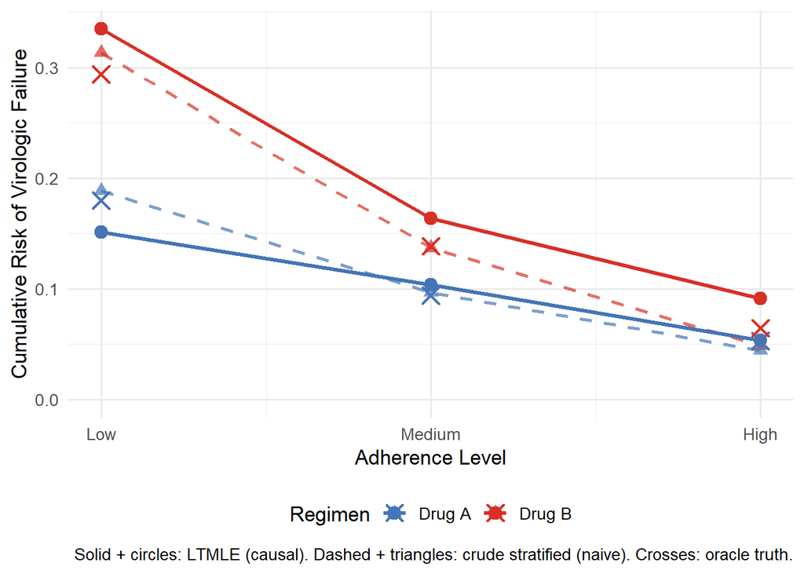

Figure 2: Crude adherence-stratified analysis (dashed) versus causal LTMLE (solid) forgiveness curves, with oracle truth (crosses). The crude approach — observed failure proportions within each adherence stratum — overestimates risk at low adherence and underestimates it at high adherence, producing steeper curves than the causal estimates.

## 7.1 Marginal structural model summary

To complement the nonparametric forgiveness curve, we fit a marginal structural model (MSM) (here a logistic working model to the six LTMLE-estimated regime-specific risks. The MSM compresses the curve into four interpretable coefficients, the most important being the drug $\times$ adherence interaction $\beta_3$, which provides a single-number summary of differential forgiveness and a formal Wald test of $H_0\!: \beta_3 = 0$ (i.e., “do the two drugs differ in forgiveness?”). For the full MSM specification, fitted coefficients (Table 26), and a guide to interpreting each parameter, see Section 13.7.

## 7.2 Connection to modern ART adherence questions

The framework developed in this tutorial is not specific to any particular drug class, but rather to a class of causal questions about how treatment effectiveness depends on imperfect adherence. These questions remain central in modern ART, particularly as treatment modalities diversify.

Two broad types of comparisons are currently of interest:

1. **Oral regimen comparisons within high-barrier therapies.**  
   Contemporary questions often focus on differences between regimens that are all highly effective under perfect adherence, such as two-drug versus three-drug INSTI-based therapies. Here, the primary question is not whether regimens work, but how their risk of failure changes as adherence declines. The methods in this tutorial can be used to estimate and compare *forgiveness curves* across such regimens, defined as the counterfactual risk under sustained adherence patterns.
2. **Long-acting injectables versus daily oral therapy.**  
   Long-acting regimens (e.g., injectable cabotegravir-based therapies) fundamentally change the adherence process. Instead of daily pill-taking, adherence is determined by timely clinic attendance and the pharmacokinetics of drug depots. This shifts the causal question from “what happens under missed doses?” to “what happens under delayed or missed injections?”

From a methodological perspective, both settings can be addressed within the same framework by redefining the time-varying exposure:

- For **oral regimens**, adherence is typically operationalized as proportion of days covered (PDC) over fixed intervals.
- For **injectable regimens**, adherence can be defined in terms of injection timing, delays, and resulting drug concentration trajectories.

The causal estimand does not depend on how adherence is measured, but on how interventions are defined. For example:

- Static regimes can represent sustained adherence levels (e.g., always high PDC or always on-time injections).
- Dynamic regimes can represent clinical decision rules (e.g., intensified follow-up after missed visits).
- Modified treatment policies can represent feasible improvements (e.g., reducing delays in injection visits or increasing average adherence by a fixed amount).

In this way, the LMTP and LTMLE approaches provide a unified framework for comparing regimens that differ not only in pharmacology, but also in the structure of adherence itself. The main requirement is to align the data-generating process and intervention definition with the adherence mechanism relevant to the treatment modality under study. Section 13.9.1 provides a concrete illustration of how this mapping works for long-acting injectables, including an illustrative forgiveness curve and estimand mapping table, and Section 13.9 presents a toy data-generating process for the injectable setting.

Note that these primary analyses use a simplified DGP where every patient’s outcome is directly observed, no one is lost to follow-up, and no one switches regimens. Real HIV cohorts involve all three complications: 1) informative monitoring (viral load is tested only intermittently, and testing frequency depends on clinical suspicion), 2) informative censoring (loss to follow-up is more common among sicker patients), and 3) treatment switching (patients may change regimens after virologic failure or intolerable side effects). The LTMLE framework accommodates each by expanding the node structure and introducing new estimand distinctions.

For a full discussion with an expanded DGP, monitoring diagnostics (masked failure rates, monitoring frequency by adherence level), censoring adjustments via IPCW, and treatment switching handled as either treatment-policy (L-node) or while-on-treatment (C-node) strategies, see Section 13.10. For an LTMLE analysis that extends the primary drug-by-adherence framework to allow time-varying drug switching, see Section 13.10.1.

# 8 Interventional Mediation: Analysis Applied to Long-Acting Injectables

The forgiveness framework generalises naturally to delivery-system comparisons — for example, long-acting injectable versus daily oral ART. For oral regimens, execution is day-to-day pill-taking (PDC); for injectables, it is visit attendance and injection timeliness. Both map onto the same causal chain — regimen $\to$ execution $\to$ pharmacologic exposure $\to$ virologic failure — but the pharmacokinetic link differs: oral formulations track exposure almost linearly with PDC, whereas depot injectables provide sustained absorption that buffers against missed or delayed visits.

## 8.1 The decomposition question

The motivating causal question is:

> *How much of the difference in virologic failure risk between injectable and oral ART is attributable to improved pharmacologic coverage (the execution/forgiveness advantage), versus residual differences that persist even under equalised execution?*

This decomposes the **total delivery-system effect** into an execution-mediated component (operating through coverage $E_t$) and a residual component (direct pharmacologic or non-PK mechanisms). The delivery-system comparison requires an extended SCM with:

- $A_0 \in \{\text{oral}, \text{LA}\}$: Delivery-system assignment.
- $Z_t$: Arm-specific execution (PDC for oral, injection timeliness for LA).
- $E_t$: Pharmacologic coverage (continuous mediator). For oral, $E_t \approx \text{PDC}_t$; for LA, $E_t$ evolves via exponential decay with dose timing.
- $Y_t$: Virologic failure (absorbing).

The DAG now includes $A_0 \to Z_t \to E_t \to Y_t$ with $E_t$ mediating the execution-outcome relationship, and a direct path $A_0 \to Y_t$ for non-PK effects.

Two complementary strategies target the decomposition above: 1) LMTP shift policies for feasible execution improvements: the modified treatment policy $d(E_t) = \min(E_t + \delta, 1)$ perturbs each patient’s observed coverage by a clinically plausible increment, avoiding the positivity violations inherent to static regimes on continuous $E_t$. 2) Interventional mediation decomposition via `crumble` (Hejazi, Rudolph, and Díaz 2023; Díaz, Hejazi, et al. 2021): formally partition the total $A_0 \to Y$ effect into direct, confounder-mediated, and coverage-mediated pathways, providing the mechanism-level decomposition that shift policies alone cannot.

The delivery-system analysis uses an illustrative DGP informed by the qualitative shape and scale of published trial data from ATLAS, FLAIR, and ATLAS-2M (Swindells et al. 2020; Orkin et al. 2021; Overton et al. 2021) — it is not formally calibrated to any specific product or trial endpoint. The DGP simulates a 48-week cohort ($K = 6$ eight-week blocks) comparing long-acting injectable ART ($A_0 = 1$) versus daily oral ART ($A_0 = 0$). In the LA arm, execution reflects injection timeliness (on-time probability $\approx 0.94$) and pharmacologic coverage $E_t$ evolves via exponential decay from the depot. In the oral arm, execution is continuous PDC and coverage tracks it linearly. Note that this delivery-system DGP is distinct from the simpler toy injectable DGP described in Section 13.9, which illustrates delay-based adherence mechanics in isolation without the mediation decomposition.

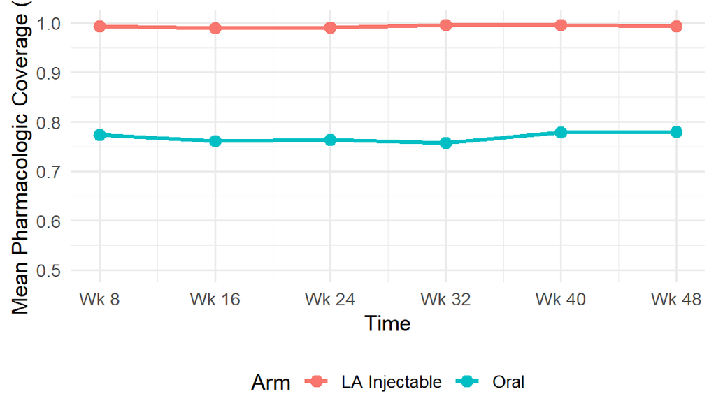

Figure 3: Mean pharmacologic coverage ($E_t$) over six 8-week blocks by arm. The LA arm maintains near-perfect coverage ($\approx 0.99$) due to depot buffering, while the oral arm averages $\approx 0.76$.

```r
if (!is.null(dat_v5ds)) {
  E_means <- data.frame(
    block = rep(1:K_ds, 2),
    arm = rep(c("Oral", "LA Injectable"), each = K_ds),
    mean_E = c(
      sapply(1:K_ds, function(t) mean(dat_v5ds[dat_v5ds$A0 == 0, paste0("E_", t)], na.rm = TRUE)),
      sapply(1:K_ds, function(t) mean(dat_v5ds[dat_v5ds$A0 == 1, paste0("E_", t)], na.rm = TRUE))
    )
  )
  ggplot(E_means, aes(x = block, y = mean_E, color = arm, group = arm)) +
    geom_line(linewidth = 1.2) +
    geom_point(size = 3) +
    scale_x_continuous(breaks = 1:K_ds, labels = paste0("Wk ", 8 * (1:K_ds))) +
    labs(x = "Time", y = "Mean Pharmacologic Coverage (E)", color = "Arm") +
    theme_minimal(base_size = 13) +
    theme(legend.position = "bottom") +
    coord_cartesian(ylim = c(0.5, 1))
}
```

Because the DGP is known, oracle truth — the counterfactual risk under forced constant coverage, computed via Monte Carlo simulation ($n = 50{,}000$) — establishes the target parameter free of estimation noise.

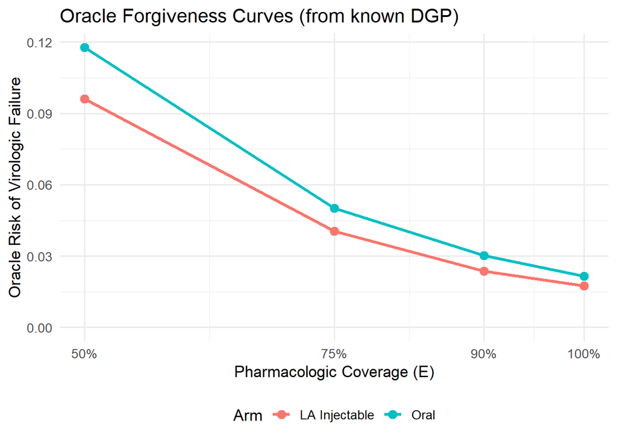

Figure 4: Oracle forgiveness curves: 48-week virologic failure risk under forced constant pharmacologic coverage. The LA curve is flatter (more forgiving) because the depot formulation buffers against coverage gaps.

The gap between the LA and oral curves at each coverage level reflects the direct regimen effect (built into the DGP). The steeper slope of the oral curve indicates lower pharmacologic forgiveness — small coverage drops produce larger risk increases. Because pharmacologic coverage is continuous and its distribution differs markedly between arms (mean $E_t \approx 0.99$ for LA versus $\approx 0.76$ for oral), static interventions that force $E_t$ to a common value violate positivity whenever the target falls outside the observed support. Estimation in this setting is more naturally framed using either feasible-policy interventions that perturb observed coverage or decomposition-based approaches that separate execution-mediated from residual effects.

One intuitive approach is to equalize execution across arms — force $E_t = 1$ in both — and attribute the residual risk difference to non-PK mechanisms. The oracle curves above confirm that such a residual exists: the LA and oral curves do not converge at $E_t = 1$. However, estimation of this contrast from data is impractical because perfect oral execution ($\text{PDC} = 1.0$) isn’t well supported by the observed distribution. Moreover, the equalized-execution approach cannot distinguish among the multiple pathways through which $A_0$ affects $Y$. Instead, we use a mediation analyses.

## 8.2 Interventional mediation decomposition

The delivery-system comparison raises a mechanistic question that a standard forgiveness curve cannot answer. A forgiveness curve for the injectable arm estimates the risk under forced constant coverage — but it does not tell us *why* the injectable arm outperforms the oral arm. Is it because depot pharmacokinetics maintain therapeutic drug levels (a pure PK mechanism, operating through coverage $E_t$)? Or is part of the advantage attributable to other pathways, such as differences in immune recovery trajectory (CD4 changes, $L_t$) or unmeasured non-adherence factors ($A_0 \to Y$ direct)? The LMTP shift-policy approach can quantify the aggregate benefit of feasible coverage improvements, but it cannot isolate whether the delivery-system advantage operates through pharmacologic coverage versus other pathways. Interventional mediation is therefore introduced to formally decompose the total effect into mechanism-specific components.

Note also that the sign pattern of the pathway estimates reflects the specific DGP parameterization. The p2 pathway ($A_0 \to L_t \to Y$, approximately $+4$ pp positive) arises because the LA arm assignment ($A_0 = 1$) does not directly improve adherence in the delivery-system DGP (the drug-to-adherence pathway operates differently here than in the oral-ART DGP), while the CD4-to-failure coefficient means that improved health status in the LA arm slightly reduces failure through the L channel in a way that partially offsets coverage benefits. This is a DGP artifact and should not be interpreted as a clinical finding about injectable versus oral ART. The sign pattern reflects the simulated parameterization and should not be interpreted as an empirical finding about injectable versus oral ART in clinical practice.

Shift policies quantify feasible improvements but cannot distinguish the mechanisms through which $A_0$ affects $Y$. The interventional mediation framework (Hejazi, Rudolph, and Díaz 2023; Díaz, Hejazi, et al. 2021) provides this decomposition, partitioning the total effect into four pathways: (1) $A_0 \to Y$ direct (non-PK benefits), (2) $A_0 \to L_t \to Y$ (via CD4/symptoms), (3) $A_0 \to L_t \to E_t \to Y$ (via confounders then coverage), and (4) $A_0 \to E_t \to Y$ (via coverage — the forgiveness mechanism). If pathway 4 dominates, the LA advantage is primarily pharmacokinetic.

The `crumble` package implements this decomposition using nonparametric efficiency theory. We fit the recanting-twins decomposition to a cross-sectional summary of the longitudinal delivery-system data.

**Teaching code: interventional mediation decomposition with crumble**

```r
library(crumble)

# ── Why interventional (not natural) mediation? ──────────────────────────
# Natural direct/indirect effects require cross-world counterfactuals:
# "the mediator value that WOULD occur under A=a, plugged into the
# outcome model under A=a'." When a mediator-outcome confounder L_t is
# affected by treatment (as here: CD4 depends on drug assignment),
# these cross-world quantities are not identified. Interventional effects
# replace the cross-world mediator with a STOCHASTIC draw from the
# mediator distribution under a reference treatment, avoiding the
# cross-world assumption entirely [Díaz et al., 2021].

# ── Load pre-built mediation data ─────────────────────────────────────────
# Cross-sectional summary saved by the manuscript (output/v13_cache/crumble_mediation_data.rds):
#   W1..W4 = baseline covariates (age, female, comorbidity, CD4)
#   A      = delivery-system assignment (1=LA, 0=oral)
#   Z      = intermediate confounder affected by A (mean CD4 over follow-up)
#   M      = mediator: mean pharmacologic coverage (mean E_t over follow-up)
#   Y      = virologic failure by 48 weeks
# Load pre-built data; drop any rows with NA (early failures → NaN in Z/M)
med_data <- na.omit(readRDS(file.path(cache_dir, "crumble_mediation_data.rds")))

# ── Fit crumble ──────────────────────────────────────────────────────────
# d0/d1 define the counterfactual treatment assignments (reference/active).
# For binary A ∈ {0,1}: d0 sets everyone to oral (A=0), d1 to LA (A=1).
# effect = "RT" requests the recanting-twins 4-pathway decomposition,
# which is identified even with treatment-affected mediator-outcome
# confounders (Z). Alternatives: "RI" (2-way interventional), "N"
# (natural), "O" (organic).
fit_med <- crumble(
  data      = med_data,
  trt       = "A",                         # exposure: delivery-system assignment
  outcome   = "Y",                         # outcome: virologic failure
  mediators = "M",                         # mediator: pharmacologic coverage
  moc       = "Z",                         # mediator-outcome confounder (CD4)
  covar     = c("W1", "W2", "W3", "W4"),  # baseline covariates
  d0        = \(data, trt) rep(0, nrow(data)),  # reference: oral (A=0)
  d1        = \(data, trt) rep(1, nrow(data)),  # active: LA injectable (A=1)
  effect    = "RT",                        # recanting-twins 4-way decomposition
  learners  = "glm",                       # or c("glm", "ranger") for SL
  control   = crumble_control(
    crossfit_folds        = 2L,            # reduce from default 10 for speed
    mlr3superlearner_folds = 2L            # reduce from default 10 for speed
  )
)

results <- tidy(fit_med)
# The recanting-twins decomposition yields:
#   p1:  A → Y direct          (non-PK benefits)
#   p2:  A → Z → Y             (via CD4 changes, not through M)
#   p3:  A → Z → M → Y         (via CD4 then coverage)
#   p4:  A → M → Y             (via coverage: THE forgiveness mechanism)
#   direct  = p1 + p2           (all non-M pathways)
#   indirect = p3 + p4          (all M-mediated pathways)
#   ate     = direct + indirect (total effect)
# If p4 dominates → the LA advantage is primarily pharmacokinetic.
print(results)
```

```
# A tibble: 8 × 5
  estimand                  estimate std.error  conf.low conf.high
  <chr>                        <dbl>     <dbl>     <dbl>     <dbl>
1 p1                        0.00958   0.00101   0.00760    0.0116
2 p2                        0.0268    0.00178   0.0233     0.0303
3 p3                        0.000877  0.000168  0.000548   0.00121
4 p4                       -0.0433    0.000769 -0.0448    -0.0418
5 intermediate_confounding -0.0148    0.00200  -0.0187    -0.0109
6 ate                      -0.0209    0.00174  -0.0243    -0.0175
7 indirect                 -0.0424    0.000775 -0.0439    -0.0409
8 direct                    0.0364    0.00153   0.0334     0.0394
```

| estimand | estimate | std.error | conf.low | conf.high |
| --- | --- | --- | --- | --- |
| p1 | 0.0084 | 0.0006 | 0.0072 | 0.0097 |
| p2 | 0.0359 | 0.0012 | 0.0334 | 0.0383 |
| p3 | 0.0012 | 0.0001 | 0.0009 | 0.0014 |
| p4 | -0.0484 | 0.0006 | -0.0495 | -0.0472 |
| intermediate_confounding | -0.0239 | 0.0012 | -0.0262 | -0.0216 |
| ate | -0.0268 | 0.0010 | -0.0287 | -0.0250 |
| indirect | -0.0472 | 0.0006 | -0.0483 | -0.0461 |
| direct | 0.0443 | 0.0011 | 0.0421 | 0.0464 |

For background on the injectable adherence construct and illustrative forgiveness curves, see Section 13.9.1; for details of the delivery-system DGP, see Section 13.9.

The analyses above illustrate the framework using a single simulated cohort. To assess whether the estimators recover the true causal estimand on average — and to characterise their bias, variance, and coverage properties — we turn to a repeated Monte Carlo study.

# 9 Monte Carlo Validation of Estimator Performance

The preceding sections demonstrate how an analyst would implement the forgiveness-curve analysis on a single dataset: defining the causal estimand, checking positivity, running LTMLE and LMTP, and interpreting the results. This section shifts perspective from tutorial demonstration to **methodological validation**. Using the same data-generating process with known ground truth, we evaluate the finite-sample properties of each estimator across 500 independent replications ($n = 5,000$ per replication). The goal is to verify that the targeted estimators $\Psi(\hat{P}_n)$ recover the true statistical parameter $\Psi(P_0)$ with low bias, well-calibrated standard errors, and nominal confidence interval coverage, and to quantify where and why they struggle.

## 9.1 Simulation design

The Monte Carlo study uses the same DGP as the tutorial worked example ($K = 4$ time blocks, parameters as defined in Section 4.1), with 500 independent replications and a sample size of $n = 5,000$ per replication. The oracle truth is computed from $N = 100{,}000$ draws from the same DGP, providing essentially exact reference risks against which estimators are evaluated.

## 9.2 Estimands and estimators evaluated

The estimators compared are: (1) adherence-stratified regression (naive, no causal adjustment); (2) LTMLE for static adherence regimes $\psi(a_0, z)$ (primary causal estimand); (3) LMTP-static (a density-ratio-based route to the same static-regime causal contrast, included to compare estimation strategies for the same target parameter); and (4) LMTP-shift targeting $\psi^d$ (a feasible shift policy $d(Z_t) = \min(Z_t + 1, 3)$, a different but complementary estimand). Each estimator is evaluated against its own oracle truth, so bias and coverage numbers are valid within each row even though the shift parameter targets a different estimand. All nuisance models use `SL.glm` (logistic regression).

## 9.3 Evaluation metrics

- **Bias**: Mean estimated value minus oracle truth.
- **SD**: Empirical standard deviation across replications.
- **RMSE**: Root mean squared error.
- **SE/SD**: Ratio of mean estimated standard error to empirical SD (should be $\approx 1.0$ for well-calibrated variance).
- **Coverage**: Empirical coverage of the nominal 95% CI (should be $\approx 0.95$).
- **|Bias|/SD**: Values $< 0.5$ suggest bias is dominated by sampling noise.
- **Power**: Proportion of replications with $p < 0.05$ (rejection rate; interpretable as power when the true effect $\neq 0$).

## 9.4 Results: risk difference contrasts (primary)

Table 7 shows the RD contrasts, the primary, stable summary measure.

```r
if (!is.null(mc_summary)) {
  rd_rows <- mc_summary[grepl(" RD", mc_summary$estimand), ]
  if (nrow(rd_rows) > 0) {
    display_cols <- intersect(
      c("estimand", "truth", "mean_est", "bias", "sd", "rmse",
        "mean_se", "se_ratio", "coverage_95", "bias_var_ratio",
        "power_05", "n_valid"),
      names(rd_rows))
    print(kable(rd_rows[, display_cols], digits = 4,
                align = "lrrrrrrrrrrr", row.names = FALSE,
                col.names = c("Estimand", "Truth", "Mean Est", "Bias",
                              "SD", "RMSE", "Mean SE", "SE/SD",
                              "Coverage", "|Bias|/SD", "Power",
                              "n")[seq_along(display_cols)]) |>
      kable_styling(bootstrap_options = c("striped", "condensed"),
                    full_width = FALSE, font_size = 9))
  }
} else {
  no_results_msg("Monte Carlo summary")
}
```

Table 7: Monte Carlo performance for risk difference contrasts (Drug A − Drug B).

| Estimand | Truth | Mean Est | Bias | SD | RMSE | Mean SE | SE/SD | Coverage | &#124;Bias&#124;/SD | Power | n |
| --- | --- | --- | --- | --- | --- | --- | --- | --- | --- | --- | --- |
| Naive RD (low) | -0.1142 | -0.0793 | 0.0348 | 0.0246 | 0.0426 | 0.0241 | 0.9832 | 0.720 | 1.4193 | 0.892 | 500 |
| Naive RD (medium) | -0.0447 | -0.0396 | 0.0051 | 0.0132 | 0.0142 | 0.0133 | 1.0092 | 0.928 | 0.3882 | 0.862 | 500 |
| Naive RD (high) | -0.0118 | -0.0166 | -0.0048 | 0.0136 | 0.0144 | 0.0132 | 0.9660 | 0.922 | 0.3503 | 0.242 | 500 |
| LTMLE RD (z=1) | -0.1142 | -0.1063 | 0.0079 | 0.0495 | 0.0501 | 0.0822 | 1.6595 | 0.998 | 0.1591 | 0.158 | 500 |
| LTMLE RD (z=2) | -0.0447 | -0.0435 | 0.0012 | 0.0504 | 0.0504 | 0.0574 | 1.1384 | 0.984 | 0.0228 | 0.090 | 500 |
| LTMLE RD (z=3) | -0.0118 | -0.0089 | 0.0029 | 0.0372 | 0.0374 | 0.0494 | 1.3261 | 0.996 | 0.0781 | 0.012 | 500 |
| LMTP-static RD (z=1) | -0.1142 | -0.1259 | -0.0118 | 0.0521 | 0.0534 | 0.0610 | 1.1713 | 0.962 | 0.2259 | 0.610 | 500 |
| LMTP-static RD (z=2) | -0.0447 | -0.0466 | -0.0019 | 0.0481 | 0.0481 | 0.0034 | 0.0708 | 0.106 | 0.0396 | 0.938 | 500 |
| LMTP-static RD (z=3) | -0.0118 | -0.0075 | 0.0043 | 0.0377 | 0.0380 | 0.0367 | 0.9728 | 0.892 | 0.1154 | 0.072 | 500 |
| LMTP-shift RD | -0.0291 | -0.0272 | 0.0019 | 0.0238 | 0.0239 | 0.0251 | 1.0516 | 0.968 | 0.0784 | 0.146 | 500 |

**LMTP-static inference at medium and high adherence is unreliable**

## 9.5 Results: risk ratio contrasts (secondary)

Table 8 shows RR contrasts. Note the extreme instability at $z = 2, 3$ where both risks approach the boundary near zero; when one or both risks approach the boundary, division amplifies estimation noise in sparse-support strata, producing explosive replicates that corrupt the mean. Medians are used as location summaries throughout. The RR should be interpreted with caution and is provided as a secondary descriptive summary only.

```r
if (!is.null(mc_summary)) {
  rr_rows <- mc_summary[grepl(" RR", mc_summary$estimand), ]
  if (nrow(rr_rows) > 0) {
    display_cols <- intersect(
      c("estimand", "truth", "median_est", "bias_median", "sd", "rmse",
        "mean_se", "se_ratio", "coverage_95", "bias_var_ratio",
        "power_05", "n_valid"),
      names(rr_rows))
    print(kable(rr_rows[, display_cols], digits = 4,
                align = "lrrrrrrrrrrr", row.names = FALSE,
                col.names = c("Estimand", "Truth", "Median Est", "Med Bias",
                              "SD", "RMSE", "Mean SE", "SE/SD",
                              "Coverage", "|Bias|/SD", "Power",
                              "n")[seq_along(display_cols)]) |>
      kable_styling(bootstrap_options = c("striped", "condensed"),
                    full_width = FALSE, font_size = 9))
  }
} else {
  no_results_msg("Monte Carlo summary")
}
```

Table 8: Monte Carlo performance for risk ratio contrasts (Drug A / Drug B). Note: mean RR is unstable at z = 2, 3; use median.

| Estimand | Truth | Median Est | Med Bias | SD | RMSE | Mean SE | SE/SD | Coverage | &#124;Bias&#124;/SD | Power | n |
| --- | --- | --- | --- | --- | --- | --- | --- | --- | --- | --- | --- |
| Naive RR (low) | 0.6117 | 0.7586 | 0.1469 | 0.0681 | 0.1657 | 0.0874 | 1.2836 | 0.324 | 2.2172 | 0.886 | 500 |
| Naive RR (medium) | 0.6773 | 0.6941 | 0.0168 | 0.0874 | 0.0888 | 0.1275 | 1.4580 | 0.948 | 0.1787 | 0.862 | 500 |
| Naive RR (high) | 0.8168 | 0.7374 | -0.0793 | 0.2003 | 0.2070 | 0.2355 | 1.1759 | 0.910 | 0.2605 | 0.278 | 500 |
| LTMLE RR (z=1) | 0.6117 | 0.6361 | 0.0244 | 0.1490 | 0.1529 | 1.0000 | 6.7093 | 0.998 | 0.2273 | 0.034 | 500 |
| LTMLE RR (z=2) | 0.6773 | 0.6775 | 0.0002 | 0.3538 | 0.3604 | 1.0000 | 2.8261 | 0.982 | 0.1938 | 0.076 | 500 |
| LTMLE RR (z=3) | 0.8168 | 0.8728 | 0.0560 | 0.9247 | 0.9839 | 1.0000 | 1.0814 | 0.998 | 0.3635 | 0.006 | 500 |
| LMTP-static RR (z=1) | 0.6117 | 0.5583 | -0.0534 | 0.1528 | 0.1587 | 0.3388 | 2.2177 | 0.936 | 0.2814 | 0.508 | 500 |
| LMTP-static RR (z=2) | 0.6773 | 0.6407 | -0.0366 | 0.3390 | 0.3410 | 0.0347 | 0.1024 | 0.106 | 0.1088 | 0.938 | 500 |
| LMTP-static RR (z=3) | 0.8168 | 0.9030 | 0.0862 | 0.8391 | 0.9002 | 0.6701 | 0.7986 | 0.850 | 0.3886 | 0.130 | 500 |
| LMTP-shift RR | 0.6848 | 0.7151 | 0.0303 | 0.2063 | 0.2125 | 0.2975 | 1.4421 | 0.958 | 0.2462 | 0.190 | 500 |

## 9.6 Bias visualization

Figure 5 compares RD bias across estimators, the primary contrast measure. Figure 6 shows RR bias using the *median* rather than the mean (which is corrupted by extreme outliers at z = 2, 3).

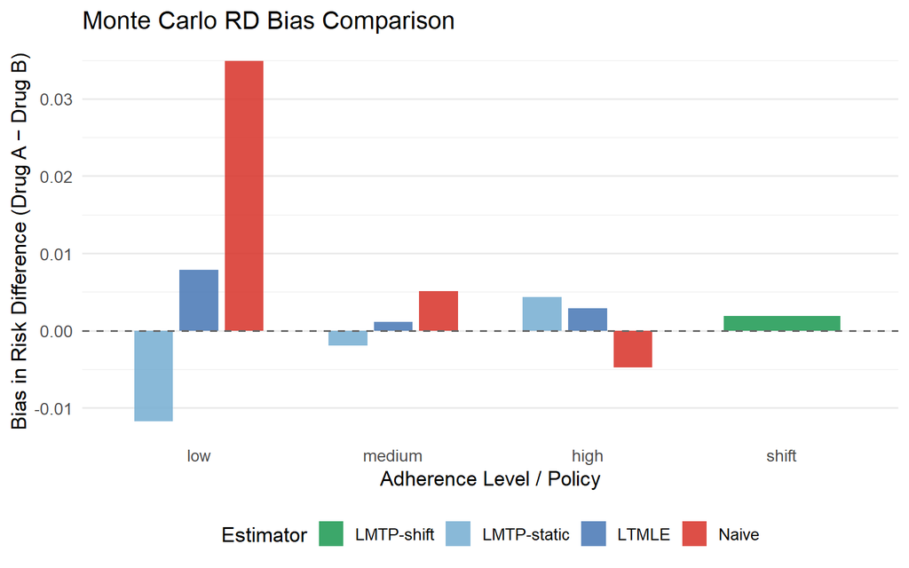

Figure 5: Monte Carlo bias in risk difference (Drug A − Drug B) across estimators and adherence levels.

```r
if (!is.null(mc_summary)) {
  rd_rows <- mc_summary[grepl(" RD", mc_summary$estimand), ]
  if (nrow(rd_rows) > 0 && any(!is.na(rd_rows$bias))) {
    rd_rows$estimator <- ifelse(grepl("Naive", rd_rows$estimand), "Naive",
                          ifelse(grepl("LTMLE", rd_rows$estimand), "LTMLE",
                          ifelse(grepl("LMTP-static", rd_rows$estimand), "LMTP-static",
                                 "LMTP-shift")))
    rd_rows$adherence <- ifelse(grepl("low", rd_rows$estimand), "low",
                          ifelse(grepl("medium", rd_rows$estimand), "medium",
                          ifelse(grepl("high", rd_rows$estimand), "high",
                          ifelse(grepl("z=1", rd_rows$estimand), "low",
                          ifelse(grepl("z=2", rd_rows$estimand), "medium",
                          ifelse(grepl("z=3", rd_rows$estimand), "high", "shift"))))))
    rd_rows$adherence <- factor(rd_rows$adherence,
                                 levels = c("low", "medium", "high", "shift"))

    ggplot(rd_rows[!is.na(rd_rows$bias), ],
           aes(x = adherence, y = bias, fill = estimator)) +
      geom_col(position = position_dodge(width = 0.7), width = 0.6, alpha = 0.85) +
      geom_hline(yintercept = 0, linetype = "dashed", color = "grey40") +
      scale_fill_manual(values = c("Naive" = "#D73027", "LTMLE" = "#4575B4",
                                    "LMTP-static" = "#74ADD1",
                                    "LMTP-shift" = "#1A9850")) +
      labs(x = "Adherence Level / Policy",
           y = "Bias in Risk Difference (Drug A − Drug B)",
           title = "Monte Carlo RD Bias Comparison",
           fill = "Estimator") +
      theme_minimal(base_size = 13) +
      theme(legend.position = "bottom", panel.grid.major.x = element_blank())
  }
}
```

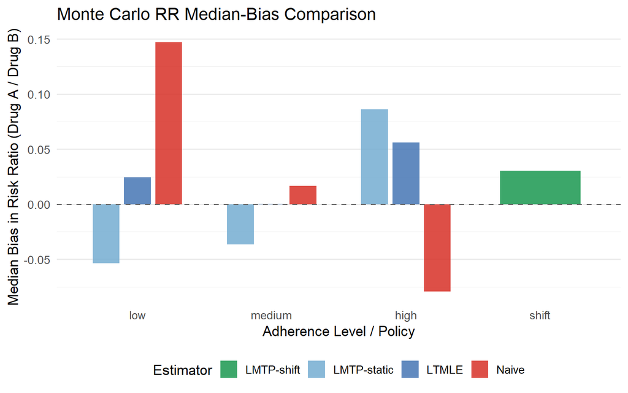

Figure 6: Monte Carlo median bias in risk ratio (Drug A / Drug B). Median used because mean RR is unstable at z = 2, 3.

```r
if (!is.null(mc_summary)) {
  rr_rows <- mc_summary[grepl(" RR", mc_summary$estimand), ]
  if (nrow(rr_rows) > 0 && any(!is.na(rr_rows$bias_median))) {
    rr_rows$estimator <- ifelse(grepl("Naive", rr_rows$estimand), "Naive",
                          ifelse(grepl("LTMLE", rr_rows$estimand), "LTMLE",
                          ifelse(grepl("LMTP-static", rr_rows$estimand), "LMTP-static",
                                 "LMTP-shift")))
    rr_rows$adherence <- ifelse(grepl("low", rr_rows$estimand), "low",
                          ifelse(grepl("medium", rr_rows$estimand), "medium",
                          ifelse(grepl("high", rr_rows$estimand), "high",
                          ifelse(grepl("z=1", rr_rows$estimand), "low",
                          ifelse(grepl("z=2", rr_rows$estimand), "medium",
                          ifelse(grepl("z=3", rr_rows$estimand), "high", "shift"))))))
    rr_rows$adherence <- factor(rr_rows$adherence,
                                 levels = c("low", "medium", "high", "shift"))

    ggplot(rr_rows[!is.na(rr_rows$bias_median), ],
           aes(x = adherence, y = bias_median, fill = estimator)) +
      geom_col(position = position_dodge(width = 0.7), width = 0.6, alpha = 0.85) +
      geom_hline(yintercept = 0, linetype = "dashed", color = "grey40") +
      scale_fill_manual(values = c("Naive" = "#D73027", "LTMLE" = "#4575B4",
                                    "LMTP-static" = "#74ADD1",
                                    "LMTP-shift" = "#1A9850")) +
      labs(x = "Adherence Level / Policy",
           y = "Median Bias in Risk Ratio (Drug A / Drug B)",
           title = "Monte Carlo RR Median-Bias Comparison",
           fill = "Estimator") +
      theme_minimal(base_size = 13) +
      theme(legend.position = "bottom", panel.grid.major.x = element_blank())
  }
}
```

## 9.7 Interpretive discussion

**3. LMTP-static suffers density-ratio collapse.** SE/SD ratios fall as low as 0.071 at $z = 2$, with only 11% empirical coverage. This behavior reflects extreme variability in estimated density ratios when the intervention places substantial mass in regions of near-zero observed treatment density. This illustrates that importance-weighted estimators can fail wherever static-regime trajectories are thinly supported relative to observed data, and confirms that LMTP-static should not be used as a default robustness check in settings where static adherence regimes are rare.

**4. Risk difference is the stable contrast; RR is unreliable whenever risks are extreme.** The RD is bounded and interpretable across all estimators and adherence levels, with LMTP-shift achieving the best calibration (SE/SD = 1.05, coverage = 97%). Reporting RD as the primary contrast is particularly important when any stratum approaches either risk extreme.

## 9.8 Secondary treatment-comparison results

As a secondary analysis, we compared regimens under a shared adherence distribution by mapping both treatment strategies to the observed adherence pattern of Drug A (the more forgiving regimen). This controlled-adherence contrast isolates differences in regimen-specific outcome risk apart from differences in adherence behavior attributable to side effects or other regimen-specific pathways. The resulting risk difference therefore reflects regimen differences under a common adherence pattern, not differences arising through each regimen’s natural adherence behavior. Full results from this secondary analysis are reported in Section 13.10.

## 9.9 V3 EHR Monte Carlo results (continuous PDC)

```r
if (!mc_v3_available) {
  no_results_msg("V3 EHR Monte Carlo results. Run scripts/run_monte_carlo_ehr.R to generate")
}
```

**Pre-computed results not found.** V3 EHR Monte Carlo results. Run scripts/run_monte_carlo_ehr.R to generate requires cached outputs. Re-render with caching enabled.

```r
valid_tbl <- data.table(

  Estimator = c("LMTP-shift (+10pp PDC)", "LMTP-static", "LMTP quantile-map", "Naive"),
  `Valid Reps` = c(mc_v3$n_shift_valid, mc_v3$n_static_valid,
                   mc_v3$n_qmap_valid, mc_v3$n_naive_valid),
  `Total Reps` = rep(mc_v3$n_reps, 4),
  `Success Rate` = sprintf("%.0f%%",
    100 * c(mc_v3$n_shift_valid, mc_v3$n_static_valid,
            mc_v3$n_qmap_valid, mc_v3$n_naive_valid) / mc_v3$n_reps))

kable(valid_tbl, caption = "V3 EHR MC: Valid replications per estimator") |>
  kable_styling(bootstrap_options = c("striped", "condensed"), full_width = FALSE)
```

[output not shown]

```r
if (!is.null(mc_v3$shift_summary)) {
  ss <- copy(mc_v3$shift_summary)
  ss[, Drug := ifelse(A0 == 1, "Drug A", "Drug B")]
  display_cols <- intersect(
    c("Drug", "mean_RD", "sd_RD", "mean_SE", "se_ratio",
      "mean_risk_natural", "mean_risk_shift", "n_valid"),
    names(ss))
  kable(ss[, ..display_cols], digits = 4,
        col.names = c("Drug", "Mean RD", "MC SD", "Mean SE", "SE/SD",
                       "Mean Risk (obs)", "Mean Risk (shift)", "n")[seq_along(display_cols)]) |>
    kable_styling(bootstrap_options = c("striped", "condensed"), full_width = FALSE)
}
```

[output not shown]

```r
if (!is.null(mc_v3$naive_summary)) {
  ns <- copy(mc_v3$naive_summary)
  display_cols <- intersect(
    c("adh_cat", "mean_RD", "sd_RD", "mean_SE", "n_valid"),
    names(ns))
  kable(ns[, ..display_cols], digits = 4,
        col.names = c("Adherence", "Mean RD", "MC SD", "Mean SE", "n")[seq_along(display_cols)]) |>
    kable_styling(bootstrap_options = c("striped", "condensed"), full_width = FALSE)
}
```

[output not shown]

```r
if (!is.null(mc_v3$qmap_summary)) {
  qs <- copy(mc_v3$qmap_summary)
  decomp <- data.table(
    Component = c("Drug A observed risk", "Drug B observed risk",
                   "Drug B shifted risk (Drug A adherence)",
                   "Adherence-mediated (B obs - B shifted)",
                   "Residual pharmacologic (A obs - B shifted)",
                   "Quantile-map shift RD"),
    `Mean` = c(qs$mean_risk_A, qs$mean_risk_B, qs$mean_risk_B_sh,
                qs$mean_adh_med, qs$mean_resid_pharm, qs$mean_RD),
    `MC SD` = c(qs$sd_risk_A, qs$sd_risk_B, qs$sd_risk_B_sh,
                 qs$sd_adh_med, qs$sd_resid_pharm, qs$sd_RD))

  kable(decomp, digits = 5,
        caption = "V3 EHR MC: Quantile-mapping decomposition") |>
    kable_styling(bootstrap_options = c("striped", "condensed"), full_width = FALSE)
}
```

[output not shown]

```r
if (!is.null(mc_v3$shift_dt) && nrow(mc_v3$shift_dt) > 0) {
  shift_plot_dt <- copy(mc_v3$shift_dt)
  shift_plot_dt[, Drug := ifelse(A0 == 1, "Drug A (INSTI)", "Drug B (NNRTI)")]

  ggplot(shift_plot_dt, aes(x = RD, fill = Drug)) +
    geom_histogram(bins = 40, alpha = 0.7, position = "identity") +
    geom_vline(xintercept = 0, linetype = "dashed", color = "grey40") +
    scale_fill_manual(values = drug_pal_v3) +
    facet_wrap(~Drug, ncol = 2) +
    labs(x = "Risk Difference (shifted - observed)",
         y = "Replications",
         title = "MC Distribution of LMTP-Shift RD (+10pp PDC)") +
    theme_minimal(base_size = 13) +
    theme(legend.position = "none")
}
```

[output not shown]

```r
if (!is.null(mc_v3$qmap_dt) && nrow(mc_v3$qmap_dt) > 0) {
  qmap_long <- melt(mc_v3$qmap_dt,
    measure.vars = c("adherence_mediated", "residual_pharmacologic"),
    variable.name = "Component", value.name = "RD")
  qmap_long[, Component := fifelse(Component == "adherence_mediated",
    "Adherence-mediated", "Residual pharmacologic")]

  ggplot(qmap_long, aes(x = RD, fill = Component)) +
    geom_histogram(bins = 40, alpha = 0.7, position = "identity") +
    geom_vline(xintercept = 0, linetype = "dashed", color = "grey40") +
    scale_fill_manual(values = c("Adherence-mediated" = "#E66100",
                                  "Residual pharmacologic" = "#4575B4")) +
    labs(x = "Risk Difference Component",
         y = "Replications",
         title = "Quantile-Mapping Decomposition Across MC Replications") +
    theme_minimal(base_size = 13) +
    theme(legend.position = "bottom")
}
```

[output not shown]

```r
if (!is.null(mc_v3$shift_summary) && !is.null(mc_v3$naive_summary)) {
  se_cal <- data.table(
    Estimator = c(
      paste0("LMTP-shift (Drug ", c("A", "B"), ")"),
      if (!is.null(mc_v3$qmap_summary)) "LMTP-qmap" else NULL,
      paste0("Naive (", mc_v3$naive_summary$adh_cat, ")")),
    SE_SD = c(
      mc_v3$shift_summary$se_ratio,
      if (!is.null(mc_v3$qmap_summary)) mc_v3$qmap_summary$mean_SE / mc_v3$qmap_summary$sd_RD else NULL,
      mc_v3$naive_summary$mean_SE / mc_v3$naive_summary$sd_RD))

  ggplot(se_cal, aes(x = reorder(Estimator, SE_SD), y = SE_SD)) +
    geom_col(fill = "steelblue", alpha = 0.8) +
    geom_hline(yintercept = 1, linetype = "dashed", color = "red", linewidth = 0.8) +
    coord_flip() +
    labs(x = NULL, y = "SE / SD Ratio (1.0 = perfect calibration)",
         title = "Standard Error Calibration (V3 EHR MC)") +
    theme_minimal(base_size = 13)
}
```

[output not shown]

**LMTP-static with continuous PDC**

LMTP-static failed on all replications when targeting exact continuous PDC values. Static regimes set PDC to a point mass (e.g., 0.75) at every time point, but the observed continuous PDC has zero probability at any exact value, creating a complete positivity violation. This motivates two solutions: (1) categorize PDC into ordinal bins before running LMTP-static (as done in the single-cohort V3 EHR analysis), or (2) use shift or quantile-mapping estimators that respect the support of the observed treatment distribution. Results using categorized adherence are pending re-run.

# 10 Results Under the Realistic EHR-Style DGP

The analyses above use a simplified ordinal-adherence DGP to isolate the core methodological issues. This section presents parallel results under a more realistic EHR-style DGP that simulates raw claims and EMR tables with continuous PDC, informative monitoring, informative censoring, informative treatment switching, and 36 months of follow-up in 12 quarterly blocks. In this DGP, Drug A and Drug B have the same adherence distribution (no adherence advantage for either drug), but Drug A has a stronger pharmacologic forgiveness advantage: Drug A’s baseline failure penalty is larger (`fail_beta_A = -0.25`) and the forgiveness interaction with suboptimal adherence is stronger (`fail_beta_A_adh = -0.80`), so the entire drug difference operates through the pharmacologic pathway rather than through adherence behaviour. Continuous PDC is categorised into four ordinal bins (<65%, 65–80%, 80–90%, >90%) for the naive estimator and for LMTP-static estimation to avoid positivity violations with continuous treatment.

```r
if (!v3_available) {
  no_results_msg("V3 EHR results. Run scripts/save_v3_results_for_tutorial.R to generate")
}
```

## 10.1 V3 EHR cohort summary

```r
v3_summary <- data.table(
  Feature = c("Sample size", "Follow-up", "Block size", "Initial INSTI (%)",
              "Mean PDC", "Ever censored (%)", "Ever switched (%)",
              "Cumulative failure (%)", "Cumulative death (%)"),
  Value = c(
    sprintf("%d", length(unique(panel_v3$patient_id))),
    "36 months", "90 days (quarterly)",
    sprintf("%.1f", mean(panel_v3[block == 0]$A0) * 100),
    sprintf("%.2f", mean(panel_v3$PDC, na.rm = TRUE)),
    sprintf("%.1f", mean(panel_v3[, max(C), by = patient_id]$V1) * 100),
    sprintf("%.1f", mean(panel_v3[, max(S), by = patient_id]$V1) * 100),
    sprintf("%.1f", mean(panel_v3[, max(Y), by = patient_id]$V1) * 100),
    sprintf("%.1f", mean(panel_v3[, max(D), by = patient_id]$V1) * 100)))

kable(v3_summary, caption = "V3 EHR simulated cohort characteristics") |>
  kable_styling(bootstrap_options = c("striped"), full_width = FALSE)
```

Table 13: V3 EHR simulated cohort characteristics

| Feature | Value |
| --- | --- |
| Sample size | 5000 |
| Follow-up | 36 months |
| Block size | 90 days (quarterly) |
| Initial INSTI (%) | 53.6 |
| Mean PDC | 0.58 |
| Ever censored (%) | 10.6 |
| Ever switched (%) | 9.6 |
| Cumulative failure (%) | 67.7 |
| Cumulative death (%) | 3.2 |

## 10.2 V3 oracle forgiveness curves

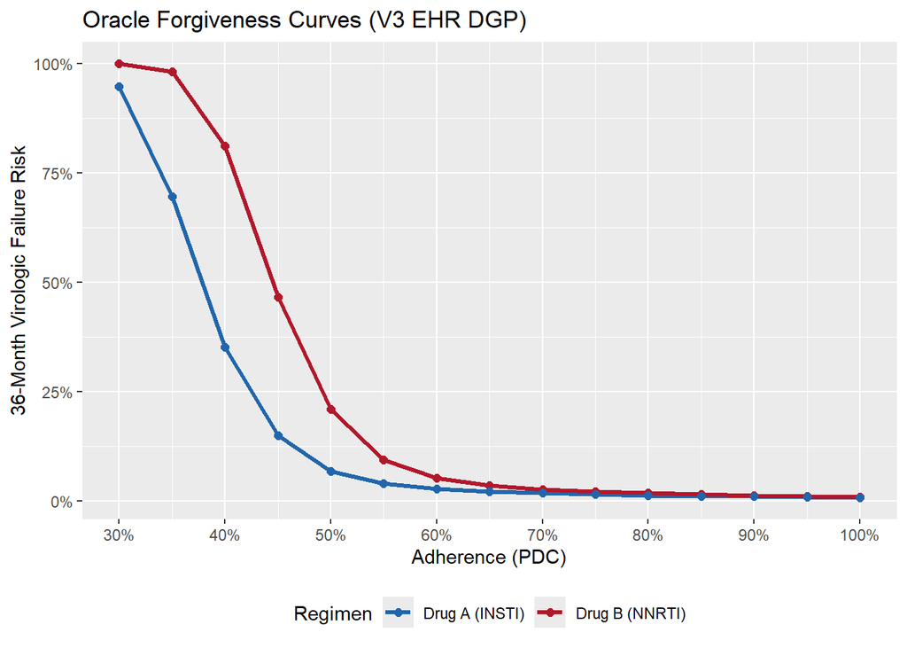

Figure 7: Oracle forgiveness curves from the V3 EHR DGP (continuous PDC, 36-month follow-up).

```r
ggplot(oracle_v3, aes(x = adh_target, y = cum_risk, color = drug)) +
  geom_line(linewidth = 1.2) + geom_point(size = 2) +
  scale_x_continuous(labels = scales::percent, breaks = seq(0.3, 1, 0.1)) +
  scale_y_continuous(labels = scales::percent) +
  scale_color_manual(values = drug_pal_v3) +
  labs(x = "Adherence (PDC)", y = "36-Month Virologic Failure Risk",
       color = "Regimen", title = "Oracle Forgiveness Curves (V3 EHR DGP)") +
  theme(legend.position = "bottom")
```

```r
oracle_v3_wide <- dcast(oracle_v3, adh_target ~ drug, value.var = "cum_risk")
setnames(oracle_v3_wide, c("PDC", "Drug A", "Drug B"))
oracle_v3_wide[, RD := `Drug A` - `Drug B`]
kable(oracle_v3_wide[PDC %in% seq(0.3, 1.0, 0.1)], digits = 3,
      caption = "V3 EHR oracle risks and risk differences at selected PDC levels") |>
  kable_styling(bootstrap_options = c("striped", "hover"), full_width = FALSE)
```

Table 14: V3 EHR oracle risks and risk differences at selected PDC levels

| PDC | Drug A | Drug B | RD |
| --- | --- | --- | --- |
| 0.3 | 0.948 | 1.000 | -0.052 |
| 0.4 | 0.351 | 0.812 | -0.461 |
| 0.5 | 0.068 | 0.209 | -0.141 |
| 0.6 | 0.027 | 0.052 | -0.025 |
| 0.7 | 0.018 | 0.027 | -0.009 |
| 0.8 | 0.013 | 0.018 | -0.005 |
| 0.9 | 0.010 | 0.013 | -0.003 |
| 1.0 | 0.008 | 0.009 | -0.002 |

## 10.3 Informative process diagnostics

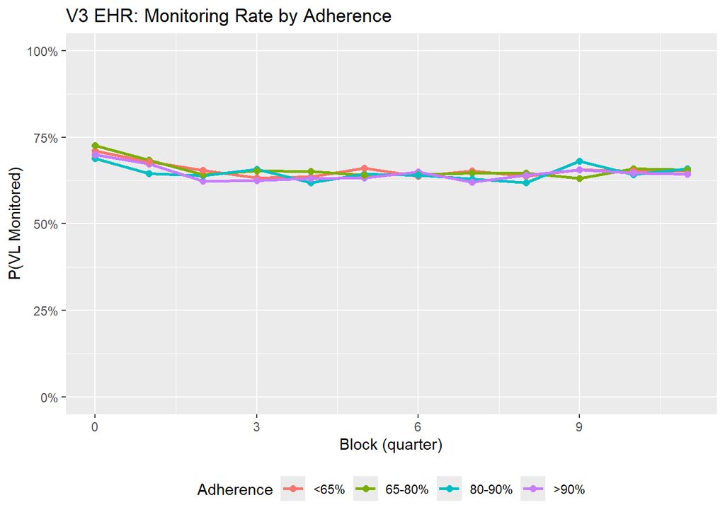

Figure 8: V3 EHR: monitoring probability by adherence level and block.

```r
mon_by_adh_v3 <- panel_v3[C == 0 & D == 0, .(
  mon_rate = mean(M, na.rm = TRUE), n = .N
), by = .(block, adh_cat = cut(PDC, breaks = c(-0.01, 0.65, 0.80, 0.90, 1.01),
                                 labels = c("<65%", "65-80%", "80-90%", ">90%")))]

ggplot(mon_by_adh_v3, aes(x = block, y = mon_rate, color = adh_cat)) +
  geom_line(linewidth = 1) + geom_point(size = 2) +
  scale_y_continuous(labels = scales::percent, limits = c(0, 1)) +
  labs(x = "Block (quarter)", y = "P(VL Monitored)", color = "Adherence",
       title = "V3 EHR: Monitoring Rate by Adherence") +
  theme(legend.position = "bottom")
```

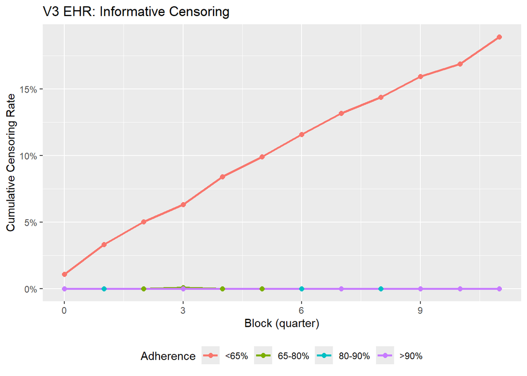

Figure 9: V3 EHR: cumulative censoring rate by adherence.

```r
cens_rate_v3 <- panel_v3[, .(
  cum_cens = mean(C), n = .N
), by = .(block, adh_cat = cut(PDC, breaks = c(-0.01, 0.65, 0.80, 0.90, 1.01),
                                 labels = c("<65%", "65-80%", "80-90%", ">90%")))]

ggplot(cens_rate_v3, aes(x = block, y = cum_cens, color = adh_cat)) +
  geom_line(linewidth = 1) + geom_point(size = 2) +
  scale_y_continuous(labels = scales::percent) +
  labs(x = "Block (quarter)", y = "Cumulative Censoring Rate", color = "Adherence",
       title = "V3 EHR: Informative Censoring") +
  theme(legend.position = "bottom")
```

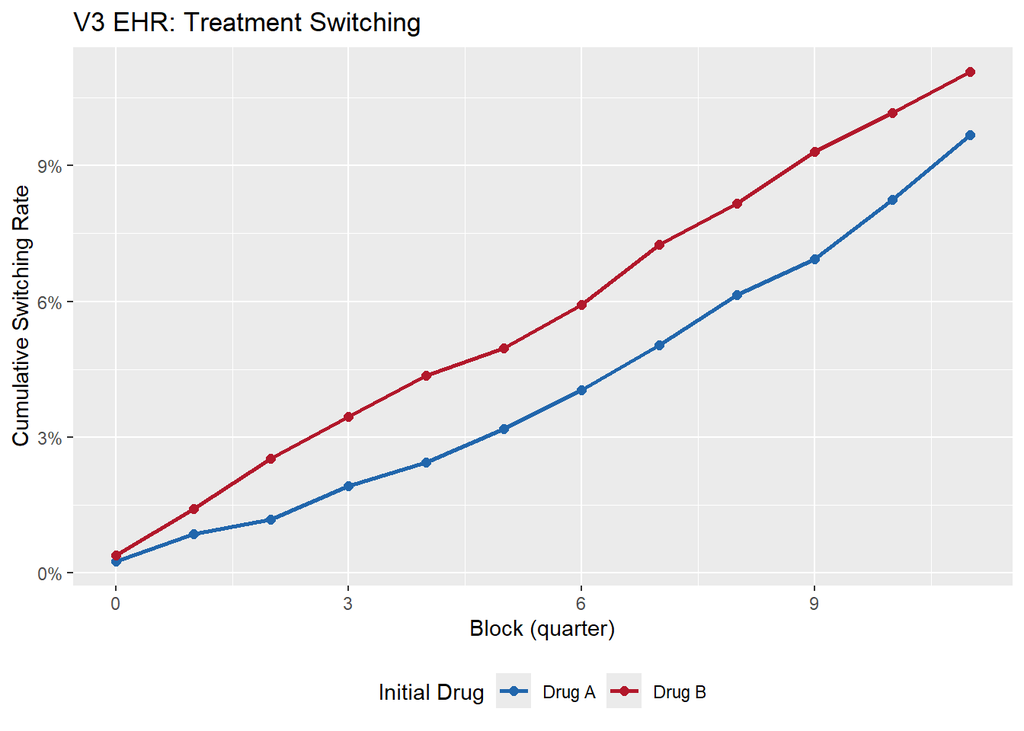

Figure 10: V3 EHR: cumulative switching rate by initial drug.

```r
switch_rate_v3 <- panel_v3[C == 0 & D == 0, .(
  cum_switch = mean(S), n = .N
), by = .(block, A0 = ifelse(A0 == 1, "Drug A", "Drug B"))]

ggplot(switch_rate_v3, aes(x = block, y = cum_switch, color = A0)) +
  geom_line(linewidth = 1) + geom_point(size = 2) +
  scale_y_continuous(labels = scales::percent) +
  scale_color_manual(values = c("Drug A" = "#2166AC", "Drug B" = "#B2182B")) +
  labs(x = "Block (quarter)", y = "Cumulative Switching Rate", color = "Initial Drug",
       title = "V3 EHR: Treatment Switching") +
  theme(legend.position = "bottom")
```

## 10.4 Naive analysis

```r
if (!is.null(naive_v3$contrasts)) {
  kable(naive_v3$contrasts, digits = 3,
        caption = "V3 EHR naive analysis: Drug A vs B risk differences by observed adherence stratum") |>
    kable_styling(bootstrap_options = c("striped", "hover"), full_width = FALSE)
}
```

Table 15: V3 EHR naive analysis: Drug A vs B risk differences by observed adherence stratum

| adh_cat | risk_A | risk_B | RD | RD_se | RD_ci_lo | RD_ci_hi | RR | n_A | n_B |
| --- | --- | --- | --- | --- | --- | --- | --- | --- | --- |
| low | 0.696 | 0.775 | -0.080 | 0.059 | -0.195 | 0.036 | 0.897 | 69 | 432 |
| medium | 0.611 | 0.758 | -0.147 | 0.014 | -0.174 | -0.120 | 0.806 | 2567 | 1849 |
| high | 0.471 | 0.500 | -0.029 | 0.264 | -0.547 | 0.489 | 0.941 | 34 | 4 |

## 10.5 LMTP-static estimates vs oracle

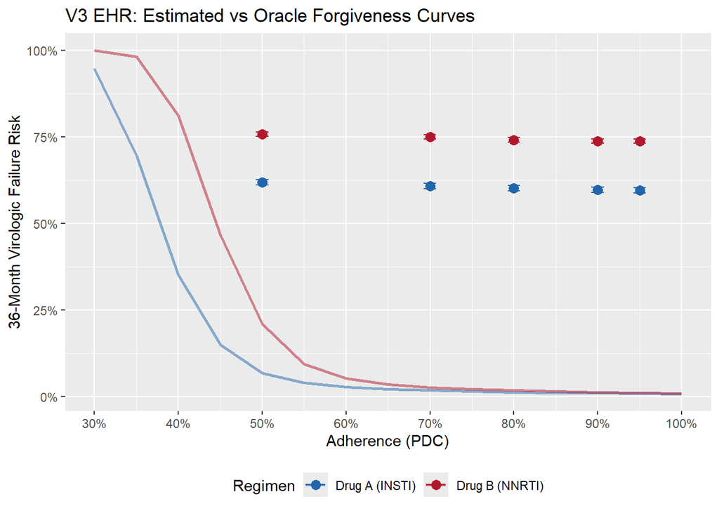

Figure 11: V3 EHR: LMTP-static estimates (points with ±1 SE) overlaid on oracle forgiveness curves.

```r
if (!is.null(lmtp_static_v3) && nrow(lmtp_static_v3) > 0) {
  lmtp_static_v3[, drug_full := ifelse(Drug == "Drug A",
                                        "Drug A (INSTI)", "Drug B (NNRTI)")]
  ggplot() +
    geom_line(data = oracle_v3, aes(x = adh_target, y = cum_risk, color = drug),
              linewidth = 1, alpha = 0.5) +
    geom_point(data = lmtp_static_v3,
               aes(x = PDC, y = Estimate, color = drug_full), size = 3) +
    geom_errorbar(data = lmtp_static_v3[!is.na(SE)],
                  aes(x = PDC, ymin = Estimate - SE, ymax = Estimate + SE,
                      color = drug_full), width = 0.015) +
    scale_color_manual(values = drug_pal_v3) +
    scale_x_continuous(labels = scales::percent, breaks = seq(0.3, 1, 0.1)) +
    scale_y_continuous(labels = scales::percent) +
    labs(x = "Adherence (PDC)", y = "36-Month Virologic Failure Risk",
         color = "Regimen",
         title = "V3 EHR: Estimated vs Oracle Forgiveness Curves") +
    theme(legend.position = "bottom")
}
```

```r
if (!is.null(lmtp_static_v3) && nrow(lmtp_static_v3) > 0) {
  display_cols <- intersect(c("Drug", "PDC", "Estimate", "Oracle", "Bias", "SE"),
                            names(lmtp_static_v3))
  kable(lmtp_static_v3[, ..display_cols], digits = 4,
        caption = "V3 EHR: LMTP-static estimates vs oracle truth") |>
    kable_styling(bootstrap_options = c("striped", "hover"), full_width = FALSE)
}
```

Table 16: V3 EHR: LMTP-static estimates vs oracle truth

| Drug | PDC | Estimate | Oracle | Bias | SE |
| --- | --- | --- | --- | --- | --- |
| Drug B | 0.50 | 0.7568 | 0.2088 | 0.5480 | 0.0061 |
| Drug B | 0.70 | 0.7497 | 0.0266 | 0.7231 | 0.0062 |
| Drug B | 0.80 | 0.7408 | 0.0175 | 0.7232 | 0.0064 |
| Drug B | 0.90 | 0.7375 | 0.0125 | 0.7250 | 0.0064 |
| Drug B | 0.95 | 0.7374 | 0.0109 | 0.7265 | 0.0061 |
| Drug A | 0.50 | 0.6181 | 0.0682 | 0.5499 | 0.0075 |
| Drug A | 0.70 | 0.6077 | 0.0175 | 0.5902 | 0.0076 |
| Drug A | 0.80 | 0.6020 | 0.0127 | 0.5893 | 0.0078 |
| Drug A | 0.90 | 0.5971 | 0.0099 | 0.5872 | 0.0080 |
| Drug A | 0.95 | 0.5950 | 0.0088 | 0.5862 | 0.0077 |

## 10.6 LMTP-shift results (+10pp PDC)

```r
if (!is.null(lmtp_shift_v3) && nrow(lmtp_shift_v3) > 0) {
  kable(lmtp_shift_v3, digits = 3,
        caption = "V3 EHR: LMTP shift results — effect of +10pp PDC increase by drug") |>
    kable_styling(bootstrap_options = c("striped", "hover"), full_width = FALSE)
}
```

Table 17: V3 EHR: LMTP shift results — effect of +10pp PDC increase by drug

| Drug | risk_natural | risk_shift | RD | RD_se | RD_ci_lo | RD_ci_hi |
| --- | --- | --- | --- | --- | --- | --- |
| Drug B | 0.762 | 0.752 | 0.010 | 0.005 | -0.001 | 0.020 |
| Drug A | 0.611 | 0.605 | 0.006 | 0.003 | 0.001 | 0.011 |

## 10.7 Quantile-mapping drug comparison

```r
if (!is.null(qmap_v3)) {
  qmap_display <- data.table(
    Estimand = c("Drug A, observed adherence", "Drug B, observed adherence",
      "Drug B, Drug A adherence (q-map)",
      "Effect of adherence shift on Drug B",
      "Residual drug difference (Drug A obs - Drug B shifted)"),
    Risk_or_RD = c(qmap_v3$risk_A_obs, qmap_v3$risk_B_obs, qmap_v3$risk_B_shifted,
      qmap_v3$RD_adherence_shift, qmap_v3$residual_pharmacologic),
    Interpretation = c("Failure risk under natural Drug A adherence",
      "Failure risk under natural Drug B adherence",
      "Failure risk if Drug B patients had Drug A adherence (same distribution in this DGP)",
      "Adherence-mediated component (near zero: both drugs have same adherence distribution)",
      "Residual pharmacologic forgiveness difference (dominates when adherence distributions overlap)"))

  kable(qmap_display, digits = 3,
        caption = "V3 EHR: Decomposing Drug A vs Drug B via quantile-mapped adherence (both drugs have the same adherence distribution in this DGP)") |>
    kable_styling(bootstrap_options = c("striped", "hover"), full_width = FALSE)
}
```

Table 18: V3 EHR: Decomposing Drug A vs Drug B via quantile-mapped adherence (both drugs have the same adherence distribution in this DGP)

| Estimand | Risk_or_RD | Interpretation |
| --- | --- | --- |
| Drug A, observed adherence | 0.611 | Failure risk under natural Drug A adherence |
| Drug B, observed adherence | 0.762 | Failure risk under natural Drug B adherence |
| Drug B, Drug A adherence (q-map) | 0.763 | Failure risk if Drug B patients had Drug A adherence (same distribution in this DGP) |
| Effect of adherence shift on Drug B | -0.001 | Adherence-mediated component (near zero: both drugs have same adherence distribution) |
| Residual drug difference (Drug A obs - Drug B shifted) | -0.152 | Residual pharmacologic forgiveness difference (dominates when adherence distributions overlap) |

## 10.8 Quantile-based adherence shift intervention

```r
# ── Node structure for LMTP on V3 EHR data ──────────────────────────
K_v3 <- length(grep("^PDC_", names(wide_v3)))
trt_nodes_v3 <- paste0("PDC_", 0:(K_v3 - 1))
outcome_nodes_v3 <- paste0("Y_", 0:(K_v3 - 1))
cens_nodes_v3 <- paste0("C_", 0:(K_v3 - 1))

baseline_v3 <- c("sex", "age_at_index", "msm", "cci",
                  "race_black", "race_hispanic",
                  "region_south", "region_midwest", "region_west", "A0")
baseline_nodrug_v3 <- setdiff(baseline_v3, "A0")

time_vary_v3 <- lapply(0:(K_v3 - 1), function(k) {
  tv <- c(paste0("VL_log10_locf_", k), paste0("CD4_locf_", k))
  for (extra in c("depression_", "substance_use_", "S_", "M_", "D_")) {
    col <- paste0(extra, k)
    if (col %in% names(wide_v3)) tv <- c(tv, col)
  }
  tv
})

baseline_cov_v3 <- c("age_at_index", "sex", "msm", "cci",
                      "race_black", "race_hispanic")
sl_lib_v3 <- c("SL.glm", "SL.mean")
```

```r
# Fit conditional quantile regressions for Drug A and Drug B
# at each time block and build the shift function
qmap_v3_detail <- load_cached("qmap_v3_ehr_detail", quote({
  library(quantreg)
  tau_grid_v3 <- seq(0.05, 0.95, by = 0.05)
  dt_qmap_v3 <- as.data.frame(copy(wide_v3))

  cqr_models_v3 <- list()
  for (k in 0:(K_v3 - 1)) {
    pdc_col <- paste0("PDC_", k)
    if (k == 0) {
      cov_cols <- baseline_cov_v3
    } else {
      cov_cols <- c(baseline_cov_v3,
                    paste0("VL_log10_locf_", k),
                    paste0("CD4_locf_", k),
                    paste0("PDC_", k - 1))
    }
    fmla <- as.formula(paste(pdc_col, "~", paste(cov_cols, collapse = " + ")))
    dat_A <- dt_qmap_v3[dt_qmap_v3$A0 == 1 & !is.na(dt_qmap_v3[[pdc_col]]), ]
    dat_B <- dt_qmap_v3[dt_qmap_v3$A0 == 0 & !is.na(dt_qmap_v3[[pdc_col]]), ]

    fits_A <- lapply(tau_grid_v3, function(tau) suppressWarnings(rq(fmla, tau = tau, data = dat_A)))
    fits_B <- lapply(tau_grid_v3, function(tau) suppressWarnings(rq(fmla, tau = tau, data = dat_B)))
    cqr_models_v3[[k + 1]] <- list(fits_A = fits_A, fits_B = fits_B)
  }

  # Shift function: map Drug B adherence to Drug A distribution
  shift_qmap_v3 <- function(data, trt) {
    k <- as.integer(gsub("PDC_", "", trt))
    a_obs <- data[[trt]]
    a_shifted <- a_obs
    is_b <- data$A0 == 0
    if (any(is_b)) {
      mods <- cqr_models_v3[[k + 1]]
      qmat_B <- sapply(mods$fits_B, function(fit) suppressWarnings(predict(fit, newdata = data[is_b, ])))
      qmat_A <- sapply(mods$fits_A, function(fit) suppressWarnings(predict(fit, newdata = data[is_b, ])))
      for (i in seq_len(nrow(qmat_B))) { qmat_B[i, ] <- sort(qmat_B[i, ]); qmat_A[i, ] <- sort(qmat_A[i, ]) }

      find_tau_v3 <- function(a_obs, qmat) {
        n <- length(a_obs); tau_out <- numeric(n)
        for (i in seq_len(n)) {
          qs <- qmat[i, ]
          if (a_obs[i] <= qs[1]) tau_out[i] <- tau_grid_v3[1]
          else if (a_obs[i] >= qs[length(qs)]) tau_out[i] <- tau_grid_v3[length(tau_grid_v3)]
          else tau_out[i] <- approx(qs, tau_grid_v3, xout = a_obs[i], rule = 2)$y
        }
        tau_out
      }

      tau_star <- find_tau_v3(a_obs[is_b], qmat_B)
      for (i in seq_len(sum(is_b))) {
        a_shifted[which(is_b)[i]] <- approx(tau_grid_v3, qmat_A[i, ], xout = tau_star[i], rule = 2)$y
      }
      a_shifted[is_b] <- pmax(0.01, pmin(0.99, a_shifted[is_b]))
    }
    a_shifted
  }

  # Run LMTP: Drug B observed vs shifted, Drug A observed
  sub_B <- dt_qmap_v3[dt_qmap_v3$A0 == 0, ]
  sub_A <- dt_qmap_v3[dt_qmap_v3$A0 == 1, ]

  fit_B_obs <- lmtp::lmtp_sdr(
    data = sub_B, trt = trt_nodes_v3, outcome = outcome_nodes_v3,
    baseline = baseline_nodrug_v3, time_vary = time_vary_v3, cens = cens_nodes_v3,
    shift = NULL, mtp = FALSE, outcome_type = "survival",
    learners_outcome = sl_lib_v3, learners_trt = sl_lib_v3, folds = 5)

  fit_B_shifted <- lmtp::lmtp_sdr(
    data = sub_B, trt = trt_nodes_v3, outcome = outcome_nodes_v3,
    baseline = baseline_nodrug_v3, time_vary = time_vary_v3, cens = cens_nodes_v3,
    shift = shift_qmap_v3, mtp = TRUE, outcome_type = "survival",
    learners_outcome = sl_lib_v3, learners_trt = sl_lib_v3, folds = 5)

  fit_A_obs <- lmtp::lmtp_sdr(
    data = sub_A, trt = trt_nodes_v3, outcome = outcome_nodes_v3,
    baseline = baseline_nodrug_v3, time_vary = time_vary_v3, cens = cens_nodes_v3,
    shift = NULL, mtp = FALSE, outcome_type = "survival",
    learners_outcome = sl_lib_v3, learners_trt = sl_lib_v3, folds = 5)

  contrast_qmap <- lmtp::lmtp_contrast(fit_B_shifted, ref = fit_B_obs, type = "additive")

  # Also capture the shifted adherence distributions for visualization
  shift_viz_blocks <- c(0, floor(K_v3/4), floor(K_v3/2), K_v3 - 1)
  viz_list <- lapply(shift_viz_blocks, function(k) {
    pdc_col <- paste0("PDC_", k)
    dat_k <- dt_qmap_v3[!is.na(dt_qmap_v3[[pdc_col]]), ]
    shifted_vals <- shift_qmap_v3(dat_k, pdc_col)
    data.table(
      block = k,
      PDC = c(dat_k[[pdc_col]][dat_k$A0 == 0],
              shifted_vals[dat_k$A0 == 0],
              dat_k[[pdc_col]][dat_k$A0 == 1]),
      Source = c(rep("Drug B observed", sum(dat_k$A0 == 0)),
                 rep("Drug B shifted", sum(dat_k$A0 == 0)),
                 rep("Drug A observed", sum(dat_k$A0 == 1))))
  })
  shift_viz_dt <- rbindlist(viz_list)

  list(
    risk_A_obs     = 1 - fit_A_obs$estimate@x,
    risk_B_obs     = 1 - fit_B_obs$estimate@x,
    risk_B_shifted = 1 - fit_B_shifted$estimate@x,
    RD_shift       = contrast_qmap$estimates$estimate,
    RD_se          = contrast_qmap$estimates$std.error,
    RD_ci_lo       = contrast_qmap$estimates$conf.low,
    RD_ci_hi       = contrast_qmap$estimates$conf.high,
    adherence_mediated     = (1 - fit_B_obs$estimate@x) - (1 - fit_B_shifted$estimate@x),
    residual_pharmacologic = (1 - fit_A_obs$estimate@x) - (1 - fit_B_shifted$estimate@x),
    shift_viz = shift_viz_dt)
}))
```

```r
if (!is.null(qmap_v3_detail)) {
  decomp_tbl <- data.table(
    Component = c(
      "Drug A risk (observed adherence)",
      "Drug B risk (observed adherence)",
      "Drug B risk (shifted to Drug A adherence)",
      "Adherence-mediated (Drug B obs - Drug B shifted)",
      "Residual pharmacologic (Drug A obs - Drug B shifted)",
      "Quantile-map shift RD (95% CI)"),
    Estimate = c(
      sprintf("%.3f", qmap_v3_detail$risk_A_obs),
      sprintf("%.3f", qmap_v3_detail$risk_B_obs),
      sprintf("%.3f", qmap_v3_detail$risk_B_shifted),
      sprintf("%+.4f", qmap_v3_detail$adherence_mediated),
      sprintf("%+.4f", qmap_v3_detail$residual_pharmacologic),
      sprintf("%+.4f (%.4f, %.4f)", qmap_v3_detail$RD_shift,
              qmap_v3_detail$RD_ci_lo, qmap_v3_detail$RD_ci_hi)))

  kable(decomp_tbl, caption = "Quantile-mapping decomposition: adherence-mediated vs residual pharmacologic") |>
    kable_styling(bootstrap_options = c("striped", "hover"), full_width = FALSE)
}
```

Table 19: V3 EHR: Quantile-mapping decomposition of the drug difference into adherence-mediated and residual pharmacologic components.

Quantile-mapping decomposition: adherence-mediated vs residual pharmacologic

| Component | Estimate |
| --- | --- |
| Drug A risk (observed adherence) | 0.611 |
| Drug B risk (observed adherence) | 0.768 |
| Drug B risk (shifted to Drug A adherence) | 0.766 |
| Adherence-mediated (Drug B obs - Drug B shifted) | +0.0020 |
| Residual pharmacologic (Drug A obs - Drug B shifted) | -0.1552 |
| Quantile-map shift RD (95% CI) | +0.0020 (-0.0043, 0.0083) |

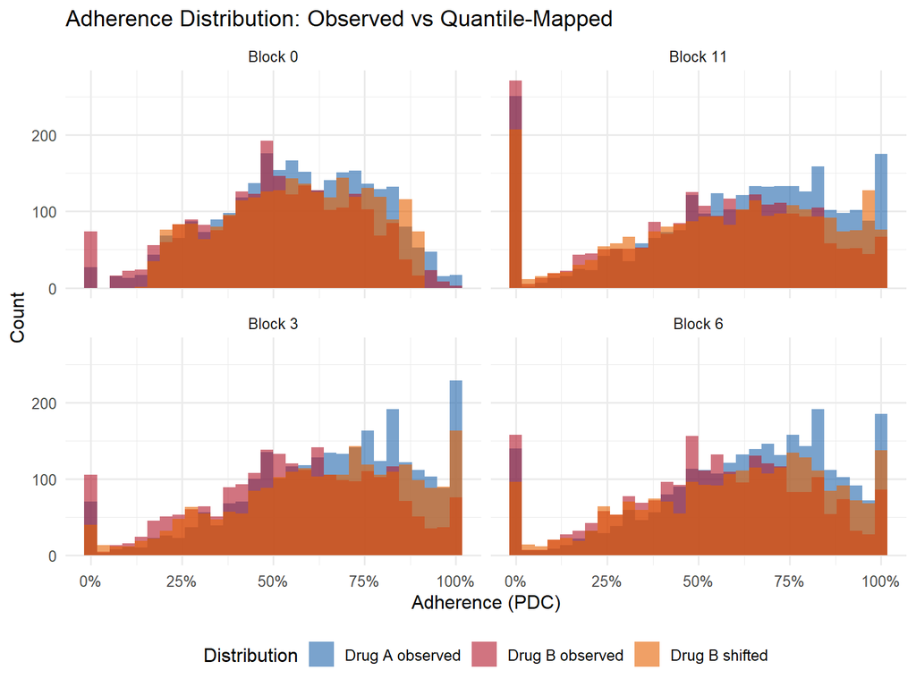

Figure 12: Observed Drug B adherence (red) vs shifted adherence using conditional quantile mapping (orange) vs observed Drug A adherence (blue) at selected blocks.

```r
if (!is.null(qmap_v3_detail) && !is.null(qmap_v3_detail$shift_viz)) {
  shift_pal <- c("Drug A observed" = "#2166AC",
                  "Drug B observed" = "#B2182B",
                  "Drug B shifted"  = "#E66100")

  ggplot(qmap_v3_detail$shift_viz, aes(x = PDC, fill = Source)) +
    geom_histogram(bins = 30, alpha = 0.6, position = "identity") +
    facet_wrap(~paste("Block", block), nrow = 2) +
    scale_fill_manual(values = shift_pal) +
    scale_x_continuous(labels = scales::percent) +
    labs(x = "Adherence (PDC)", y = "Count",
         fill = "Distribution",
         title = "Adherence Distribution: Observed vs Quantile-Mapped") +
    theme_minimal(base_size = 12) +
    theme(legend.position = "bottom")
}
```

## 10.9 Sensitivity: treatment-policy vs censor-at-switch

```r
if (!is.null(lmtp_shift_v3) && !is.null(cas_v3)) {
  tp <- copy(lmtp_shift_v3)
  tp[, Strategy := "Treatment-policy"]
  comparison <- rbind(
    tp[, .(Drug, Strategy, risk_natural, risk_shift, RD, RD_se, RD_ci_lo, RD_ci_hi)],
    cas_v3[, .(Drug, Strategy, risk_natural, risk_shift, RD, RD_se, RD_ci_lo, RD_ci_hi)])

  kable(comparison, digits = 3,
        caption = "V3 EHR: Treatment-policy vs censor-at-switch sensitivity") |>
    kable_styling(bootstrap_options = c("striped", "hover"), full_width = FALSE)
}
```

Table 20: V3 EHR: Treatment-policy vs censor-at-switch sensitivity

| Drug | Strategy | risk_natural | risk_shift | RD | RD_se | RD_ci_lo | RD_ci_hi |
| --- | --- | --- | --- | --- | --- | --- | --- |
| Drug B | Treatment-policy | 0.762 | 0.752 | 0.010 | 0.005 | -0.001 | 0.020 |
| Drug A | Treatment-policy | 0.611 | 0.605 | 0.006 | 0.003 | 0.001 | 0.011 |
| Drug B | Censor-at-switch | 0.760 | 0.752 | 0.008 | 0.004 | -0.001 | 0.016 |
| Drug A | Censor-at-switch | 0.611 | 0.605 | 0.006 | 0.003 | 0.000 | 0.011 |

## 10.10 Positivity: observed PDC distribution

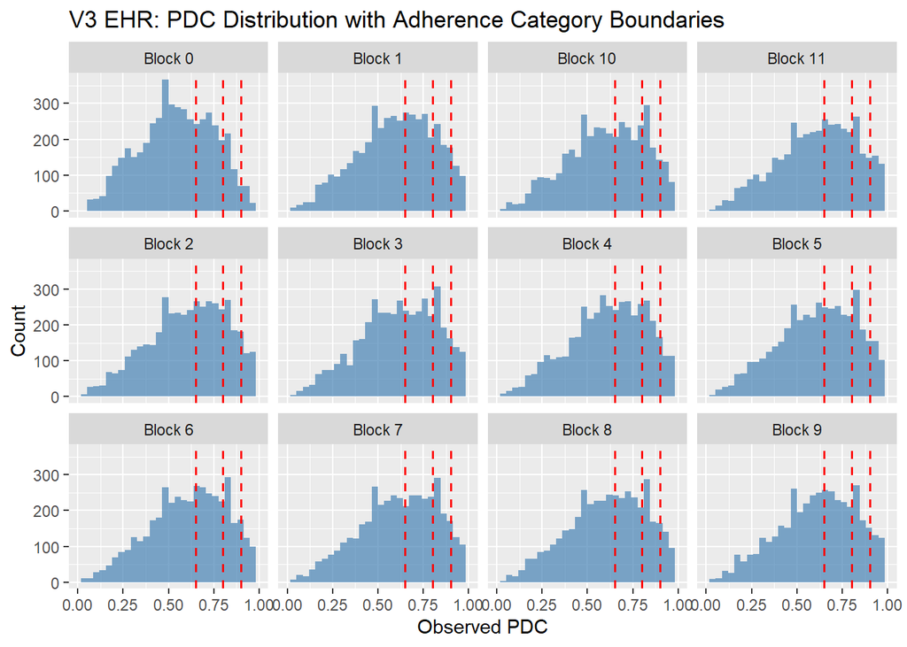

Figure 13: V3 EHR: Distribution of observed PDC by block with adherence category boundaries (0.65, 0.80, 0.90).

```r
pdc_long_v3 <- panel_v3[C == 0 & D == 0, .(PDC, block)]
ggplot(pdc_long_v3, aes(x = PDC)) +
  geom_histogram(bins = 30, fill = "steelblue", alpha = 0.7) +
  geom_vline(xintercept = c(0.65, 0.80, 0.90),
             linetype = "dashed", color = "red", linewidth = 0.7) +
  facet_wrap(~paste("Block", block), nrow = 3) +
  labs(x = "Observed PDC", y = "Count",
       title = "V3 EHR: PDC Distribution with Adherence Category Boundaries") +
  scale_x_continuous(limits = c(0, 1))
```

## 10.11 IPMW sensitivity for monitoring

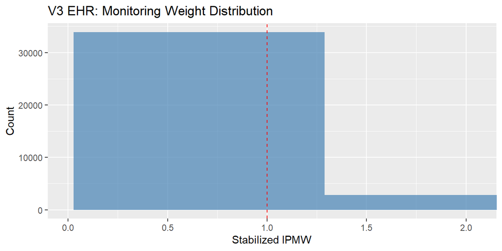

Figure 14: V3 EHR: Stabilised monitoring weights.

```r
if (!is.null(ipmw_v3)) {
  monitored_v3 <- ipmw_v3$panel_weighted[M == 1]
  ggplot(monitored_v3, aes(x = ipmw_stab)) +
    geom_histogram(bins = 50, fill = "steelblue", alpha = 0.7) +
    geom_vline(xintercept = 1, linetype = "dashed", color = "red") +
    labs(x = "Stabilized IPMW", y = "Count",
         title = "V3 EHR: Monitoring Weight Distribution") +
    coord_cartesian(xlim = c(0, quantile(monitored_v3$ipmw_stab, 0.99)))
}
```

# 11 Discussion

## 11.1 Summary and interpretation

Taken together, the results show that naive adherence-stratified analyses can overstate the apparent adherence–response relationship by conflating adherence with evolving health status. Longitudinal causal methods recover the intended adherence–response curve where the observed data provide adequate support. At adherence extremes, however, uncertainty increases substantially, and estimates become sensitive to limited support in the data.

Although the main text focuses on regimen-specific forgiveness as an adherence-response function, the same longitudinal intervention framework can also support comparative regimen questions. In particular, regimens may be compared under their natural adherence patterns or under a common adherence intervention, as illustrated here through a controlled-adherence secondary analysis. Informative monitoring, switching, and discontinuation introduce additional intercurrent longitudinal processes that are central in real-world HIV data; because they extend beyond the primary didactic objective of the present paper, we treat them as appendix-level methodological extensions rather than redesigning the main analysis around them.

In contrast, longitudinal g-methods recover the target parameter when their assumptions hold. LTMLE produces near-unbiased estimates at medium and high adherence, but performs differently at $z = 1$ where the static regime is weakly supported: at low adherence where the static regime is weakly supported, positivity constraints inflate LTMLE’s variance estimator (SE/SD $\approx$ 1.66 at $z = 1$), yielding conservative coverage at the cost of near-zero power. The point estimate remains near-unbiased even at $z = 1$, but the CIs are too wide to be informative at $n = 5{,}000$. This behaviour — near-zero bias with honest but wide uncertainty quantification — is LTMLE’s correct response to a causal question the data cannot adequately support. The influence-curve-based variance estimator is also materially conservative at medium and high adherence: nominal 95% CIs are functioning approximately as 98% intervals at $z = 2$ and 100% at $z = 3$. This conservatism affects interpretation of formal hypothesis tests: p-values will be inflated relative to what would be expected from a well-calibrated estimator. LMTP-static provides an alternative route to the same estimand but exhibits unstable inference when adherence trajectories are weakly represented in the data, particularly at medium and high adherence where density ratios become extreme. The LMTP shift estimator targets a different, feasible-policy estimand and shows the most stable finite-sample performance, with well-calibrated standard errors (SE/SD $\approx$ 1.05) and minimal bias. These results reinforce two points: first, valid estimation of forgiveness requires longitudinal adjustment for time-dependent confounding; and second, the choice of estimand must be aligned with the empirical support of the data.

Although the primary analysis is framed in terms of daily oral ART with categorical adherence, the underlying framework is more general. The key object is the intervention on a time-varying exposure, not the specific adherence metric. For long-acting injectable regimens, the adherence construct shifts from daily execution to injection timing or delay, but the causal estimand, identification assumptions, and estimation strategies remain unchanged. The injectable extension illustrates this mapping using a delay-based adherence process (see Section 13.9.1 and Section 13.9), showing how forgiveness curves can take a different functional form, with a flat region followed by a sharp increase in risk once delays exceed a pharmacologically meaningful threshold.

## 11.2 Choosing estimands and methods

The results highlight the importance of matching the estimand to the scientific question and the data structure. Static adherence regimes provide the most direct representation of the forgiveness curve and are appropriate when support is adequate across adherence trajectories. When support is limited, however, these estimands become sensitive to extrapolation, and feasible-policy estimands based on modified treatment policies offer a more stable and interpretable alternative (Díaz, Williams, et al. 2021, 2023). Continuous adherence measures, such as PDC, further expand the set of meaningful interventions by allowing incremental shifts rather than discrete categories. In practice, static-regime and shift-policy analyses are best viewed as complementary: the former defines the theoretical adherence–response curve, while the latter answers policy-relevant questions about achievable improvements.

For the main forgiveness-curve analysis, the risk difference is the most stable contrast measure, especially when one or both risks approach the boundary near zero, because division amplifies estimation noise and risk ratios become unstable. A marginal structural model can still be useful as a secondary summary, providing a compact description of the adherence–response gradient and the regimen-by-adherence interaction, but it should be interpreted as a projection of the estimated causal curve rather than as a substitute for the nonparametric target parameter (Rosenblum and Laan 2010; Petersen et al. 2014).

## 11.3 Scope and extensions

The primary focus of this tutorial is the estimation of forgiveness curves under time-varying adherence in a simplified oral-ART setting. Additional components, including delivery-system comparisons, informative monitoring, censoring, and treatment switching, are presented as extensions to illustrate how the same causal framework generalises to more complex real-world data structures. These extensions are not part of the primary Monte Carlo evaluation but instead show how the node structure, estimands, and estimation strategy can be adapted when the data-generating process includes additional sources of bias or missingness (see Section 13.10).

In particular, the delivery-system extension highlights how differences between oral and injectable regimens can be decomposed into execution-related and residual effects. This reflects a broader shift in modern ART research, where differences between regimens increasingly arise from adherence processes and delivery mechanisms rather than efficacy under perfect adherence. The framework presented here provides a unified way to formalise and estimate these comparisons.

## 11.4 Stylization and limitations

Several simplifications and limitations should be noted explicitly. First, adherence is represented using a simplified three-level ordinal variable ($Z_t \in \{1, 2, 3\}$) rather than continuous PDC; this reduces computational complexity and illustrates the core methods, but may obscure finer-grained variation. Continuous PDC, as discussed in Section 6.5, is more flexible but requires density-ratio estimation for the LMTP machinery. Second, the primary analysis assumes complete outcome ascertainment: every patient’s virologic failure status is observed at each block without informative monitoring. Real applications require handling the masking of failures in unmonitored periods, and this complication is discussed in Section 13.10.2 (appendix extension). Third, drug assignment is randomised 1:1 in the simulation; real observational settings require additional baseline confounding adjustment via propensity weighting or other methods, in addition to the longitudinal adjustment that is the primary focus here.

Fourth, the treatment-confounder feedback structure and the forgiveness differential are intentionally visible for pedagogic clarity. The low-adherence risk difference between drugs (approximately -0.11 on the risk-difference scale) remains somewhat stylized compared to modern INSTI-versus-comparator settings, where pharmacologic differences at suboptimal adherence are more modest. The DGP was revised in V13 to substantially reduce earlier over-amplification of failure rates at low adherence, while retaining a visible forgiveness differential sufficient for pedagogic demonstration. Fifth, the bias of the naive estimator depends on DGP parameterization: this paper illustrates one configuration where naive RD bias is moderate and visible at low adherence, driven by strong health-to-adherence feedback ($\beta_{Z \leftarrow L} = 0.80$) with adherence history encoded implicitly through the $L_t$ AR(1) process ($\beta_{Y \leftarrow \bar{Z}} = 0$). Naive RR bias is more severe. In configurations with larger forgiveness differentials, additional unmeasured confounders, or different adherence distributions, naive RD bias could be substantially larger.

Beyond these DGP-specific simplifications, several general limitations apply. The implementation uses logistic regression (`SL.glm`) as the sole nuisance model for transparency; applied analyses should use richer SuperLearner libraries. Finite-sample variability remains substantial when adherence trajectories are weakly supported, and cross-validated TMLE is one possible extension for improving finite-sample performance (Zheng and Laan 2011). The injectable extension is illustrative rather than pharmacokinetically calibrated; real applications would require delay distributions and hazard models informed by empirical pharmacokinetic studies.

These simplifications were deliberate. They allow the tutorial to focus on the core statistical problem — the distinction between associational and interventional estimands under treatment-confounder feedback — while showing in the appendix how the same framework extends to more realistic observational settings. This DGP is intended to reflect the qualitative structure of modern HIV care; future work should calibrate these mechanisms to specific cohort or trial data. Among these extensions, incorporating informative monitoring and applying the framework to long-acting injectable therapies are likely to have the greatest immediate impact in applied HIV research.

## 11.5 Sensitivity to unmeasured confounding

Identification of the causal estimand relies on sequential exchangeability, which is unlikely to hold exactly in observational HIV data. Important drivers of adherence and outcomes, such as mental health, housing instability, and substance use, are often incompletely measured. When these factors are unobserved, estimated forgiveness curves may be biased. Sensitivity analyses are therefore essential in applied work. E-values provide a simple summary of robustness to unmeasured confounding (VanderWeele and Ding 2017), while longitudinal bounding approaches can account for the accumulation of bias over time (Robins and Richardson 2010). Negative control outcomes offer an empirical check: if an adherence effect is detected for an outcome that adherence cannot plausibly influence, residual confounding is likely present.

These sensitivity analyses are not implemented in the current tutorial because the simulation satisfies sequential exchangeability by construction. In real-world applications, however, they should be considered part of a minimum diagnostic framework for interpreting estimated forgiveness curves.

## 11.6 Practical implications for applied analyses

For applied analysts, the main practical lesson is that positivity should be assessed before choosing an estimator. When sustained adherence regimes have adequate support, LTMLE provides a direct route to the target forgiveness curve. When support is weak, LMTP shift interventions offer a more stable alternative that remains clinically interpretable. This distinction is especially important in real-world HIV data, where adherence trajectories are heterogeneous and persistent high or low adherence paths may be rare.

More broadly, the relevant scientific question should determine the estimand. If the goal is to compare regimen robustness under sustained adherence levels, the forgiveness curve is the appropriate target. If the goal is to evaluate the likely impact of adherence improvement programmes, feasible-policy estimands based on LMTP are often more relevant. The same logic extends beyond daily oral ART to treatment settings in which execution is replaced by attendance, persistence, or timing, including long-acting injectable regimens.

**Practical recommendations for applied analysts**

Based on the Monte Carlo results in this tutorial, the following guidelines apply when choosing between estimation strategies for forgiveness curves:

- **Use LTMLE for static-regime forgiveness curves** when path support for the target adherence trajectory exceeds approximately 5–10% of the observed data. LTMLE provides low bias and honest (if somewhat conservative) variance estimates under these conditions.
- **Use LMTP-shift for feasible intervention questions** and when static-regime path support is thin. The shift estimator consistently achieved SE/SD $\approx$ 1.05 and 97% empirical coverage in these simulations.
- **Do NOT use LMTP-static as a default robustness check.** LMTP-static produced SE/SD as low as 0.071 at $z = 2$, yielding only 11% empirical coverage. Relying on LMTP-static p-values for significance testing at medium or high adherence would produce severely inflated type I error rates.
- **Always inspect weight distributions and effective sample size** (see Section 13.6) before interpreting static-regime estimates. Extreme cumulative weights (e.g., max weight > 1,000 or ESS/n < 0.30) indicate practical positivity strain and should trigger a shift to LMTP-shift or a sensitivity analysis with weight truncation.

# 12 Conclusion

Regimen forgiveness, the ability of an ART regimen to maintain viral suppression despite imperfect adherence, is a causal property of the treatment-adherence-outcome system, not an observable characteristic that can be read off from adherence-stratified outcome data. Estimating forgiveness therefore requires methods that account for the feedback between clinical status, adherence, and virologic outcomes over time.

This tutorial provides a complete workflow following the causal roadmap: from scientific question to causal estimand, to identified statistical target parameter $\Psi(P_0)$, to targeted estimator. The primary analysis uses LTMLE to estimate static-regime forgiveness curves, with LMTP used both as a complementary feasible-policy approach and as a framework that generalises naturally to continuous adherence measures and alternative treatment modalities. The Monte Carlo study illustrates that the relationship between naive and causal estimates is DGP-dependent: even under strong health-to-adherence feedback ($Z\_\beta\_L = 0.80$) with no explicit cumulative-history term ($Y\_\beta\_{\bar{Z}} = 0$; history encoded implicitly through the $L_t$ AR(1) process), naive RD estimates show moderate but non-negligible bias driven by structural features of the feedback loop, while LTMLE and LMTP-shift recover the target parameter with better-calibrated inference when their assumptions are met.

While demonstrated here primarily with daily oral ART, the framework applies more broadly to treatment settings in which effectiveness depends on time-varying adherence or execution. For long-acting injectables, the adherence construct shifts from daily pill-taking to injection timing, but the causal structure, identification assumptions, and estimation strategies carry over directly (see Section 13.9.1 and Section 13.9 for an illustrative extension).

## 12.1 References

# 13 Appendix

## 13.1 ICH E9(R1) estimand attributes

For regulatory-oriented readers, the static-intervention forgiveness estimand can be expressed in terms of the five attributes specified by International Council for Harmonisation (2019):

| Attribute | Specification |
| --- | --- |
| Population | Adult PLWH initiating or maintaining ART |
| Treatment | Regimen $A_0$ (Drug A or Drug B) under forced adherence $\bar{Z} = \bar{z}$ |
| Endpoint | Virologic failure (VL ≥200 copies/mL) by 48 weeks |
| Summary measure | Cumulative incidence $\psi(a_0, z) = P(Y_K^{a_0, \bar{z}} = 1)$ |
| Intercurrent event strategy | Treatment-policy (adherence lapses handled via the forced-regime intervention) |

## 13.2 Identification assumptions

### 13.2.1 Consistency (SUTVA)

If $A_0 = a_0$ and $\bar{Z}_t = \bar{z}_t$, then $Y_t^{a_0, \bar{z}} = Y_t$. This assumes no interference between patients and a well-defined intervention.

### 13.2.2 Sequential exchangeability

$$Y_K^{a_0, \bar{z}} \perp\!\!\!\perp Z_t \mid \bar{L}_t, \bar{Z}_{t-1}, A_0, W \quad \forall t$$

This is the “no unmeasured confounders” assumption, conditional on the measured time-varying and baseline covariates. In real-world HIV data, sequential exchangeability may be threatened by incompletely measured behavioral and structural determinants of adherence, including mental health, stigma, unstable housing, and care disruption. As a result, valid causal interpretation depends on the extent to which available covariates adequately capture these processes.

### 13.2.3 Positivity

$$P(Z_t = z \mid \bar{L}_t = \bar{l}_t, \bar{Z}_{t-1} = \bar{z}_{t-1}, A_0 = a_0, W = w) > 0$$

for all $(t, z, \bar{l}_t, \bar{z}_{t-1}, a_0, w)$ in the support. This is checked empirically in Section 13.4.

## 13.3 Simulated cohort details

### 13.3.1 DGP parameters

```r
dgp_p <- attr(dat, "dgp_params")
param_table <- data.frame(
  Parameter = c(
    "Drug assignment probability",
    "Baseline severity prevalence",
    "Baseline depression prevalence",
    "L_t AR(1) persistence",
    "L_t effect of prior Z",
    "Z_t effect of L_t (health -> adherence)",
    "Z_t effect of drug (Drug B side effects)",
    "Z_t depression effect",
    "Y_t baseline log-odds",
    "Y_t low-adherence penalty",
    "Y_t medium-adherence penalty",
    "Y_t effect of health L_t",
    "Y_t effect of cumulative mean adherence",
    "Y_t Drug A direct effect",
    "Y_t Drug A x low-adherence forgiveness",
    "Y_t Drug A x medium-adherence forgiveness"
  ),
  Symbol = c(
    "P(A0=1)", "P(W_sev)", "P(W_dep)",
    "L_ar", "L_beta_Z", "Z_beta_L", "Z_beta_A0", "Z_beta_dep",
    "Y_int", "Y_beta_Z_low", "Y_beta_Z_med",
    "Y_beta_L", "Y_beta_Zbar",
    "Y_beta_A0", "Y_beta_forgive_low", "Y_beta_forgive_med"
  ),
  Value = c(
    dgp_p$a0_prob, dgp_p$sev_prob, dgp_p$dep_prob,
    dgp_p$L_ar, dgp_p$L_beta_Z, dgp_p$Z_beta_L, dgp_p$Z_beta_A0, dgp_p$Z_beta_dep,
    dgp_p$Y_int, dgp_p$Y_beta_Z_low, dgp_p$Y_beta_Z_med,
    dgp_p$Y_beta_L, dgp_p$Y_beta_Zbar,
    dgp_p$Y_beta_A0, dgp_p$Y_beta_forgive_low, dgp_p$Y_beta_forgive_med
  ),
  stringsAsFactors = FALSE
)
kable(param_table, digits = 2, align = "llr") |>
  kable_styling(bootstrap_options = c("striped", "condensed"), full_width = FALSE,
                font_size = 11)
```

Table 21: Key parameters of the oral-ART forgiveness DGP.

| Parameter | Symbol | Value |
| --- | --- | --- |
| Drug assignment probability | P(A0=1) | 0.50 |
| Baseline severity prevalence | P(W_sev) | 0.30 |
| Baseline depression prevalence | P(W_dep) | 0.25 |
| L_t AR(1) persistence | L_ar | 0.50 |
| L_t effect of prior Z | L_beta_Z | 0.30 |
| Z_t effect of L_t (health -> adherence) | Z_beta_L | 0.80 |
| Z_t effect of drug (Drug B side effects) | Z_beta_A0 | 0.40 |
| Z_t depression effect | Z_beta_dep | -0.50 |
| Y_t baseline log-odds | Y_int | -4.20 |
| Y_t low-adherence penalty | Y_beta_Z_low | 1.25 |
| Y_t medium-adherence penalty | Y_beta_Z_med | 0.60 |
| Y_t effect of health L_t | Y_beta_L | -0.80 |
| Y_t effect of cumulative mean adherence | Y_beta_Zbar | 0.00 |
| Y_t Drug A direct effect | Y_beta_A0 | -0.10 |
| Y_t Drug A x low-adherence forgiveness | Y_beta_forgive_low | -0.38 |
| Y_t Drug A x medium-adherence forgiveness | Y_beta_forgive_med | -0.20 |

### 13.3.2 Baseline characteristics

```r
base_tab <- data.frame(
  Characteristic = c("N", "Drug A (more forgiving), %",
                     "Age, mean (sd)", "Low CD4 / severity, %",
                     "Depression, %", "Prior instability, %"),
  Value = c(
    nrow(dat),
    sprintf("%.1f", 100 * mean(dat$A0)),
    sprintf("%.2f (%.2f)", mean(dat$W_age), sd(dat$W_age)),
    sprintf("%.1f", 100 * mean(dat$W_sev)),
    sprintf("%.1f", 100 * mean(dat$W_dep)),
    sprintf("%.1f", 100 * mean(dat$W_instab))
  ),
  stringsAsFactors = FALSE
)
kable(base_tab, align = "lr") |>
  kable_styling(bootstrap_options = c("striped", "condensed"), full_width = FALSE)
```

Table 22: Baseline characteristics of the simulated cohort.

| Characteristic | Value |
| --- | --- |
| N | 20000 |
| Drug A (more forgiving), % | 50.5 |
| Age, mean (sd) | 0.01 (1.00) |
| Low CD4 / severity, % | 29.6 |
| Depression, % | 24.6 |
| Prior instability, % | 19.6 |

### 13.3.3 Adherence distribution over time

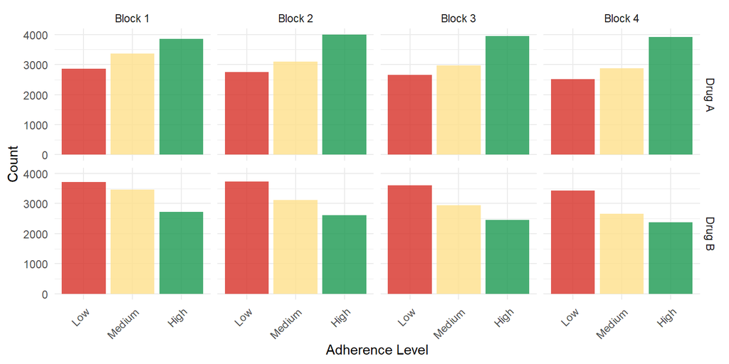

Figure 15: Adherence distribution by drug arm and time block.

```r
z_long <- do.call(rbind, lapply(seq_len(K), function(t) {
  z_col <- paste0("Z_", t)
  data.frame(
    block = t,
    arm = ifelse(dat$A0 == 1, "Drug A", "Drug B"),
    adherence = factor(dat[[z_col]], levels = 1:3,
                       labels = c("Low", "Medium", "High")),
    stringsAsFactors = FALSE
  )
}))
z_long <- z_long[!is.na(z_long$adherence), ]

ggplot(z_long, aes(x = adherence, fill = adherence)) +
  geom_bar(alpha = 0.8) +
  facet_grid(arm ~ paste0("Block ", block)) +
  scale_fill_manual(values = c("Low" = "#D73027", "Medium" = "#FEE08B",
                                "High" = "#1A9850"), guide = "none") +
  labs(x = "Adherence Level", y = "Count") +
  theme_minimal(base_size = 11) +
  theme(axis.text.x = element_text(angle = 45, hjust = 1))
```

### 13.3.4 Cumulative virologic failure

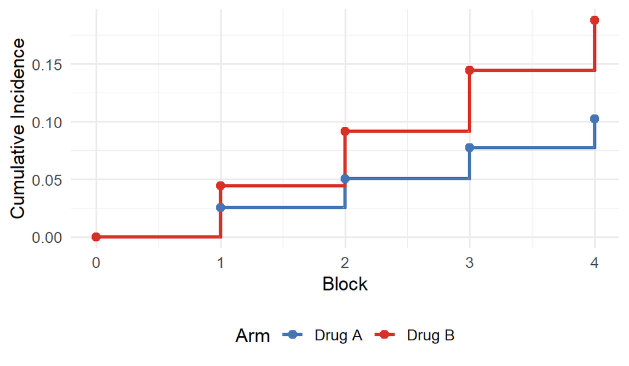

Figure 16: Observed cumulative incidence of virologic failure by arm.

```r
cum_fail <- data.frame(
  block = rep(0:K, 2),
  arm = rep(c("Drug A", "Drug B"), each = K + 1),
  cum_inc = c(
    0, sapply(1:K, function(t)
      mean(rowSums(dat[dat$A0 == 1, paste0("Y_", 1:t), drop = FALSE],
                   na.rm = TRUE) > 0)),
    0, sapply(1:K, function(t)
      mean(rowSums(dat[dat$A0 == 0, paste0("Y_", 1:t), drop = FALSE],
                   na.rm = TRUE) > 0))
  )
)

ggplot(cum_fail, aes(x = block, y = cum_inc, color = arm, group = arm)) +
  geom_step(linewidth = 1.1) +
  geom_point(size = 2.5) +
  scale_color_manual(values = c("Drug A" = "#4575B4", "Drug B" = "#D73027")) +
  labs(x = "Block", y = "Cumulative Incidence", color = "Arm") +
  theme_minimal(base_size = 13) +
  theme(legend.position = "bottom") +
  coord_cartesian(ylim = c(0, NA))
```

### 13.3.5 Oracle counterfactual risks

```r
if (!is.null(oracle_truth)) {
  ot <- oracle_truth
  ot$arm <- ifelse(ot$a0 == 1, "Drug A", "Drug B")
  ot$adherence <- c("Low", "Medium", "High", "Low", "Medium", "High",
                     "Shift +1", "Shift +1")[match(ot$z_target,
                     c("1","2","3","1","2","3","shift","shift"))]
  kable(ot[, c("arm", "adherence", "cum_risk_oracle")],
        digits = 4,
        col.names = c("Arm", "Adherence Regime", "Oracle Risk"),
        align = "llr") |>
    kable_styling(bootstrap_options = c("striped", "condensed"), full_width = FALSE)
}
```

Table 23: Oracle counterfactual risks under forced adherence regimes (known DGP).

|  | Arm | Adherence Regime | Oracle Risk |
| --- | --- | --- | --- |
| DrugA_z1 | Drug A | Low | 0.1799 |
| DrugA_z2 | Drug A | Medium | 0.0938 |
| DrugA_z3 | Drug A | High | 0.0527 |
| DrugB_z1 | Drug B | Low | 0.2940 |
| DrugB_z2 | Drug B | Medium | 0.1385 |
| DrugB_z3 | Drug B | High | 0.0646 |
| DrugA_shift | Drug A | Shift +1 | 0.0632 |
| DrugB_shift | Drug B | Shift +1 | 0.0923 |

The oracle risks confirm the built-in forgiveness mechanism: at high adherence, both drugs perform similarly; at low adherence, Drug B’s risk increases much more sharply than Drug A’s.

## 13.4 Positivity Diagnostics

Before estimating risks under forced adherence regimes, we check whether the data provide adequate support. Positivity, the requirement that every adherence level has positive probability given measured covariates at each time point, is the identification assumption most likely to be strained in practice, and violations are the leading cause of unreliable causal estimates in longitudinal analyses.

### 13.4.1 Structural versus practical positivity

Two types of positivity problems arise in practice:

- **Structural positivity violations** occur when some adherence levels are impossible for certain patients by design (e.g., a patient who has been hospitalised cannot fill a prescription that month). These are intrinsic to the data structure and cannot be resolved by collecting more data.
- **Practical positivity violations** occur when adherence levels are theoretically possible but observed so rarely that estimation depends on extreme model-based extrapolation. For example, maintaining constant high adherence across all four 90-day blocks may be structurally possible for any given patient, but the fraction of patients who actually do so can be small.

For static adherence interventions, practical positivity becomes increasingly challenging as the number of time points $K$ grows. Even if the marginal probability of adhering at level $z$ at any single block is reasonable (say 25%), the probability of maintaining that level across all $K = 4$ blocks decays as roughly $0.25^4 \approx 0.4\%$. This multiplicative erosion of support is the fundamental reason that static adherence regimes become fragile over extended follow-up. When very few individuals in the observed data follow a given low-adherence path while remaining under observation, estimation for that regime relies heavily on extrapolation rather than interpolation. In practical terms, the model must guess what would happen under adherence patterns that are rarely or never observed. This limitation is intrinsic to the data, not a failure of the estimator.

### 13.4.2 Adherence path support

For a constant-adherence regime $\bar{z} = (z, z, z, z)$, we need patients who maintain the same adherence level across all $K$ blocks. Table 24 shows the fraction who do so.

```r
path_support <- do.call(rbind, lapply(0:1, function(a0) {
  sub <- dat[dat$A0 == a0, ]
  drug <- ifelse(a0 == 1, "Drug A", "Drug B")
  do.call(rbind, lapply(1:3, function(z) {
    z_cols <- paste0("Z_", 1:K)
    z_mat <- as.matrix(sub[, z_cols])
    # Fraction where all non-NA values equal z
    all_z <- apply(z_mat, 1, function(row) {
      vals <- row[!is.na(row)]
      length(vals) > 0 && all(vals == z)
    })
    data.frame(Arm = drug,
               Adherence = c("Low", "Medium", "High")[z],
               N_constant = sum(all_z),
               Fraction = round(mean(all_z), 3),
               stringsAsFactors = FALSE)
  }))
}))

kable(path_support, align = "llrr") |>
  kable_styling(bootstrap_options = c("striped", "condensed"), full_width = FALSE)
```

Table 24: Fraction of patients maintaining constant adherence across all K blocks, by arm.

| Arm | Adherence | N_constant | Fraction |
| --- | --- | --- | --- |
| Drug B | Low | 1130 | 0.114 |
| Drug B | Medium | 318 | 0.032 |
| Drug B | High | 396 | 0.040 |
| Drug A | Low | 480 | 0.048 |
| Drug A | Medium | 247 | 0.024 |
| Drug A | High | 911 | 0.090 |

### 13.4.3 From weak support to estimator instability

When path support is low, both LTMLE and LMTP-static are forced to rely heavily on modelling assumptions. The practical consequences include:

- **Variance inflation.** LTMLE’s clever covariates (the “targeting” step) involve dividing by estimated adherence probabilities. When those probabilities are near zero, the resulting weights are large and the variance of the estimated risk increases sharply, analogous to the well-known problem of extreme inverse-probability weights in cross-sectional propensity score analyses, but compounded across time points.
- **Extrapolation.** The outcome model must predict risks for adherence-covariate combinations that are rarely or never observed. If the model is misspecified (e.g., a linear model applied to a nonlinear relationship), extrapolation errors are amplified.
- **Sensitivity to modelling choices.** Under strong positivity, different reasonable model specifications tend to give similar answers. Under weak positivity, estimates can change substantially with minor changes to the nuisance model (e.g., adding an interaction term, changing the Super Learner library).
- **Weight truncation as a diagnostic.** Truncating inverse-probability weights at a specified percentile (e.g., the 99th) and comparing truncated to untruncated estimates provides a practical sensitivity check: if the estimates change substantially under truncation, the untruncated estimate is driven by a small number of high-weight observations and should be treated with caution. Note that truncation introduces bias in exchange for variance reduction and should not be used as the primary analysis; its role is diagnostic.

### 13.4.4 Practical limitations of static adherence regimes

The positivity challenges of static adherence regimes reflect a deeper conceptual issue. Adherence is not a treatment that clinicians directly assign; it is a behaviour shaped by patient circumstances, drug tolerability, and health status. Asking “what would happen if every patient maintained high adherence for a full year?” posits an intervention that has no clear real-world implementation, no adherence programme can guarantee 100% compliance. In practice, the static adherence interventions in this tutorial should be interpreted not as literal deterministic control of each patient’s pill-taking, but as simplified representations of *adherence-support environments*, clinical contexts in which stronger adherence support (e.g., more consistent pharmacy refill coverage, integrated mental health care, peer navigation programmes) sustains adherence at a specified level. No real programme perfectly fixes adherence to one exact category at every period, but the static regime provides the idealised causal contrast needed to define the forgiveness curve: how much does outcome risk change as the adherence environment shifts from one level to another? The LMTP shift policy (Section 6) complements this by moving closer to a realistic intervention target.

These considerations motivate the complementary LMTP shift-policy approach (Section 6), which defines interventions *relative to* each patient’s observed adherence, e.g., “improve adherence by one level”, so that the shifted value is always near the observed support.

## 13.5 Practical guidance: when to shift from static regimes to feasible policies:

- If constant-path support for any regime drops below 5%, interpret the static-regime estimate cautiously and compare it to the LMTP-shift result.
- If the LTMLE standard error for a regime is more than twice the SE of the LMTP-shift estimate, positivity strain is likely driving the instability.
- When support is adequate (>10% path support, stable SEs), the static-regime forgiveness curve is preferable because it directly answers the regimen-comparison question.
- When support is thin, the LMTP shift policy provides a more stable and empirically grounded answer to a related but feasible clinical question.
- For quantitative positivity diagnostics beyond path-support fractions, including effective sample size and cumulative weight distributions, see Section 13.6.

## 13.6 Additional positivity diagnostics

The main positivity assessment (Section 13.4) examines adherence-path support by tabulating how many patients follow each adherence trajectory. This appendix subsection provides two complementary diagnostics: effective sample size (ESS) and cumulative inverse-probability weight distributions.

### 13.6.1 Effective sample size

ESS summarises how much information the data effectively contribute to each regime-specific estimate once the implied weights are accounted for. When positivity is strained, a few patients receive very large weights, concentrating the estimate on a small fraction of the sample. We approximate ESS using inverse-probability-of-treatment (IPTW) weights computed from the same multinomial logistic g-models used by the LTMLE analysis.

```r
# Compute crude cumulative IP weights for each static regime
# using multinomial logistic regression for P(Z_t | L_t, Z_{t-1}, A0, W)
if (exists("dat") && !is.null(dat)) {
  K <- 4
  ess_rows <- list()

  for (a0 in 0:1) {
    drug_label <- ifelse(a0 == 1, "Drug A", "Drug B")
    sub <- dat[dat$A0 == a0, ]
    n_arm <- nrow(sub)

    for (z_target in 1:3) {
      z_label <- c("Low", "Medium", "High")[z_target]
      cum_w <- rep(1, n_arm)

      for (t in 1:K) {
        Z_col <- paste0("Z_", t)
        L_col <- paste0("L_", t)
        Z_prev <- if (t > 1) paste0("Z_", t - 1) else NULL

        # Fit multinomial logistic for P(Z_t | L_t, Z_{t-1}, W)
        covs <- c(L_col, Z_prev, "W_severity", "W_depression", "W_instability")
        covs <- covs[covs %in% names(sub)]
        fmla <- as.formula(paste0("factor(", Z_col, ") ~ ",
                                   paste(covs, collapse = " + ")))
        fit_g <- tryCatch(
          nnet::multinom(fmla, data = sub, trace = FALSE),
          error = function(e) NULL
        )
        if (is.null(fit_g)) next

        probs <- predict(fit_g, type = "probs")
        if (is.null(dim(probs))) {
          # Only two levels observed
          p_target <- ifelse(sub[[Z_col]] == z_target, probs, 1 - probs)
        } else {
          lvls <- colnames(probs)
          target_col <- which(lvls == as.character(z_target))
          if (length(target_col) == 0) {
            p_target <- rep(1e-4, n_arm)
          } else {
            p_target <- probs[, target_col]
          }
        }
        p_target <- pmax(p_target, 0.001)
        cum_w <- cum_w / p_target
      }

      # Truncate extreme weights at 99th percentile
      cap <- quantile(cum_w, 0.99)
      cum_w <- pmin(cum_w, cap)

      ess <- (sum(cum_w))^2 / sum(cum_w^2)

      ess_rows[[paste0(drug_label, "_z", z_target)]] <- data.frame(
        Drug = drug_label,
        Adherence = z_label,
        n = n_arm,
        ESS = round(ess, 1),
        `ESS/n` = round(ess / n_arm, 3),
        `Max weight` = round(max(cum_w), 1),
        `P99 weight` = round(quantile(cum_w, 0.99), 1),
        check.names = FALSE,
        stringsAsFactors = FALSE
      )
    }
  }

  ess_df <- do.call(rbind, ess_rows)
  kable(ess_df, align = "llrrrrr", row.names = FALSE) |>
    kable_styling(bootstrap_options = c("striped", "condensed"),
                  full_width = FALSE, font_size = 11)
}
```

Table 25: Approximate effective sample size (ESS) for static adherence regimes, computed from cumulative IPTW weights.

| Drug | Adherence | n | ESS | ESS/n | Max weight | P99 weight |
| --- | --- | --- | --- | --- | --- | --- |
| Drug B | Low | 9908 | 2213.4 | 0.223 | 2240.7 | 2240.6 |
| Drug B | Medium | 9908 | 8444.6 | 0.852 | 264.0 | 264.0 |
| Drug B | High | 9908 | 1356.6 | 0.137 | 44131.0 | 44079.3 |
| Drug A | Low | 10092 | 1592.5 | 0.158 | 21274.3 | 21263.5 |
| Drug A | Medium | 10092 | 6722.0 | 0.666 | 589.3 | 589.1 |
| Drug A | High | 10092 | 1864.4 | 0.185 | 3133.0 | 3129.9 |

### 13.6.2 Cumulative weight distributions

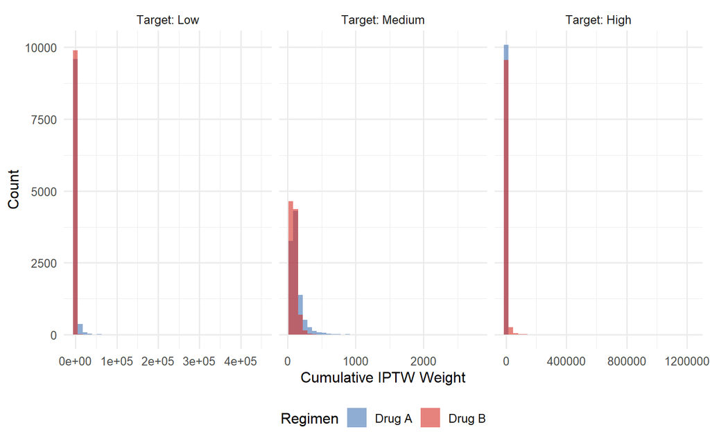

Figure 17: Distribution of cumulative IPTW weights for static adherence regimes, by drug and target adherence level. Larger, more dispersed weights indicate greater positivity strain.

```r
if (exists("dat") && !is.null(dat)) {
  # Re-use the cumulative weights computed above
  K <- 4
  weight_list <- list()

  for (a0 in 0:1) {
    drug_label <- ifelse(a0 == 1, "Drug A", "Drug B")
    sub <- dat[dat$A0 == a0, ]
    n_arm <- nrow(sub)

    for (z_target in 1:3) {
      z_label <- c("Low", "Medium", "High")[z_target]
      cum_w <- rep(1, n_arm)

      for (t in 1:K) {
        Z_col <- paste0("Z_", t)
        L_col <- paste0("L_", t)
        Z_prev <- if (t > 1) paste0("Z_", t - 1) else NULL

        covs <- c(L_col, Z_prev, "W_severity", "W_depression", "W_instability")
        covs <- covs[covs %in% names(sub)]
        fmla <- as.formula(paste0("factor(", Z_col, ") ~ ",
                                   paste(covs, collapse = " + ")))
        fit_g <- tryCatch(
          nnet::multinom(fmla, data = sub, trace = FALSE),
          error = function(e) NULL
        )
        if (is.null(fit_g)) next

        probs <- predict(fit_g, type = "probs")
        if (is.null(dim(probs))) {
          p_target <- ifelse(sub[[Z_col]] == z_target, probs, 1 - probs)
        } else {
          lvls <- colnames(probs)
          target_col <- which(lvls == as.character(z_target))
          if (length(target_col) == 0) {
            p_target <- rep(1e-4, n_arm)
          } else {
            p_target <- probs[, target_col]
          }
        }
        p_target <- pmax(p_target, 0.001)
        cum_w <- cum_w / p_target
      }

      weight_list[[paste0(drug_label, "_z", z_target)]] <- data.frame(
        Drug = drug_label,
        Adherence = z_label,
        weight = cum_w,
        stringsAsFactors = FALSE
      )
    }
  }

  weight_df <- do.call(rbind, weight_list)
  weight_df$Adherence <- factor(weight_df$Adherence,
                                 levels = c("Low", "Medium", "High"))

  ggplot(weight_df, aes(x = weight, fill = Drug)) +
    geom_histogram(bins = 40, alpha = 0.6, position = "identity") +
    facet_wrap(~ Adherence, scales = "free_x",
               labeller = labeller(Adherence = function(x) paste("Target:", x))) +
    scale_fill_manual(values = c("Drug A" = "#4575B4", "Drug B" = "#D73027")) +
    labs(x = "Cumulative IPTW Weight",
         y = "Count",
         fill = "Regimen") +
    theme_minimal(base_size = 12) +
    theme(legend.position = "bottom")
}
```

## 13.7 Marginal Structural Model Summary

### What the MSM does and does not do

The primary causal results in this tutorial are the six regime-specific counterfactual risks estimated by LTMLE (2 drugs $\times$ 3 adherence levels). Those point estimates and their contrasts define the forgiveness curve directly, they are the main output. The MSM does not replace them.

A **marginal structural model** (MSM) in this context is simply a compact summary model fitted *to those estimated causal risks*. In analogy to ordinary regression, we have six estimated data points (one risk per drug-adherence combination), and fit a logistic regression through them to compress the curve into a few interpretable coefficients. The MSM summarises:

- the overall adherence-risk gradient (how much does failure risk change per unit of adherence?),
- the overall difference between regimens (is one drug riskier on average?),
- whether the adherence-risk slope differs by regimen (is one drug more forgiving than the other?).

The MSM coefficients are **projection parameters**, they summarise the shape of the estimated causal curve, but they are not themselves direct causal effects. If the true curve is nonlinear, the logistic-linear summary will be approximate. The MSM is useful for communication, for comparing forgiveness patterns across studies or simulation scenarios, and for formal hypothesis testing: a Wald test of $H_0\!: \beta_3 = 0$ provides a single-degree-of-freedom test of whether the adherence–risk slope differs by regimen, which is the statistical analogue of the question “is Drug A more forgiving than Drug B?” However, because the MSM remains a secondary working summary rather than the primary estimand, the full set of regime-specific risks remains the primary output.

### MSM specification

Following Rosenblum and Laan (2010) and Petersen et al. (2014), we fit a logistic working model to the LTMLE-estimated counterfactual risks:

$$\text{logit}\!\left[\Psi_{a_0,z}(P_0)\right] = \beta_0 + \beta_1 \cdot a_0 + \beta_2 \cdot z + \beta_3 \cdot (a_0 \times z)$$

where $a_0 \in \{0, 1\}$ is the drug indicator and $z \in \{1, 2, 3\}$ is the adherence level (treated as numeric).

Note that the MSM is a secondary working summary of estimates, not the primary estimand. The forgiveness curve is still best understood from the full set of regime-specific risk estimates and their contrasts. The MSM provides a compact parametric compression that is useful for communication and for testing whether the drug-by-adherence interaction is present, but it imposes a functional form (logistic, linear in $z$) that may not capture nonlinearities in the true curve. The coefficients are projection or summary parameters of the estimated causal curve, not direct causal effects by themselves.

```r
if (!is.null(ltmle_results)) {
  # Prepare pseudo-data from the 6 regime-specific LTMLE estimates
  msm_data <- ltmle_results
  msm_data$drug <- msm_data$a0          # 0 = Drug B, 1 = Drug A
  msm_data$z    <- msm_data$z_level     # 1, 2, 3

  # Weighted logistic regression on the point estimates
  # Weight by inverse variance (1/SE^2) to account for differential precision
  msm_data$w <- 1 / (msm_data$se^2)

  msm_fit <- glm(estimate ~ drug * z,
                  data = msm_data,
                  family = quasibinomial(link = "logit"),
                  weights = w)

  msm_coefs <- summary(msm_fit)$coefficients
  # Extract p-values: quasibinomial uses t-test ("Pr(>|t|)")
  p_col <- if ("Pr(>|t|)" %in% colnames(msm_coefs)) "Pr(>|t|)" else "Pr(>|z|)"
  pvals <- msm_coefs[, p_col]
  # Format p-values: show exact for p >= 0.001, otherwise "<0.001"
  fmt_p <- ifelse(pvals < 0.001, "<0.001", sprintf("%.3f", pvals))

  msm_table <- data.frame(
    Term = c("Intercept ($\\beta_0$)",
             "Drug A ($\\beta_1$)",
             "Adherence level ($\\beta_2$)",
             "Drug A $\\times$ Adherence ($\\beta_3$)"),
    Estimate = round(msm_coefs[, "Estimate"], 3),
    SE = round(msm_coefs[, "Std. Error"], 3),
    p = fmt_p,
    stringsAsFactors = FALSE
  )
  print(kable(msm_table, align = "lrrr", escape = FALSE,
              col.names = c("Parameter", "Estimate", "SE", "$p$-value")) |>
    kable_styling(bootstrap_options = c("striped", "condensed"),
                  full_width = FALSE))

  # Brief interpretation
  # β2 is negative (higher adherence → lower risk). A positive β3 means
  # Drug A's slope is less negative (flatter curve = more forgiving).
  b3 <- msm_coefs["drug:z", "Estimate"]
  cat(sprintf(
    "\n\nThe interaction term $\\hat{\\beta}_3 = %.3f$ %s. Because $\\hat{\\beta}_2$ is negative (higher adherence lowers risk), a %s $\\hat{\\beta}_3$ means Drug A's adherence--risk slope is %s than Drug B's on the log-odds scale, confirming the nonparametric finding that Drug A is more forgiving of suboptimal adherence.\n",
    b3,
    ifelse(b3 > 0, "is positive", "is negative"),
    ifelse(b3 > 0, "positive", "negative"),
    ifelse(b3 > 0, "less steep (flatter, more forgiving)", "steeper (less forgiving)")
  ))
}
```

Table 26: The interaction term $\hat{\beta}_3 = 0.228$ is positive. Because $\hat{\beta}_2$ is negative (higher adherence lowers risk), a positive $\hat{\beta}_3$ means Drug A’s adherence–risk slope is less steep (flatter, more forgiving) than Drug B’s on the log-odds scale, confirming the nonparametric finding that Drug A is more forgiving of suboptimal adherence.

|  | Parameter | Estimate | SE | $p$-value |
| --- | --- | --- | --- | --- |
| (Intercept) | Intercept ($\beta_0$) | 0.113 | 0.168 | 0.572 |
| drug | Drug A ($\beta_1$) | -1.154 | 0.254 | 0.045 |
| z | Adherence level ($\beta_2$) | -0.830 | 0.089 | 0.011 |
| drug:z | Drug A $\times$ Adherence ($\beta_3$) | 0.228 | 0.118 | 0.193 |

## 13.8 How to read the MSM table

The four coefficients in Table 26 summarise the forgiveness curve as follows. In this model, adherence $z$ is coded numerically (1 = low, 2 = medium, 3 = high) and Drug A is coded as 1 (Drug B = 0).

This MSM summary complements the nonparametric curve in Figure 2. The interaction coefficient provides a single-number summary of differential forgiveness that can be compared across simulation scenarios or studies. However, analysts should always inspect the full curve to check whether the linear-in-$z$ assumption is reasonable before relying on the MSM coefficients.

## 13.9 Illustrative injectable DGP

This appendix provides a toy data-generating process for long-acting injectable ART, illustrating how the causal framework from the main tutorial transfers to a setting where adherence is measured as injection delay rather than PDC. The DGP is deliberately simple and is not calibrated to any specific drug’s pharmacokinetics. Its purpose is conceptual: to show that the same node structure, identification strategy, and estimation methods apply when the treatment variable changes from categorical pill-taking to continuous injection timing.

### 13.9.1 Extension to long-acting injectable ART

#### 13.9.1.1 Reframing adherence for long-acting regimens

Forgiveness is not an intrinsic property of a drug molecule. It is a property of the treatment-adherence-monitoring system: the drug’s pharmacokinetics, the patient’s execution behaviour, and the clinical monitoring process that determines when failure is detected. When the treatment modality changes, the relevant adherence dimension changes with it, but the causal questions remain the same.

For daily oral ART, adherence is typically measured as the proportion of days covered (PDC) over fixed intervals. A patient with PDC = 0.70 had medication available on 70% of days. The forgiveness curve traces how failure risk changes as PDC declines from 1.0 toward 0. The primary analysis in this tutorial uses a three-level categorical version of this measure.

For long-acting injectable ART (e.g., cabotegravir/rilpivirine administered every two months), the adherence construct is fundamentally different. Patients do not take daily pills; instead, they attend scheduled clinic visits for intramuscular injections. The relevant adherence dimension is **injection timing**: how many days late a patient is relative to the scheduled injection date. A patient who arrives on time ($\text{delay} = 0$) has different pharmacokinetic exposure than one who arrives 21 days late, even though both received the injection. The depot formulation provides a pharmacokinetic buffer: drug concentrations remain therapeutic for some period beyond the scheduled date (the “grace window”), after which they decline and the risk of virologic failure increases.

The causal framework from this tutorial applies directly. Replace the time-varying treatment node $Z_t \in \{1, 2, 3\}$ (categorical adherence) with $D_t \geq 0$ (days late to scheduled injection at visit $t$). The time-varying confounder $L_t$ (health status, symptoms, care engagement) still creates feedback: sicker patients may miss appointments, and missed appointments increase the risk of failure, which worsens health. The same identification assumptions (consistency, sequential exchangeability, positivity) are required, and the same g-methods (LTMLE, LMTP) can be used to estimate the injectable forgiveness curve, which now traces failure risk as a function of injection delay rather than PDC.

#### 13.9.1.2 Illustrative injectable forgiveness curve

The shape of the forgiveness curve differs between oral and injectable regimens. For oral ART, the curve is roughly monotone: risk increases as PDC decreases. For injectables, the curve has a distinctive **threshold shape** driven by depot pharmacokinetics. Risk remains low and approximately flat while drug concentrations exceed the therapeutic threshold (the grace window), then rises steeply once concentrations fall below the effective level.

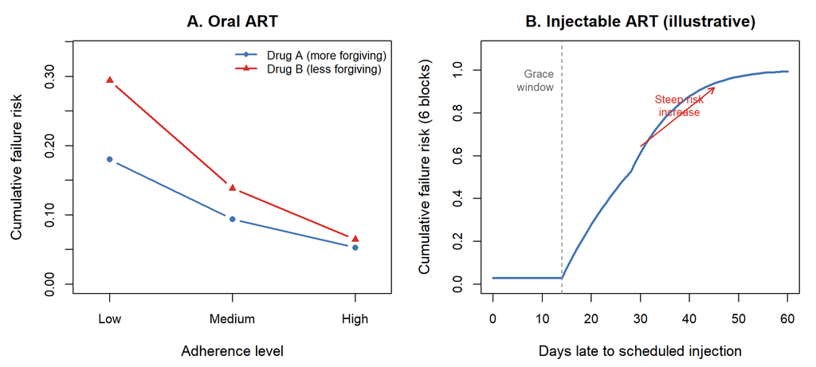

Figure 18: Illustrative forgiveness curves for oral versus injectable ART. Left: oral ART failure risk by adherence level (from the primary analysis DGP). Right: injectable ART failure risk by injection delay, showing a flat grace window followed by steep risk increase. The injectable curve is illustrative and not derived from the primary simulation.

```r
par(mfrow = c(1, 2), mar = c(4.5, 4.5, 2.5, 1), cex.lab = 1.1, cex.axis = 0.95)

# ── Panel A: Oral forgiveness curve (schematic from DGP parameters) ──────
# Use oracle truth if available, otherwise compute from DGP hazard model
if (exists("oracle_truth") && !is.null(oracle_truth)) {
  oral_A <- oracle_truth[oracle_truth$a0 == 1, ]
  oral_B <- oracle_truth[oracle_truth$a0 == 0, ]
  oral_A <- oral_A[order(as.numeric(oral_A$z_target)), ]
  oral_B <- oral_B[order(as.numeric(oral_B$z_target)), ]
  x_oral <- as.numeric(oral_A$z_target)
  y_A <- oral_A$cum_risk_oracle
  y_B <- oral_B$cum_risk_oracle
} else {
  x_oral <- 1:3
  y_A <- c(0.22, 0.08, 0.04)
  y_B <- c(0.35, 0.12, 0.05)
}

plot(x_oral, y_B, type = "b", pch = 17, col = "#D73027", lwd = 2,
     xlim = c(0.8, 3.2), ylim = c(0, max(y_B) * 1.15),
     xlab = "Adherence level", ylab = "Cumulative failure risk",
     main = "A. Oral ART", xaxt = "n")
axis(1, at = 1:3, labels = c("Low", "Medium", "High"))
lines(x_oral, y_A, type = "b", pch = 16, col = "#4575B4", lwd = 2)
legend("topright", legend = c("Drug A (more forgiving)", "Drug B (less forgiving)"),
       col = c("#4575B4", "#D73027"), pch = c(16, 17), lwd = 2, cex = 0.85, bty = "n")

# ── Panel B: Injectable forgiveness curve (illustrative) ─────────────────
days_late <- 0:60

# Piecewise hazard model for a depot injection with ~14-day grace window
# Per-block hazard as a function of delay
piecewise_risk <- function(d) {
  # Cumulative risk over K=6 bimonthly blocks with this delay pattern
  # Per-block hazard:
  #   0-14 days: low baseline (~0.005 per block)
  #   14-28 days: linear increase
  #   28+ days: steep increase
  h <- ifelse(d <= 14, 0.005,
         ifelse(d <= 28, 0.005 + 0.008 * (d - 14),
                0.005 + 0.008 * 14 + 0.015 * (d - 28)))
  # Cumulative risk over 6 blocks with constant delay
  1 - (1 - h)^6
}

risk_inj <- sapply(days_late, piecewise_risk)

plot(days_late, risk_inj, type = "l", lwd = 2.5, col = "#4575B4",
     xlab = "Days late to scheduled injection",
     ylab = "Cumulative failure risk (6 blocks)",
     main = "B. Injectable ART (illustrative)", ylim = c(0, max(risk_inj) * 1.1))

# Mark the grace window
abline(v = 14, lty = 2, col = "grey50")
text(14, max(risk_inj) * 0.95, "Grace\nwindow", pos = 2, cex = 0.8, col = "grey40")

# Mark the steep-rise zone
arrows(30, piecewise_risk(30) + 0.03, 45, piecewise_risk(45) - 0.02,
       length = 0.08, col = "#D73027", lwd = 1.5)
text(38, piecewise_risk(35) + 0.06, "Steep risk\nincrease", cex = 0.8, col = "#D73027")

par(mfrow = c(1, 1))
```

The contrast between the two panels highlights a key point: forgiveness curves are not always monotone or linear on the same scale. The oral curve declines steadily with adherence category, while the injectable curve is flat within the grace window and then rises sharply. This threshold behaviour has practical implications: for injectables, the clinical target is not “maximise PDC” but “keep injection delays within the grace window.” Modified treatment policies that reduce delays by a fixed number of days (e.g., $d(D_t) = \max(D_t - 7, 0)$) are well-suited to this setting because they target the tail of the delay distribution where risk accumulates.

#### 13.9.1.3 Mapping intervention classes to the injectable setting

The four classes of causal interventions introduced in this tutorial each have natural analogues for long-acting injectables:

| Intervention class | Oral ART example | Injectable ART example |
| --- | --- | --- |
| **Static regime** | Set PDC to high at every block | All injections on time ($D_t = 0$) |
| **Dynamic regime** | Pharmacy counselling after low PDC block | Outreach visit after missed injection; rescue injection if $D_t > 14$ |
| **Stochastic regime** | Randomise to adherence-support programme | Randomise to visit-reminder SMS system |
| **Modified treatment policy** | Shift PDC up by 10%: $d(Z_t) = \min(Z_t + 0.10, 1)$ | Reduce delay by 7 days: $d(D_t) = \max(D_t - 7, 0)$ |

Static regimes for injectables (e.g., “always on time”) face the same positivity problems as static regimes for oral ART: few patients maintain perfect timing across all visits, so estimates rely heavily on modelling assumptions. Dynamic regimes are more realistic but require specifying a clinical decision rule, which may be hard to define precisely in observational data.

Modified treatment policies are often the most practical choice for injectable adherence. The shift $d(D_t) = \max(D_t - \delta, 0)$ reduces each patient’s observed delay by $\delta$ days (floored at zero), which corresponds to a feasible intervention such as proactive appointment reminders, transport assistance, or flexible scheduling that brings each visit closer to its target date. Because the intervention perturbs observed behaviour rather than replacing it, positivity is satisfied whenever the shifted delay falls within the support of the observed delay distribution, which is a much weaker requirement than the positivity needed for a static “always on time” regime. A toy DGP illustrating this injectable setting is provided in Section 13.9.

### 13.9.2 Setup

Consider a cohort of patients receiving bimonthly injections over $K = 6$ visits (one year of follow-up). At each visit $t$:

- $L_t$: time-varying health status (continuous), depending on prior health and prior injection delay
- $D_t$: days late to the scheduled injection ($D_t \geq 0$; on time = 0)
- $Y_t$: virologic failure (binary, absorbing)

The causal ordering is $L_t \to D_t \to Y_t$, mirroring the oral-ART structure $L_t \to Z_t \to Y_t$. Treatment-confounder feedback arises because poor health increases the probability of delayed visits, and delayed visits increase the risk of failure, which further worsens health.

**Toy injectable DGP: simulate one dataset**

```r
set.seed(2026)
n_inj <- 2000
K_inj <- 6

# Baseline
W_age_inj   <- rnorm(n_inj)
W_rural_inj <- rbinom(n_inj, 1, 0.35)  # rural residence (harder clinic access)

df_inj <- data.frame(W_age = round(W_age_inj, 3), W_rural = W_rural_inj)

prev_L_inj   <- rnorm(n_inj, 0, 0.5)
prev_D_inj   <- rep(0, n_inj)
failed_inj   <- rep(FALSE, n_inj)

for (tt in seq_len(K_inj)) {
  # L_t: health status (higher = healthier)
  L_t <- 0.6 * prev_L_inj - 0.01 * prev_D_inj + rnorm(n_inj, 0, 0.7)
  L_t[failed_inj] <- NA_real_

  # D_t: days late to scheduled injection
  # Sicker patients and rural patients have longer delays
  rate_param <- exp(-1.5 - 0.4 * ifelse(is.na(L_t), 0, L_t) +
                      0.5 * W_rural_inj + 0.3 * (prev_D_inj > 14))
  D_t <- rexp(n_inj, rate = 1 / pmax(rate_param, 0.5))
  D_t <- round(pmin(D_t, 90), 1)  # cap at 90 days
  D_t[failed_inj] <- NA_real_

  # Y_t: virologic failure with piecewise hazard
  # Grace window: 0-14 days (low risk)
  # Transition zone: 14-28 days (rising risk)
  # High-risk zone: 28+ days (steep increase)
  delay_penalty <- ifelse(is.na(D_t), 0,
    ifelse(D_t <= 14, 0,
      ifelse(D_t <= 28, 0.06 * (D_t - 14),
             0.06 * 14 + 0.12 * (D_t - 28))))

  logit_Y_inj <- -4.5 + delay_penalty -
    0.3 * ifelse(is.na(L_t), 0, L_t) +
    0.2 * W_rural_inj - 0.05 * W_age_inj

  p_Y_inj <- plogis(logit_Y_inj)
  Y_t_inj <- rbinom(n_inj, 1, p_Y_inj)
  Y_t_inj[failed_inj] <- 1L
  Y_t_inj[is.na(D_t)] <- NA_integer_

  df_inj[[paste0("L_", tt)]] <- round(L_t, 4)
  df_inj[[paste0("D_", tt)]] <- D_t
  df_inj[[paste0("Y_", tt)]] <- Y_t_inj

  newly_failed <- !failed_inj & !is.na(Y_t_inj) & Y_t_inj == 1
  failed_inj <- failed_inj | newly_failed
  prev_L_inj <- ifelse(is.na(L_t), prev_L_inj, L_t)
  prev_D_inj <- ifelse(is.na(D_t), prev_D_inj, D_t)
}

# Summary
delay_cats <- cut(df_inj$D_1, breaks = c(-1, 0.5, 14, 28, 91),
                  labels = c("On time", "1-14 days", "15-28 days", ">28 days"))
cum_fail <- df_inj[[paste0("Y_", K_inj)]]
cat("Injectable DGP: n =", n_inj, "| K =", K_inj, "visits\n")
```

```
Injectable DGP: n = 2000 | K = 6 visits
```

**Toy injectable DGP: simulate one dataset**

```r
cat("Overall cumulative failure:", round(mean(cum_fail == 1, na.rm = TRUE), 3), "\n\n")
```

```
Overall cumulative failure: 0.007
```

```r
inj_summary <- data.frame(
  `Delay category` = c("On time (0 days)", "1–14 days late", "15–28 days late", ">28 days late"),
  N = as.integer(table(delay_cats)),
  `Mean delay` = tapply(df_inj$D_1, delay_cats, function(x) round(mean(x), 1)),
  `Block 1 failure rate` = tapply(df_inj$Y_1, delay_cats,
                                   function(x) round(mean(x, na.rm = TRUE), 4)),
  check.names = FALSE
)
kable(inj_summary, align = "lrrr") |>
  kable_styling(bootstrap_options = c("striped", "condensed"), full_width = FALSE)
```

Table 27: Summary of the illustrative injectable DGP: delay distribution and failure rate at visit 1.

|  | Delay category | N | Mean delay | Block 1 failure rate |
| --- | --- | --- | --- | --- |
| On time | On time (0 days) | 1282 | 0.2 | 0.0140 |
| 1-14 days | 1–14 days late | 718 | 1.1 | 0.0111 |
| 15-28 days | 15–28 days late | 0 | NA | NA |
| >28 days | >28 days late | 0 | NA | NA |

### 13.9.3 Posing estimands in the injectable setting

The same four intervention classes apply to this DGP:

1. **Static regime**: “Set $D_t = 0$ for all $t$” (all injections on time). This targets the counterfactual risk under perfect timing. Like the “all high adherence” regime in the oral example, this regime has thin support because few patients maintain $D_t = 0$ at every visit.
2. **Dynamic regime**: “If $D_{t-1} > 14$, schedule an outreach visit to ensure $D_t \leq 7$; otherwise, no intervention.” This is a history-dependent rule that intensifies support after a missed grace window, analogous to pharmacy counselling triggered by a low-PDC block in the oral setting.
3. **Stochastic regime**: “Randomise each patient to receive (or not) an SMS reminder system that reduces the probability of long delays.” This defines a probabilistic intervention on visit completion, not a deterministic one.
4. **Modified treatment policy**: $d(D_t) = \max(D_t - 7, 0)$, reducing each patient’s observed delay by 7 days (floored at zero). This is the injectable analogue of the oral LMTP shift $d(Z_t) = \min(Z_t + 1, 3)$. It perturbs observed behaviour rather than replacing it, and the positivity requirement is satisfied whenever the shifted delay lies within the observed delay distribution — a much weaker condition than requiring $D_t = 0$ for all patients.

For estimation, LMTP with a continuous treatment node ($D_t$) is the natural choice. The shift function $d(D_t) = \max(D_t - \delta, 0)$ can be implemented directly using `lmtp_tmle()` with `mtp = TRUE`, exactly as in the continuous PDC analysis in Section 6.5. LTMLE with binary dummies (as in the primary oral analysis) would require categorising delay into discrete levels, which is possible but discards information and introduces bin-boundary sensitivity.

Note that this DGP is a pedagogic illustration. It is not calibrated to published pharmacokinetic data for any specific injectable product. For a more complete analysis of injectable versus oral ART forgiveness using a delivery-system DGP informed by the qualitative shape and scale of published trial data, see Section 8 for a worked example.

### A note on code and reproducibility

This document serves as both a methods tutorial and an implementation guide. The oral-ART DGP and estimators are defined in `R/sim_oral_forgiveness_helpers.R`, shared with the separate Monte Carlo study in `scripts/run_monte_carlo_oral_forgiveness.R`. Rendered results use inline computation or cached outputs. Key estimation steps are also presented as commented `eval: false` teaching chunks that analysts can adapt to their own data.